# High_fat_analysis

Lyanna Kessler

2023-09-22

# Packages

## installs from github/biocmanager

```r
#remotes::install_github("pmartinezarbizu/pairwiseAdonis/pairwiseAdonis", force = T)

#remotes::install_github("phytomosaic/ecole")

#BiocManager::install("philr")
#BiocManager::install("ggtree")

# Because of an "SSL error," used different repo/mirror
#install.packages('phangorn', repos='http://cran.us.r-project.org')
```

## Function: give_nickname()

```r
give_nickname <- function(names,
                          one_name = TRUE,
                          phylum = FALSE,
                          family = FALSE,
                          genus = FALSE) {
  # "names" must be a chr list of long names from the SILVA database
  # This function takes long taxa names from SILVA and creates a nickname for them
  # Example long name:
  # d__Bacteria; p__Bacteroidota; c__Bacteroidia; o__Bacteroidales; f__Bacteroidaceae; g__Bacteroides; s__Bacteroides_vulgatus
  # Example (one_name) nickname:
  # Bacteroides_vulgates
  # Example two-name nickname:
  # Bacteroides, Bacteroides_vulgatis

  taxa_clean <- names
  long <- length(names)

  for (i in 1:long){
    s <- str_extract(names[i], "s__\\w+")
    s <- ifelse(is.na(s) == FALSE & str_detect(s, "uncultured|unidentified|metagenome|human_gut") == FALSE,
                sub('...','',s),
                s <- NA)

    g <- str_extract(names[i], "g__\\w+")
    g <- ifelse(is.na(g) == FALSE & str_detect(g, "uncultured|unidentified|metagenome|human_gut") == FALSE,
                sub('...','',g),
                g <- NA)

    f <- str_extract(names[i], "f__\\w+")
    f <- ifelse(is.na(f) == FALSE & str_detect(f, "uncultured|unidentified|metagenome|human_gut") == FALSE,
                sub('...','',f),
                f <- NA)

    o <- str_extract(names[i], "o__\\w+")
    o <- ifelse(is.na(o) == FALSE & str_detect(o, "uncultured|unidentified|metagenome|human_gut") == FALSE,
                sub('...','',o),
                o <- NA)

    c <- str_extract(names[i], "c__\\w+")
    c <- ifelse(is.na(c) == FALSE & str_detect(c, "uncultured|unidentified|metagenome|human_gut") == FALSE,
                sub('...','',c),
                c <- NA)

    p <- str_extract(names[i], "p__\\w+")
    p <- ifelse(is.na(p) == FALSE & str_detect(p, "uncultured|unidentified|metagenome|human_gut") == FALSE,
                sub('...','',p),
                p <- NA)

    ifelse(is.na(s) == FALSE,
           name1 <- s,
      ifelse(is.na(g) == FALSE,
           name1 <- paste(g, "_genus", sep = ""),
           ifelse(is.na(f) == FALSE,
                  name1 <- paste(f, "_family", sep = ""),
                  ifelse(is.na(o) == FALSE,
                         name1 <- paste(o, "_order", sep = ""),
                         ifelse(is.na(c) == FALSE,
                                name1 <- paste(c, "_class", sep = ""),
                                ifelse(is.na(p) == FALSE,
                                       name1 <- paste(p, "_phylum", sep = ""),
                                       name1 <- "Unknown"))))))



    ifelse(is.na(g) == FALSE & name1 != paste(g, "_genus", sep = ""),
           name2 <- g,
      ifelse(is.na(f) == FALSE & name1 != paste(f, "_family", sep = ""),
           name2 <- paste(f, "_family", sep = ""),
           ifelse(is.na(o) == FALSE & name1 != paste(o, "_order", sep = ""),
                  name2 <- paste(o, "_order", sep = ""),
                  ifelse(is.na(c) == FALSE & name1 != paste(c, "_class", sep = ""),
                         name2 <- paste(c, "_class", sep = ""),
                         ifelse(is.na(p)==FALSE & name1 != paste(p, "_phylum", sep = ""),
                                name2 <- paste(p, "_phylum", sep = ""),
                                name2 <- NA)))))

    ifelse(one_name == TRUE,
           taxa_clean[i] <- name1,
           taxa_clean[i] <- ifelse(is.na(name2)==FALSE,
                                   paste(name2, name1, sep = ", "),
                                   name1))
    if(phylum == TRUE){
           taxa_clean[i] <- p
    }
    if(family == TRUE){
           taxa_clean[i] <- f
    }
    if(genus == TRUE){
           taxa_clean[i] <- g
    }
  }
  return(taxa_clean)

}
```

## Luke’s Hex Codes

M.v/CD = FCB5AF M.v/WD = A73325 BBS/CD = ADD4ED BBS/WD = 016796

# Export non-rarefied table

```r
table <- read_qza("data/hf_table.qza")$data

# get names
taxonomy <- read_qza("data/taxonomy-silva.qza")$data
asvs <- rownames(table)
taxa <- vector(length=length(asvs))

i <- 1
for (a in asvs){
    taxa[i] <- taxonomy[taxonomy$Feature.ID==a,"Taxon"]
    i <- i + 1
}

taxa_clean <- give_nickname(taxa, one_name = TRUE)
taxa_phylum <- give_nickname(taxa, one_name = TRUE, phylum = TRUE)
#rarefied_table_tax <- rarefied_table
#rownames(rarefied_table_tax) <- taxa_clean
#rownames(metadata) <- metadata$SampleID

t.table <- t(table)
rs <- rowSums(t.table)
df <- as.data.frame(rs)
df <- df %>%
  rename("otus" = "rs")

# write.csv(df, "data/hf_otus.csv", row.names=TRUE)
```

# Get Firmicutes:Bacteriodes ratio

```r
table_phy <- table
sums <- rowSums(table_phy)
table_phy <- as.data.frame(table_phy)
table_phy$phylum <- taxa_phylum
table_phy$sums <- sums
tp_firm <- filter(table_phy, phylum == "Firmicutes")
tp_bac <- filter(table_phy, phylum == "Bacteroidota")

tp_firm <- sapply(tp_firm, as.numeric)
tp_firm <- t(tp_firm)
f_sums <- rowSums(tp_firm)
tp_firm <- as.data.frame(tp_firm)
tp_firm$firm_sums <- f_sums
df_firm <- select(tp_firm, firm_sums)
df_firm$ID <- row.names(df_firm)


tp_bac <- sapply(tp_bac, as.numeric)
tp_bac <- t(tp_bac)
b_sums <- rowSums(tp_bac)
tp_bac <- as.data.frame(tp_bac)
tp_bac$bac_sums <- b_sums
df_bac <- select(tp_bac, bac_sums)

df_ratio <- cbind(df_firm, df_bac)
df_ratio$firm_bac_ratio <- df_ratio$firm_sums / df_ratio$bac_sums
df_ratio <- filter(df_ratio, ID != "phylum" & ID != "sums")



# write.csv(df_ratio, "data/hf_ratios.csv", row.names=FALSE)
```

# Categorize weights

```r
df <- read_csv("data/hf_meta_weights.csv")
df$Weight <- as.numeric(df$Weight)
sd_w <- sd(df$Weight, na.rm=T)
r_w <- range(df$Weight, na.rm=T)
rw_length <- r_w[2] - r_w[1]
steps <- rw_length/3
q1 <- r_w[1] + steps
q2 <- r_w[2] - steps

df$Weight_group <- ifelse(df$Weight < q1,
                          df$Weight_group <- "Low",
                          ifelse(df$Weight < q2,
                                 df$Weight_group <- "Medium",
                                 "High"))

# write.csv(df, "data/hf_meta_weights.csv", row.names=FALSE)
```

# Alpha diversity

```r
# "signif" files made in qiime visualizer
# download from viewing group significance qzvs
# then downloaded raw data as tsvs
shan <- read_q2metadata("cd_new_results/shannon_hf_signif.tsv")
faith <- read_q2metadata("cd_new_results/faith_hf_signif.tsv")
even <- read_q2metadata("cd_new_results/evenness_hf_signif.tsv")

alpha_table <- shan
names(alpha_table)[names(alpha_table) == "shannon_entropy"] <- "Shannon"
alpha_table$Faith <- faith$faith_pd
alpha_table$Evenness <- even$pielou_evenness

# write.csv(alpha_table, "alpha_scores.csv", row.names=FALSE)


# analysis
kruskal.test(Shannon ~ Diet, data = alpha_table)
```

```
##
##  Kruskal-Wallis rank sum test
##
## data:  Shannon by Diet
## Kruskal-Wallis chi-squared = 13.312, df = 1, p-value = 0.0002637
```

```r
kruskal.test(Faith ~ Diet, data = alpha_table)
```

```
##
##  Kruskal-Wallis rank sum test
##
## data:  Faith by Diet
## Kruskal-Wallis chi-squared = 50.203, df = 1, p-value = 1.386e-12
```

```r
kruskal.test(Evenness ~ Diet, data = alpha_table)
```

```
##
##  Kruskal-Wallis rank sum test
##
## data:  Evenness by Diet
## Kruskal-Wallis chi-squared = 41.863, df = 1, p-value = 9.788e-11
```

```r
kruskal.test(Shannon ~ Treatment, data = alpha_table)
```

```
##
##  Kruskal-Wallis rank sum test
##
## data:  Shannon by Treatment
## Kruskal-Wallis chi-squared = 4.1445, df = 1, p-value = 0.04177
```

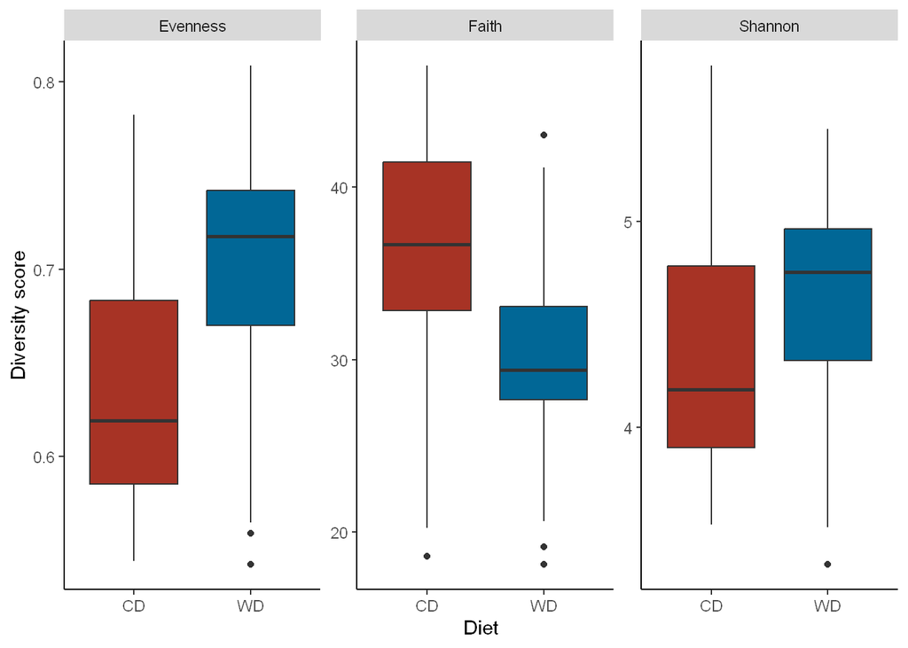

```r
# kruskal.test(Faith ~ Treatment, data = alpha_table)
# kruskal.test(Evenness ~ Treatment, data = alpha_table)

alpha_long <- pivot_longer(alpha_table,
                            cols = c("Shannon", "Faith", "Evenness"),
                            names_to = "Metric",
                            values_to = "Alpha_score")

alpha_plot <- ggplot(data = alpha_long, aes(x = Diet, y = Alpha_score, fill = Diet)) +
  geom_boxplot() +
  theme(panel.grid.major = element_blank(),
        panel.grid.minor = element_blank(),
        panel.background = element_blank(),
        axis.line = element_line(colour = "black"),
        legend.position = "none") +
  scale_fill_manual(values=c("#A73325", "#016796")) +
  labs(x = "Diet",
       y = "Diversity score") +
  facet_wrap(~ Metric, scales = "free")
alpha_plot
```

## Richness

```r
SVs <- read_qza("data/hf_weights_table.qza")$data
SVs <- t(SVs)
list <- rowSums(SVs)
list <- t(t(list))
df_svs <- as.data.frame(SVs)
df_svs$counts <- list

df_svs <- select(df_svs, counts)

rare <- read_qza("cd_new_results/rarefied_table.qza")$data
rare <- t(rare)
list <- rowSums(rare)
list <- t(t(list))
r_df <- as.data.frame(rare)
r_counts <- r_df
r_counts$counts <- list

r_counts <- select(r_counts, counts)
#write.csv(r_df, "rarefied_richness.csv", row.names=TRUE)

# number of species per sample
r_bi <- apply(r_df, 2, function(x) ifelse(x != 0, 1, x))
list <- rowSums(r_bi)
list <- t(t(list))
r_counts <- r_bi
r_counts <- as.data.frame(r_counts)
r_counts$counts <- list

#hist(r_counts)

r_counts <- dplyr::select(r_counts, counts)
#write.csv(r_counts, "rarefied_richness.csv", row.names=TRUE)
```

# Beta diversity

## PCoA: Weighted UniFrac

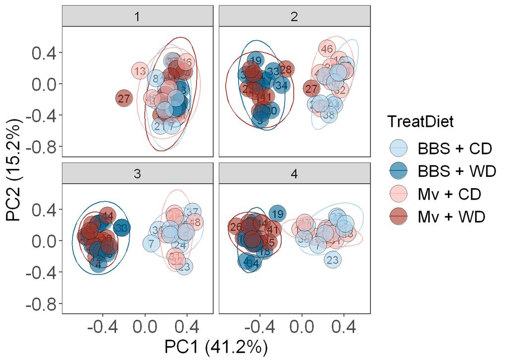

```r
metadata <- read_q2metadata("data/hf_meta_weights.tsv")
rownames(metadata) <- metadata$SampleID

pcoa_w_uni <- read_qza("cd_new_results/weighted_unifrac_pcoa_results.qza")$data

# PCoA plot with weighted UniFrac
pcoa_w_uni_plotdata <- pcoa_w_uni$Vectors
rownames(metadata) <- metadata$SampleID
rownames(pcoa_w_uni_plotdata) <- pcoa_w_uni_plotdata$SampleID
pcoa_w_uni_plotdata <- merge(pcoa_w_uni_plotdata, metadata)

w_unipcoa <- select(pcoa_w_uni_plotdata, PC1, PC2)
w_unipcoa <- data.matrix(w_unipcoa)
rownames(w_unipcoa) <- pcoa_w_uni_plotdata$SampleID


ggplot(data=pcoa_w_uni_plotdata,
       mapping=aes(x=PC1,
                   y=PC2,
                   label=Mouse)) +
  geom_text(aes(group = TreatDiet), color = "black") +
  stat_ellipse(aes(color = TreatDiet), level =.95) +
  geom_point(aes(fill = TreatDiet), alpha = .6, size=8, pch = 21) +
  scale_fill_manual(values=c("Mv + CD" = "#FCB5AF",
                             "BBS + CD" = "#ADD4ED",
                             "Mv + WD" = "#A73325",
                             "BBS + WD" = "#016796")) +
  scale_color_manual(values=c("Mv + CD" = "#FCB5AF",
                             "BBS + CD" = "#ADD4ED",
                             "Mv + WD" = "#A73325",
                             "BBS + WD" = "#016796")) +
  xlab(paste0("PC1 (", round(pcoa_w_uni$ProportionExplained[1]*100, 1), "%)")) +
  ylab(paste0("PC2 (", round(pcoa_w_uni$ProportionExplained[2]*100, 1), "%)")) +
  theme_bw() +
  theme(text = element_text(size=16),
          legend.text=element_text(size=16),
          axis.text.x = element_text(size = 18),
          axis.text.y = element_text(size = 18),
          axis.title = element_text(size = 18),
          panel.grid.major = element_blank(),
          panel.grid.minor = element_blank()) +
  facet_wrap(~Timepoint)
```

```r
#ggsave("PCOA_paneled_time.png", width = 11, height = 8, units = "in")
```

#### PCoA: Biplots/Timepoints

Separate PCoA graphs for each timepoint

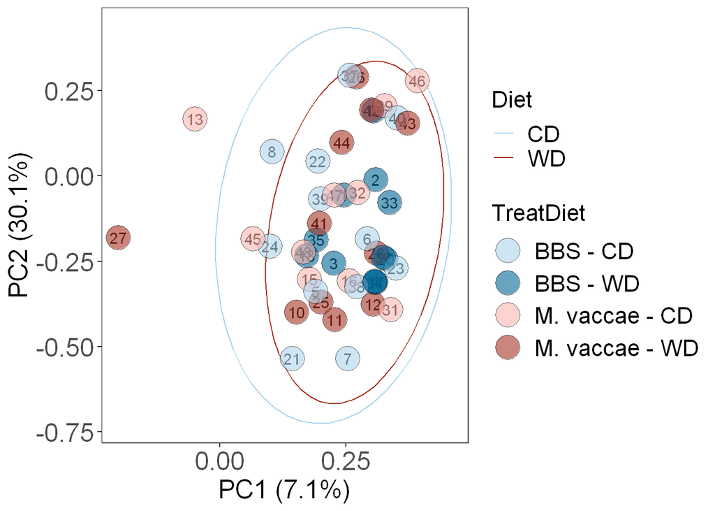

```r
metadata <- read_q2metadata("data/hf_meta_weights.tsv")
rownames(metadata) <- metadata$SampleID
metadata$TreatDiet <- paste(metadata$Treatment, metadata$Diet, sep = " - ")
metadata$TreatDiet <- as.factor(metadata$TreatDiet)

pcoa_w_uni <- read_qza("cd_new_results/weighted_unifrac_pcoa_results.qza")$data

# PCoA plot with weighted UniFrac
pcoa_w_uni_plotdata <- pcoa_w_uni$Vectors
rownames(metadata) <- metadata$SampleID
rownames(pcoa_w_uni_plotdata) <- pcoa_w_uni_plotdata$SampleID
pcoa_w_uni_plotdata <- merge(pcoa_w_uni_plotdata, metadata)

w_unipcoa <- select(pcoa_w_uni_plotdata, PC1, PC2)
w_unipcoa <- data.matrix(w_unipcoa)
rownames(w_unipcoa) <- pcoa_w_uni_plotdata$SampleID

pcoa_t1 <- filter(pcoa_w_uni_plotdata, Timepoint == "1")
pcoa_t2 <- filter(pcoa_w_uni_plotdata, Timepoint == "2")
pcoa_t3 <- filter(pcoa_w_uni_plotdata, Timepoint == "3")
pcoa_t4 <- filter(pcoa_w_uni_plotdata, Timepoint == "4")


p1_mat <- dplyr::select(pcoa_t1, 2:181)
p1_var <- apply(p1_mat,2, var)
p1_var <- round(p1_var / sum(p1_var) * 100, 1)

ggplot(data=pcoa_t1,
            mapping=aes(x=PC1,
                        y=PC2,
                        label=Mouse)) +
    geom_text(aes(group = TreatDiet), color = "black") +
    stat_ellipse(aes(color = Diet), level =.95) +
    geom_point(aes(fill = TreatDiet), alpha = .6, size=8, pch = 21) +
    scale_fill_manual(values=c("M. vaccae - CD" = "#FCB5AF",
                                "BBS - CD" = "#ADD4ED",
                                "M. vaccae - WD" = "#A73325",
                                "BBS - WD" = "#016796")) +
    scale_color_manual(values=c("WD" = "#A73325",
                              "CD" = "#ADD4ED")) +
    theme_bw() +
    #scale_color_discrete(name="") +
    xlab(paste0("PC1 (", p1_var[1], "%)")) +
    ylab(paste0("PC2 (", p1_var[2], "%)")) +
    theme(text = element_text(size=16),
          legend.text=element_text(size=16),
          axis.text.x = element_text(size = 18),
          axis.text.y = element_text(size = 18),
          axis.title = element_text(size = 18),
          panel.grid.major = element_blank(),
          panel.grid.minor = element_blank())
```

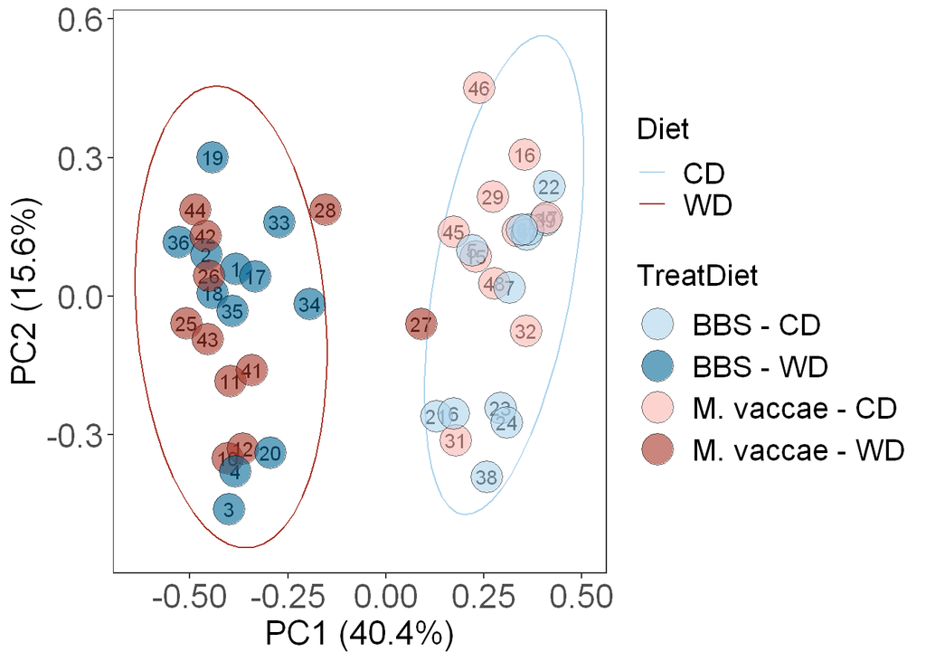

```r
#ggsave("figures/PCOA_T1.png", width = 11, height = 8, units = "in")

p2_mat <- dplyr::select(pcoa_t2, 2:181)
p2_var <- apply(p2_mat,2,var)
p2_var <- round(p2_var / sum(p2_var) * 100, 1)

ggplot(data=pcoa_t2,
            mapping=aes(x=PC1,
                        y=PC2,
                        label=Mouse)) +
    geom_text(aes(group = TreatDiet), color = "black") +
    stat_ellipse(aes(color = Diet), level =.95) +
    geom_point(aes(fill = TreatDiet), alpha = .6, size=8, pch = 21) +
    scale_fill_manual(values=c("M. vaccae - CD" = "#FCB5AF",
                                "BBS - CD" = "#ADD4ED",
                                "M. vaccae - WD" = "#A73325",
                                "BBS - WD" = "#016796")) +
    scale_color_manual(values=c("WD" = "#A73325",
                              "CD" = "#ADD4ED")) +
    theme_bw() +
    #scale_color_discrete(name="") +
    xlab(paste0("PC1 (", p2_var[1], "%)")) +
    ylab(paste0("PC2 (", p2_var[2], "%)")) +
    theme(text = element_text(size=16),
          legend.text=element_text(size=16),
          axis.text.x = element_text(size = 18),
          axis.text.y = element_text(size = 18),
          axis.title = element_text(size = 18),
          panel.grid.major = element_blank(),
          panel.grid.minor = element_blank())
```

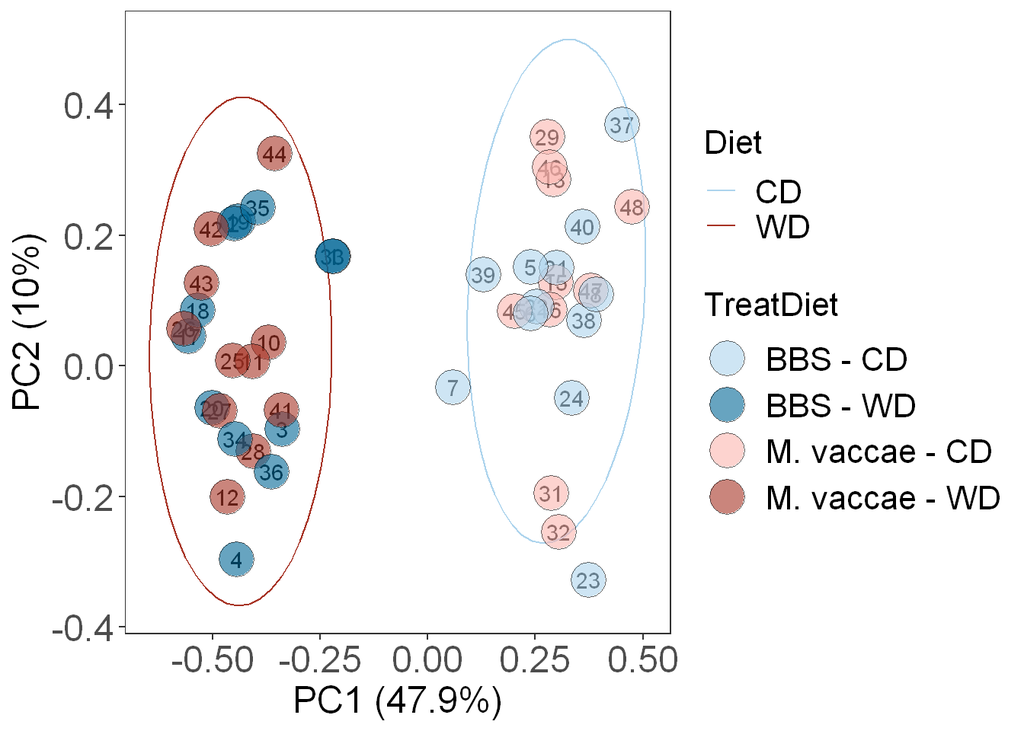

```r
#ggsave("figures/PCOA_T2.png", width = 11, height = 8, units = "in")


p3_mat <- dplyr::select(pcoa_t3, 2:181)
p3_var <- apply(p3_mat,2,var)
p3_var <- round(p3_var / sum(p3_var) * 100, 1)

ggplot(data=pcoa_t3,
            mapping=aes(x=PC1,
                        y=PC2,
                        label=Mouse)) +
    geom_text(aes(group = TreatDiet), color = "black") +
    stat_ellipse(aes(color = Diet), level =.95) +
    geom_point(aes(fill = TreatDiet), alpha = .6, size=8, pch = 21) +
    scale_fill_manual(values=c("M. vaccae - CD" = "#FCB5AF",
                                "BBS - CD" = "#ADD4ED",
                                "M. vaccae - WD" = "#A73325",
                                "BBS - WD" = "#016796")) +
    scale_color_manual(values=c("WD" = "#A73325",
                              "CD" = "#ADD4ED")) +
    theme_bw() +
    #scale_color_discrete(name="") +
    xlab(paste0("PC1 (", p3_var[1], "%)")) +
    ylab(paste0("PC2 (", p3_var[2], "%)")) +
    theme(text = element_text(size=16),
          legend.text=element_text(size=16),
          axis.text.x = element_text(size = 18),
          axis.text.y = element_text(size = 18),
          axis.title = element_text(size = 18),
          panel.grid.major = element_blank(),
          panel.grid.minor = element_blank())
```

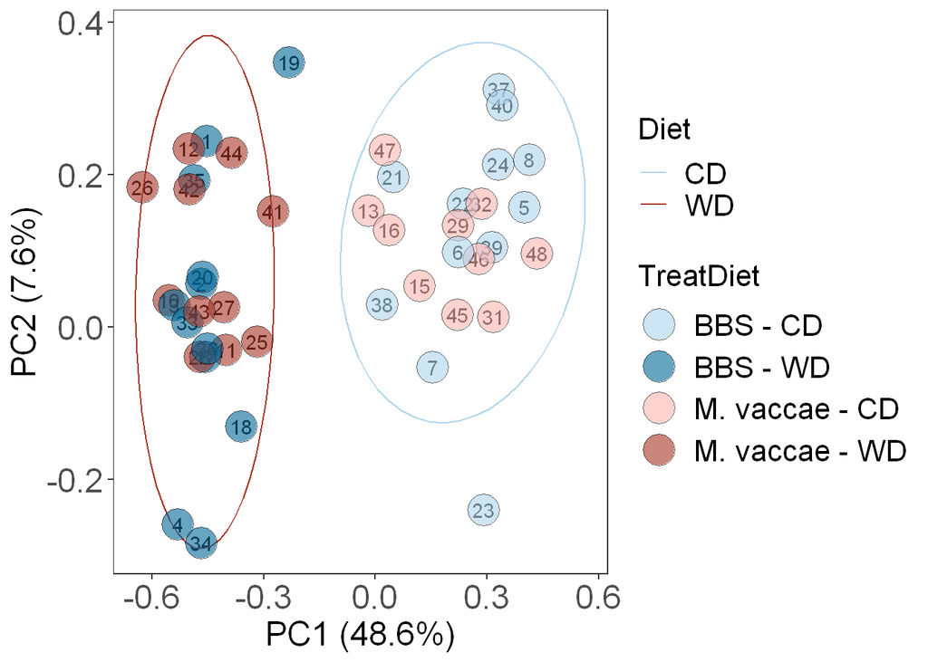

```r
#ggsave("figures/PCOA_T3.png", width = 11, height = 8, units = "in")


p4_mat <- dplyr::select(pcoa_t4, 2:181)
p4_var <- apply(p4_mat,2,var)
p4_var <- round(p4_var / sum(p4_var) * 100, 1)

ggplot(data=pcoa_t4,
            mapping=aes(x=PC1,
                        y=PC2,
                        label=Mouse)) +
    geom_text(aes(group = TreatDiet), color = "black") +
    stat_ellipse(aes(color = Diet), level =.95) +
    geom_point(aes(fill = TreatDiet), alpha = .6, size=8, pch = 21) +
    scale_fill_manual(values=c("M. vaccae - CD" = "#FCB5AF",
                                "BBS - CD" = "#ADD4ED",
                                "M. vaccae - WD" = "#A73325",
                                "BBS - WD" = "#016796")) +
    scale_color_manual(values=c("WD" = "#A73325",
                              "CD" = "#ADD4ED")) +
    theme_bw() +
    #scale_color_discrete(name="") +
    xlab(paste0("PC1 (", p4_var[1], "%)")) +
    ylab(paste0("PC2 (", p4_var[2], "%)")) +
    theme(text = element_text(size=16),
          legend.text=element_text(size=16),
          axis.text.x = element_text(size = 18),
          axis.text.y = element_text(size = 18),
          axis.title = element_text(size = 18),
          panel.grid.major = element_blank(),
          panel.grid.minor = element_blank())
```

```r
#ggsave("figures/PCOA_T4.png", width = 11, height = 8, units = "in")
```

# Differential Expression

## ANCOM-BC2

Ancom with Bias Correction (BC). From John Sterrett

### ASV level

```r
metadata <- read_q2metadata("data/hf_meta_weights.tsv")
rownames(metadata) <- metadata$SampleID
metadata$Timepoint <- as.numeric(metadata$Timepoint)
metadata$Treatment <- fct_recode(metadata$Treatment,
                                 "Mv" = "M. vaccae",
                                 "BBS" = "BBS")

new_col <- rep(NA, nrow(metadata))

for (row in 1:nrow(metadata)){
    new_col[row] <- paste(metadata[row, 7], metadata[row, 8], sep="_")
}
metadata$Treat_Diet <- new_col
metadata$Treat_Diet <- as.factor(metadata$Treat_Diet)

new_col2 <- rep(NA, nrow(metadata))
for (row in 1:nrow(metadata)){
    new_col2[row] <- paste(metadata[row, 7], metadata[row, 10], sep="_")
}
metadata$Treat_Weight <- new_col2
metadata$Treat_Weight <- as.factor(metadata$Treat_Weight)
rownames(metadata) <- metadata$SampleID

SVs <- read_qza("data/hf_table.qza")$data
taxonomy <- read_qza("data/taxonomy-silva.qza")$data %>% parse_taxonomy()
fam_names <- taxonomy$Family


rarefied_table <- read_qza("cd_new_results/rarefied_table.qza")$data
taxonomy <- read_qza("data/taxonomy-silva.qza")$data
asvs <- rownames(rarefied_table)
taxa <- vector(length=length(asvs))

i <- 1
for (a in asvs){
    taxa[i] <- taxonomy[taxonomy$Feature.ID==a,"Taxon"]
    i <- i + 1
}

taxa_clean <- give_nickname(taxa, one_name = T)
rarefied_table_tax <- rarefied_table
rownames(rarefied_table_tax) <- taxa_clean

p.dat <- phyloseq(otu_table(rarefied_table, taxa_are_rows=T),
                  taxa_names(taxonomy),
                  sample_data(metadata))

# biplots: can make one for each group (treat, diet, time)
# maybe one that's affected by both diet_treat

# Run ANCOM BC
if (file.exists("ancom/ancom_asv.rds")) {
  ancom.time.ost.me <- readRDS("ancom/ancom_asv.rds")
} else {
  ancom.time.ost.me <- ancombc2(data=p.dat,
                              fix_formula="Treat_Diet + Timepoint",
                              rand_formula="(1|Mouse)",
                              tax_level="Species",
                              p_adj_method="fdr")
  saveRDS(ancom.time.ost.me, "ancom/ancom_asv.rds")
}


# get results
res <- ancom.time.ost.me$res
# create a named list to access the actual taxonomy
tax.map <- taxonomy$Taxon
names(tax.map) <- taxonomy$Feature.ID

# add the taxonomy name
res$name <- tax.map[res$taxon]

res_nicknames <- give_nickname(names = res$name, one_name = TRUE)
res$nickname <- res_nicknames


# make table
res[order(res$`q_Timepoint`),] %>%
    select(name,
           nickname,
           taxon,
           lfc_Timepoint,
           q_Timepoint,
           lfc_Treat_DietMv_WD,
           q_Treat_DietMv_WD,
           lfc_Treat_DietBBS_WD,
           q_Treat_DietBBS_WD) %>%
    DT::datatable()
```

|  | name | nickname | taxon | lfc_Timepoint | q_Timepoint | lfc_Treat_DietMv_WD | q_Treat_DietMv_WD | lfc_Treat_DietBBS_WD | q_Treat_DietBBS_WD |
| --- | --- | --- | --- | --- | --- | --- | --- | --- | --- |
| 55 | d__Bacteria; p__Bacteroidota; c__Bacteroidia; o__Bacteroidales; f__Muribaculaceae; g__Muribaculaceae; s__uncultured_bacterium | Muribaculaceae_genus | 1d86c8acf27fdf09c1aa3c829f3ffe63 | -0.6642301108989681 | 6.378136470463737e-08 | -2.237279801866133 | 3.640629898518027e-08 | -2.457121179718439 | 6.938473091873042e-10 |
| 103 | d__Bacteria; p__Firmicutes; c__Clostridia; o__Lachnospirales; f__Lachnospiraceae; g__Blautia; s__Lachnospiraceae_bacterium | Lachnospiraceae_bacterium | 6db1aee9225c751a98c5303ae3c6936b | 0.7813378354044519 | 2.80689621554267e-07 | 2.832000551369564 | 2.656761211728607e-06 | 2.426750676130693 | 2.583283457657346e-05 |
| 17 | d__Bacteria; p__Firmicutes; c__Clostridia; o__Lachnospirales; f__Lachnospiraceae; g__A2 | A2_genus | 6ce9579c5b3987d6d0e6b18638b7ecae | 0.7181676526315309 | 1.314596083166993e-06 | 2.544184862630216 | 0.0001371286254936088 | 2.027675769346678 | 0.002055574778819973 |
| 75 | d__Bacteria; p__Firmicutes; c__Clostridia; o__Lachnospirales; f__Lachnospiraceae; g__Blautia | Blautia_genus | 9881b81cc560243dc94427ace260760c | -0.789011620318312 | 2.35292096425309e-06 | 0.04881890709790825 | 1 | 0.007059066758841068 | 1 |
| 161 | d__Bacteria; p__Firmicutes; c__Bacilli; o__Lactobacillales; f__Streptococcaceae; g__Lactococcus | Lactococcus_genus | 916fbd1b5c4f940d28a24f41423c8827 | 0.6131647304827724 | 2.647910259958564e-06 | 3.199596517551153 | 2.656325120883068e-13 | 3.370482591197635 | 8.444186192714605e-15 |
| 82 | d__Bacteria; p__Firmicutes; c__Clostridia; o__Lachnospirales; f__Lachnospiraceae; g__[Eubacterium]_xylanophilum_group; s__uncultured_bacterium | Lachnospiraceae_family | 4ebe769c5cd8453686425d17e93fdf37 | -0.5881093823754785 | 2.697759910937422e-06 | -1.669285449947989 | 0.0001047807738653194 | -1.573927703622412 | 0.0003615535853926005 |
| 85 | d__Bacteria; p__Verrucomicrobiota; c__Verrucomicrobiae; o__Verrucomicrobiales; f__Akkermansiaceae; g__Akkermansia | Akkermansia_genus | ef26904830b91caa86a460c041c77fd4 | -0.7056666953330915 | 2.697759910937422e-06 | 1.560562287926497 | 0.09086676637981397 | 2.058788769385083 | 0.02032905393198471 |
| 192 | d__Bacteria; p__Bacteroidota; c__Bacteroidia; o__Bacteroidales; f__Dysgonomonadaceae; g__Dysgonomonas; s__Dysgonomonas_termitidis | Dysgonomonas_termitidis | 721bfa28fd424cb6fb593fbed106aa39 | -0.9963776176692224 | 4.207518456715461e-06 | -0.04220618788481484 | 1 | 0.5770739287167892 | 0.6846616315287014 |
| 38 | d__Bacteria; p__Bacteroidota; c__Bacteroidia; o__Bacteroidales; f__Muribaculaceae; g__Muribaculaceae; s__uncultured_Bacteroidales | Muribaculaceae_genus | 775726f6788faf7d9f7149bc11321159 | -0.4681931907786576 | 6.183365563232604e-06 | -1.537520733893242 | 3.813952882328635e-05 | -1.655548408647777 | 5.379812216170516e-06 |
| 126 | d__Bacteria; p__Firmicutes; c__Clostridia; o__Lachnospirales; f__Lachnospiraceae; g__Anaerostipes | Anaerostipes_genus | 7fb38551cb92386bf81187257ad0a64d | -0.5617012730387222 | 6.717735647402571e-06 | -0.2830735903016324 | 0.7315431013419417 | 0.006952406991972461 | 1 |

[output cut: 217 more lines]

```r
res_top_q <- filter(res,
                    q_Treat_DietMv_WD < .05,
                    q_Timepoint < .05,
                    q_Treat_DietBBS_WD < .05)

res_top <- filter(res,
                  lfc_Treat_DietMv_WD < -1 | lfc_Treat_DietMv_WD > 1,
                  q_Treat_DietMv_WD < .05,
                  lfc_Treat_DietBBS_WD < -1 | lfc_Treat_DietBBS_WD > 1,
                  q_Treat_DietBBS_WD < .05,
                  q_Timepoint < .05)

res_top_2 <- filter(res,
                  lfc_Treat_DietMv_WD < -2 | lfc_Treat_DietMv_WD > 2,
                  q_Treat_DietMv_WD < .05,
                  lfc_Treat_DietBBS_WD < -2 | lfc_Treat_DietBBS_WD > 2,
                  q_Treat_DietBBS_WD < .05,
                  q_Timepoint < .05)

#write.csv(x = res_top, file = "ancom/results_ancom_ASV_Treat-Diet_Timepoint.csv", row.names = F)
#write.csv(x = res_top, file = "ancom/results_ancom_ASV_Treat-Diet_Timepoint_lfc1.csv", row.names = F)
#write.csv(x = res_top_2, file = "ancom/results_ancom_ASV_Treat-Diet_Timepoint_lfc2.csv", row.names = F)
```

#### ANCOM with 0’s: interactions

```r
metadata <- read_q2metadata("data/hf_meta_weights.tsv")
rownames(metadata) <- metadata$SampleID
#metadata$Timepoint <- as.numeric(metadata$Timepoint)
metadata$Treatment <- fct_recode(metadata$Treatment,
                                 "1" = "M. vaccae",
                                 "0" = "BBS")
metadata$Diet <- fct_recode(metadata$Diet,
                            "1" = "WD",
                            "0" = "CD")
metadata$Timepoint <- fct_recode(metadata$Timepoint,
                                 "0" = "1",
                                 "1" = "2",
                                 "2" = "3",
                                 "3" = "4")

metadata$Treatment <- as.character(metadata$Treatment)
metadata$Diet <- as.character(metadata$Diet)
metadata$Timepoint <- as.character(metadata$Timepoint)

metadata$Treatment <- as.numeric(metadata$Treatment)
metadata$Diet <- as.numeric(metadata$Diet)
metadata$Timepoint <- as.numeric(metadata$Timepoint)

metadata$TreatDiet <- metadata$Treatment * metadata$Diet
metadata$TreatTime <- metadata$Treatment * metadata$Timepoint
metadata$DietTime <- metadata$Diet * metadata$Timepoint
metadata$TreatDietTime <- metadata$Treatment*metadata$Diet*metadata$Timepoint

metadata %>% mutate_if(is.factor, as.character) -> meta2

new_row <- c("q2:types",    "categorical",  "categorical",
             "categorical", "categorical",  "categorical",  "categorical",
             "categorical",
             "numeric",
             "categorical", "categorical",  "categorical",  "categorical",
             "categorical")

meta3 <- rbind(new_row, meta2)

#write.table(meta3, file = "metadata_interactions.tsv",
#            row.names = F, sep = "\t", quote = F)


SVs <- read_qza("data/hf_table.qza")$data
taxonomy <- read_qza("data/taxonomy-silva.qza")$data %>% parse_taxonomy()
fam_names <- taxonomy$Family

rarefied_table <- read_qza("cd_new_results/rarefied_table.qza")$data
taxonomy <- read_qza("data/taxonomy-silva.qza")$data
asvs <- rownames(rarefied_table)
taxa <- vector(length=length(asvs))

i <- 1
for (a in asvs){
    taxa[i] <- taxonomy[taxonomy$Feature.ID==a,"Taxon"]
    i <- i + 1
}

taxa_clean <- give_nickname(taxa, one_name = T)
rarefied_table_tax <- rarefied_table
rownames(rarefied_table_tax) <- taxa_clean

p.dat <- phyloseq(otu_table(rarefied_table, taxa_are_rows=T),
                  taxa_names(taxonomy),
                  sample_data(metadata))

# Run ANCOM BC
if (file.exists("ancom/ancom_asv_interactions.rds")) {
  ancom.time.ost.me <- readRDS("ancom/ancom_asv_interactions.rds")
} else {
  ancom.time.ost.me <- ancombc2(data=p.dat,
                              fix_formula="Treatment + Diet + Timepoint + TreatDiet + TreatTime + DietTime + TreatDietTime",
                              rand_formula="(1|Mouse)",
                              tax_level="Species",
                              p_adj_method="fdr")
  saveRDS(ancom.time.ost.me, "ancom/ancom_asv_interactions.rds")
}

# get results
res <- ancom.time.ost.me$res
# create a named list to access the actual taxonomy
tax.map <- taxonomy$Taxon
names(tax.map) <- taxonomy$Feature.ID

# add the taxonomy name
res$name <- tax.map[res$taxon]

res_nicknames <- give_nickname(names = res$name, one_name = TRUE)
res$nickname <- res_nicknames


# make table
res[order(res$`q_Timepoint`),] %>%
    select(name,
           nickname,
           taxon,
           lfc_Timepoint,
           q_Timepoint,
           lfc_Diet,
           q_Diet,
           lfc_DietTime,
           q_DietTime,
           lfc_TreatDietTime,
           q_TreatDietTime) %>%
    DT::datatable()
```

|  | name | nickname | taxon | lfc_Timepoint | q_Timepoint | lfc_Diet | q_Diet | lfc_DietTime | q_DietTime | lfc_TreatDietTime | q_TreatDietTime |
| --- | --- | --- | --- | --- | --- | --- | --- | --- | --- | --- | --- |
| 85 | d__Bacteria; p__Verrucomicrobiota; c__Verrucomicrobiae; o__Verrucomicrobiales; f__Akkermansiaceae; g__Akkermansia | Akkermansia_genus | ef26904830b91caa86a460c041c77fd4 | -1.084272495245711 | 0.0003333778640184669 | 0.5741518117326562 | 1 | 0.8490304803535553 | 0.05877760409180487 | 0.2612902388588018 | 1 |
| 98 | d__Bacteria; p__Bacteroidota; c__Bacteroidia; o__Bacteroidales; f__Muribaculaceae; g__Muribaculaceae; s__uncultured_bacterium | Muribaculaceae_genus | 080b3e6d30fb610871534470514436bd | 0.6282608546010761 | 0.01709195555567499 | -0.9966077523459008 | 0.7296833047568703 | -0.001544368509309063 | 1 | -0.092417454259183 | 1 |
| 192 | d__Bacteria; p__Bacteroidota; c__Bacteroidia; o__Bacteroidales; f__Dysgonomonadaceae; g__Dysgonomonas; s__Dysgonomonas_termitidis | Dysgonomonas_termitidis | 721bfa28fd424cb6fb593fbed106aa39 | -0.9785199484278392 | 0.05621989556510099 | 0.02794006188255501 | 1 | 0.2262197769331621 | 0.9321861886543676 | 0.0880576480000883 | 1 |
| 135 | d__Bacteria; p__Firmicutes; c__Clostridia; o__Lachnospirales; f__Lachnospiraceae; g__Robinsoniella; s__Robinsoniella_peoriensis | Robinsoniella_peoriensis | c049b7bf6b3617e4aeafe44cc2d042cb | -1.280747751823805 | 0.06170144614577418 | 0.002488649774192066 | 1 | 1.122309543825082 | 0.1216816039024127 | 0 | 1 |
| 25 | d__Bacteria; p__Firmicutes; c__Clostridia; o__Lachnospirales; f__Lachnospiraceae; g__Lachnoclostridium | Lachnoclostridium_genus | b2cda5050171ca83ee89523c1f7de269 | 0.6756026780067648 | 0.1028055946536194 | 0.06968221579912187 | 1 | -0.3652844458186292 | 0.7524507924116981 | -0.9530294668909625 | 1 |
| 42 | d__Bacteria; p__Firmicutes; c__Clostridia; o__Lachnospirales; f__Lachnospiraceae; g__A2 | A2_genus | 8b66b049d7b41b11cdacf7b4b5f807fe | 0.9481753567177359 | 0.1028055946536194 | 0.8723701760803877 | 1 | 0 | 1 | 0 | 1 |
| 91 | d__Bacteria; p__Firmicutes; c__Clostridia; o__Lachnospirales; f__Lachnospiraceae; g__Lachnoclostridium | Lachnoclostridium_genus | ebdd31c2ddfb8569d611a614383e615c | -1.487503114803921 | 0.1028055946536194 | -0.1832648336856301 | 1 | 0.9290609951120365 | 0.4353982259575006 | -1.402252783996 | 1 |
| 92 | d__Bacteria; p__Firmicutes; c__Clostridia; o__Lachnospirales; f__Lachnospiraceae; g__Robinsoniella; s__Robinsoniella_peoriensis | Robinsoniella_peoriensis | 6f4d6a604bfab042c4f704b47af377b6 | -0.8214738665270865 | 0.1028055946536194 | 1.048821421627032 | 1 | 0.0213639486577026 | 1 | 0.02962542724442913 | 1 |
| 96 | d__Bacteria; p__Firmicutes; c__Bacilli; o__Acholeplasmatales; f__Acholeplasmataceae; g__Anaeroplasma; s__uncultured_bacterium | Anaeroplasma_genus | 19d0aa7292988670eaf8f3fc8ab13dbc | 0.5191476048222518 | 0.1064208355458475 | -0.5719042108656147 | 1 | -0.8122676823041651 | 0.04577588499091507 | -0.286611278763782 | 1 |
| 125 | d__Bacteria; p__Firmicutes; c__Clostridia; o__Oscillospirales; f__Oscillospiraceae | Oscillospiraceae_family | e6b0411b71fb9bb5d007b4673ce2a509 | 0.9165548991042973 | 0.1305982681700894 | 0.5745662475238251 | 1 | -0.4276773294826907 | 0.5691097044071856 | 0.7693722623983236 | 1 |

[output cut: 217 more lines]

```r
# 2 hits
res_top_time <- filter(res,
                       q_Timepoint < .05)

# LFC 1: 1 hit
res_top_time <- filter(res,
                       q_Timepoint < .05,
                       lfc_Timepoint < -1 | lfc_Timepoint > 1)

# no hits in diet or treatment
#res_top_diet <- filter(res,
#                       q_Diet < .05)

# 28 hits
res_top_diettime <- filter(res,
                           q_DietTime < .05)

# LFC 1: 16 hits
res_top_dt_lfc1 <- filter(res,
                         q_DietTime < .05,
                         lfc_DietTime < -1 | lfc_DietTime > 1)

# LFC 1.5: 5 hits
res_top_dt_lfc1.5 <- filter(res,
                         q_DietTime < .05,
                         lfc_DietTime < -1.5 | lfc_DietTime > 1.5)


# LFC 2: 2 hits
res_top_dt_lfc2 <- filter(res,
                         q_DietTime < .05,
                         lfc_DietTime < -2 | lfc_DietTime > 2)



## SUBSET Timepoints
## TIMEPOINT 1
t1 <- filter(metadata,
             Timepoint == 0)

rare_t1 <- subset(x = rarefied_table, select = t1$SampleID)

p.dat.t1 <- phyloseq(otu_table(rare_t1, taxa_are_rows=T),
                  taxa_names(taxonomy),
                  sample_data(t1))

# Run ANCOM BC
if (file.exists("ancom/ancom_asv_time1.rds")) {
  ancom.t1 <- readRDS("ancom/ancom_asv_time1.rds")
} else {
  ancom.t1 <- ancombc2(data=p.dat.t1,
                              fix_formula="Treatment + Diet + TreatDiet",
                              tax_level="Species",
                              p_adj_method="fdr")
  saveRDS(ancom.t1, "ancom/ancom_asv_time1.rds")
}

res_t1 <- ancom.t1$res
tax.map <- taxonomy$Taxon
names(tax.map) <- taxonomy$Feature.ID
res_t1$name <- tax.map[res_t1$taxon]
res_nicknames <- give_nickname(names = res_t1$name, one_name = TRUE)
res_t1$nickname <- res_nicknames

res_t1[order(res_t1$`q_Treatment`),] %>%
    select(name,
           nickname,
           taxon,
           lfc_Diet,
           q_Diet,
           lfc_Treatment,
           q_Treatment,
           lfc_TreatDiet,
           q_TreatDiet) %>%
    DT::datatable()
```

|  | name | nickname | taxon | lfc_Diet | q_Diet | lfc_Treatment | q_Treatment | lfc_TreatDiet | q_TreatDiet |
| --- | --- | --- | --- | --- | --- | --- | --- | --- | --- |
| 147 | d__Bacteria; p__Firmicutes; c__Clostridia; o__Lachnospirales; f__Lachnospiraceae; g__Lachnospiraceae_NK4A136_group | Lachnospiraceae_NK4A136_group_genus | 69260787a091c20404644237a3c91fe6 | 1.615852223726524 | 3.396536098478245e-05 | 2.862842796427669 | 4.60713559569075e-08 | -2.143948638276436 | 0.02551483470490193 |
| 119 | d__Bacteria; p__Firmicutes; c__Clostridia; o__Lachnospirales; f__Lachnospiraceae | Lachnospiraceae_family | a9e74caab6d56db37bff0f8b6a7f1dd5 | 1.540197871936442 | 6.67765716802362e-07 | 1.644462122294245 | 2.350036443943022e-05 | -2.1147073784415 | 0.02551483470490193 |
| 133 | d__Bacteria; p__Firmicutes; c__Clostridia; o__Oscillospirales; f__Butyricicoccaceae; g__Butyricicoccus; s__uncultured_bacterium | Butyricicoccus_genus | 290ba80f02930a25bca0b7386254521c | -0.2516090123017159 | 0.02819648260945426 | 1.423075438785739 | 0.0001304187068877598 | -0.3012847881479676 | 0.7471223531335037 |
| 178 | d__Bacteria; p__Firmicutes; c__Clostridia; o__Oscillospirales; f__Oscillospiraceae; g__Intestinimonas; s__uncultured_bacterium | Intestinimonas_genus | c5760b9c8d7f039e1f8a62be657d2ca0 | -1.898695735967422 | 0.00010873597046217 | -1.537492219205277 | 0.000484787829677289 | 2.21021294247111 | 0.0391557082831122 |
| 192 | d__Bacteria; p__Firmicutes; c__Clostridia; o__Lachnospirales; f__Lachnospiraceae; g__Lachnospiraceae_NK4A136_group | Lachnospiraceae_NK4A136_group_genus | 4545b7bf8c038490d444aee01a080104 | 0.8656386735284178 | 0.001053800754330493 | 2.283157864917149 | 0.0005914585595204944 | -0.4623332649509876 | 0.561929537882182 |
| 122 | d__Bacteria; p__Firmicutes; c__Clostridia; o__Lachnospirales; f__Lachnospiraceae; g__Roseburia; s__uncultured_bacterium | Roseburia_genus | e0b5c6ad8d5b2656ccb3c6dc178c4801 | -0.6460670367771765 | 0.003634757201010663 | 1.053483422078205 | 0.0009773158032848493 | -0.2090725714735956 | 0.9135747970601493 |
| 108 | d__Bacteria; p__Firmicutes; c__Clostridia; o__Lachnospirales; f__Lachnospiraceae | Lachnospiraceae_family | 81014709a58814239dc20a90f7349a37 | -0.01111852087999904 | 0.9938698139652478 | 1.061543349170519 | 0.00115708542855533 | -0.2009105575584878 | 0.9123206042507025 |
| 149 | d__Bacteria; p__Firmicutes; c__Clostridia; o__Lachnospirales; f__Lachnospiraceae | Lachnospiraceae_family | a188eeae4adb0773bbe01b3fa63041f3 | -1.097350792446098 | 0.0003822374915514788 | -1.776130652616361 | 0.00115708542855533 | 2.638628597504316 | 0.02551483470490193 |
| 15 | d__Bacteria; p__Firmicutes; c__Clostridia; o__Lachnospirales; f__Lachnospiraceae; g__Lachnospiraceae_FCS020_group | Lachnospiraceae_FCS020_group_genus | 016528c348fa9eedba7c1b3e57eaffc0 | -0.4648126632572104 | 0.03152274317316494 | 0.7684865507665635 | 0.001240690570700839 | -1.239187051465708 | 0.1235688234601374 |
| 11 | d__Bacteria; p__Firmicutes; c__Bacilli; o__Lactobacillales; f__Enterococcaceae; g__Enterococcus | Enterococcus_genus | 470898a23922c52697fa32e0ce161d3c | 0.6352798081213209 | 0.01909182393697472 | 1.926203554193898 | 0.001517924727215767 |  | 1 |

[output cut: 185 more lines]

```r
res1_time <- filter(res_t1,
                    q_Treatment < .05)
res1_diet <- filter(res_t1,
                    q_Diet < .05)
res1_treatdiet <- filter(res_t1,
                         q_TreatDiet < .05)


## TIMEPOINT 2
t2 <- filter(metadata,
             Timepoint == 1)
rare_t2 <- subset(x = rarefied_table, select = t2$SampleID)

p.dat.t2 <- phyloseq(otu_table(rare_t2, taxa_are_rows=T),
                  taxa_names(taxonomy),
                  sample_data(t2))

# Run ANCOM BC
# not working on timepoint 2
# if (file.exists("ancom/ancom_asv_time2.rds")) {
#   ancom.t2 <- readRDS("ancom/ancom_asv_time2.rds")
# } else {
#   ancom.t2 <- ancombc2(data=p.dat.t2,
#                               fix_formula="Treatment + Diet + TreatDiet",
#                               tax_level="Species",
#                               p_adj_method="fdr")
#   saveRDS(ancom.t2, "ancom/ancom_asv_time2.rds")
# }


### TIMEPOINT 1 vs 4
t14 <- filter(metadata,
              Timepoint == 0 | Timepoint == 3)

rare_t14 <- subset(x = rarefied_table, select = t14$SampleID)

p.dat.t14 <- phyloseq(otu_table(rare_t14, taxa_are_rows=T),
                  taxa_names(taxonomy),
                  sample_data(t14))

# Run ANCOM BC
if (file.exists("ancom/ancom_asv_time14.rds")) {
  ancom.t14 <- readRDS("ancom/ancom_asv_time14.rds")
} else {
  ancom.t14 <- ancombc2(data=p.dat.t14,
                        fix_formula="Treatment + Diet + Timepoint + TreatDiet + TreatTime + DietTime + TreatDietTime",
                        tax_level="Species",
                        rand_formula="(1|Mouse)",
                        p_adj_method="fdr")
  saveRDS(ancom.t14, "ancom/ancom_asv_time14.rds")
}

res_t14 <- ancom.t14$res
tax.map <- taxonomy$Taxon
names(tax.map) <- taxonomy$Feature.ID
res_t14$name <- tax.map[res_t14$taxon]
res_nicknames <- give_nickname(names = res_t14$name, one_name = TRUE)
res_t14$nickname <- res_nicknames

res_t14[order(res_t14$`q_Diet`),] %>%
    select(name,
           nickname,
           taxon,
           lfc_Timepoint,
           q_Timepoint,
           lfc_Diet,
           q_Diet,
           lfc_DietTime,
           q_DietTime,
           lfc_TreatDietTime,
           q_TreatDietTime,
           lfc_Treatment,
           q_Treatment,
           lfc_TreatTime,
           q_TreatTime,
           lfc_TreatDiet,
           q_TreatDiet,) %>%
    DT::datatable()
```

|  | name | nickname | taxon | lfc_Timepoint | q_Timepoint | lfc_Diet | q_Diet | lfc_DietTime | q_DietTime | lfc_TreatDietTime | q_TreatDietTime | lfc_Treatment | q_Treatment | lfc_TreatTime | q_TreatTime | lfc_TreatDiet | q_TreatDiet |
| --- | --- | --- | --- | --- | --- | --- | --- | --- | --- | --- | --- | --- | --- | --- | --- | --- | --- |
| 1 | d__Bacteria; p__Firmicutes; c__Clostridia; o__Lachnospirales; f__Lachnospiraceae; g__Lachnospiraceae_NK4A136_group; s__uncultured_bacterium | Lachnospiraceae_NK4A136_group_genus | 0e66c436190f29aeb8cfce2d5690846c | 0.4608796942953847 | 0.2568047156511759 | 0.7693920361124739 | 1 | -0.256975785403913 | 1 | 0.2663242662984152 | 1 | -0.05462212941664628 | 1 | -0.04946925687056643 | 1 | -0.3839767151524988 | 1 |
| 2 | d__Bacteria; p__Firmicutes; c__Clostridia; o__Lachnospirales; f__Lachnospiraceae; g__Lachnospiraceae_NK4A136_group | Lachnospiraceae_NK4A136_group_genus | 0ba4b95645d704e2c86e9a9785563976 | -0.2297796777918542 | 0.8656784759945778 | 2.466611954924703 | 1 | -1.163291884600744 | 0.02820086089579705 | 0 | 1 | -1.026994063584739 | 0.9835037664964775 | 0.6287785864679782 | 0.7937351687557128 | -1.311834967646062 | 1 |
| 3 | d__Bacteria; p__Firmicutes; c__Clostridia; o__Lachnospirales; f__Lachnospiraceae; g__Lachnospiraceae_NK4A136_group | Lachnospiraceae_NK4A136_group_genus | bf2dc60c1cb85528026c80a5050fe9c9 | 0.2358494471271854 | 0.690401113465121 | 1.262455448294463 | 1 | -0.4837420894107783 | 0.6268500357601442 | 0 | 1 | 0.1483988419115937 | 1 | -0.02573427175048137 | 1 | -0.6617338892112862 | 1 |
| 4 | d__Bacteria; p__Firmicutes; c__Clostridia; o__Oscillospirales; f__Ruminococcaceae | Ruminococcaceae_family | 9524c2a4a4d45552adf0544946d7a36e | 0.1754988379057338 | 0.8724480639389134 | 0.7275499749447701 | 1 | 0.05121778888055337 | 1 | 0.1498569791738314 | 1 | 0.4420436991926942 | 1 | -0.1027639674868698 | 1 | -0.5922913932860696 | 1 |
| 5 | d__Bacteria; p__Firmicutes; c__Clostridia; o__Lachnospirales; f__Lachnospiraceae; g__Roseburia; s__Clostridium_sp. | Clostridium_sp | f25dc778de80470fc84a5a85e5d0041c | -0.6066456238458914 | 0.1503783293572462 | -0.2857510450597148 | 1 | 0 | 1 | 0 | 1 | -0.3852769233705889 | 1 | 0.6369456142550443 | 0.7937351687557128 | -0.2283194952353961 | 1 |
| 6 | d__Bacteria; p__Firmicutes; c__Bacilli; o__Lactobacillales; f__Lactobacillaceae; g__Lactobacillus; s__Lactobacillus_intestinalis | Lactobacillus_intestinalis | fe8c5639ffbd6eb45b37ec4047660eae | 1.35509270885964 | 0.3643752359876708 | -0.6741757631574218 | 1 | -1.219838545695246 | 0.5329912535537721 | 0.05569523706382634 | 1 | 2.883726145882282 | 0.9835037664964775 | -0.994580155625181 | 0.8873621933544309 | -0.9959788857214552 | 1 |
| 7 | d__Bacteria; p__Firmicutes; c__Clostridia; o__Lachnospirales; f__Lachnospiraceae; g__uncultured; s__uncultured_bacterium | Lachnospiraceae_family | a6197b4304d22c8fce08333886e1ef57 | 0.5044122140182874 | 0.6352823362637937 | 0.4665974266564711 | 1 | -0.2627302983862696 | 1 | 0 | 1 | 1.626394157257887 | 0.9835037664964775 | -0.2720722483354719 | 1 | -0.8209840202818247 | 1 |
| 8 | d__Bacteria; p__Firmicutes; c__Bacilli; o__Lactobacillales; f__Lactobacillaceae; g__Lactobacillus | Lactobacillus_genus | 748f7f058eb6561ac95f2438c00263bb | 0.07748545020011319 | 0.9761781254094022 | 0.3361786769934794 | 1 | -0.6301192896883239 | 0.04331570623287041 | 0.3170557059022076 | 1 | 0.3322495767761464 | 1 | -0.2233188460579284 | 0.8878031110050328 | -0.4769606809685475 | 1 |
| 9 | d__Bacteria; p__Firmicutes; c__Clostridia; o__Clostridia_vadinBB60_group; f__Clostridia_vadinBB60_group; g__Clostridia_vadinBB60_group; s__unidentified | Clostridia_vadinBB60_group_genus | 85c7e2d475a0800be67a7b9dda2173c2 | -0.135148694230466 | 0.8724480639389134 | 0.5272896969342352 | 1 | -0.1178885098446807 | 1 | 0 | 1 | 0.2331693523187952 | 1 | -0.2670243288053008 | 0.8878031110050328 | 0.05804095877115571 | 1 |
| 10 | d__Bacteria; p__Firmicutes; c__Clostridia; o__Lachnospirales; f__Lachnospiraceae | Lachnospiraceae_family | cd7d9cc4cde2f2b83f0eb6b6526c0602 | -0.02477715225452197 | 1 | -0.01939773057235526 | 1 | -0.4070804629481572 | 0.344885048355401 | -0.09526337572413474 | 1 | -0.3964087323017821 | 1 | 0.279891432961085 | 0.8412492263042574 | -0.004504820860235364 | 1 |

[output cut: 216 more lines]

```r
res14_time <- filter(res_t1,
                    q_Treatment < .05)
res1_diet <- filter(res_t1,
                    q_Diet < .05)
res1_treatdiet <- filter(res_t1,
                         q_TreatDiet < .05)


#write.csv(x = res, file = "ancom/results_ancom_ASV_interactions.csv", row.names = F)
#write.csv(x = res_t14, file = "ancom/results_ancom_ASV_interactions_time1and4.csv", row.names = F)
```

#### Volcano

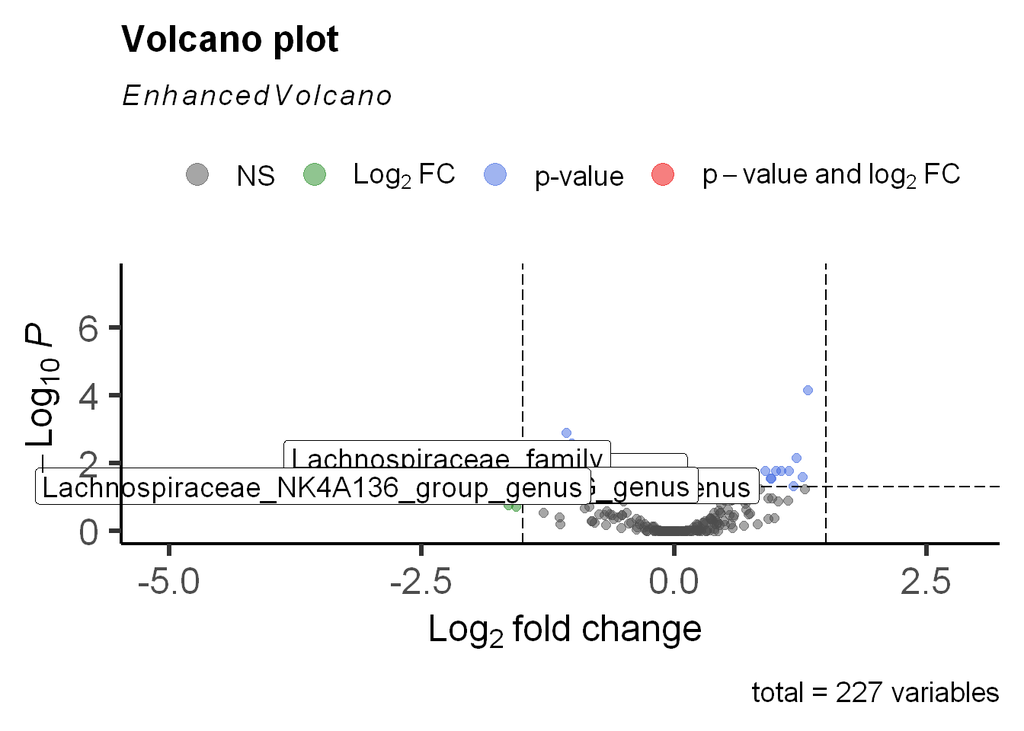

```r
EnhancedVolcano(res,
                lab = res$nickname,
                x = 'lfc_DietTime',
                y = 'q_DietTime',
                ylim = c(0, 7.5),
                pCutoff = 0.05,
                FCcutoff = 1.5,
                gridlines.major = FALSE,
                gridlines.minor = FALSE,
                boxedLabels = TRUE)
```

```r
time <- EnhancedVolcano(res,
                lab = res$nickname,
                x = 'lfc_Timepoint',
                y = 'q_Timepoint',
                ylim = c(0, 7.5),
                pCutoff = 0.05,
                FCcutoff = 1.5,
                widthConnectors = 0.75,
                gridlines.major = FALSE,
                gridlines.minor = FALSE)
time + ggplot2::scale_x_continuous(
           breaks=seq(-4.5,4.5, 1.5))
time14 <- EnhancedVolcano(res,
                lab = res$nickname,
                x = 'lfc_Timepoint',
                y = 'q_Timepoint',
                ylim = c(0, 7.5),
                pCutoff = 0.05,
                FCcutoff = 1.5,
                widthConnectors = 0.75,
                gridlines.major = FALSE,
                gridlines.minor = FALSE)
time14 + ggplot2::scale_x_continuous(
           breaks=seq(-4.5,4.5, 1.5))
diettime14 <- EnhancedVolcano(res,
                lab = res$nickname,
                x = 'lfc_Timepoint',
                y = 'q_Timepoint',
                ylim = c(0, 7.5),
                pCutoff = 0.05,
                FCcutoff = 1.5,
                widthConnectors = 0.75,
                gridlines.major = FALSE,
                gridlines.minor = FALSE)
diettime14 + ggplot2::scale_x_continuous(
           breaks=seq(-4.5,4.5, 1.5))
```

[output not shown]

### ANCOM Genus level

```r
metadata <- read_q2metadata("data/hf_meta_weights.tsv")
taxonomy <- read_qza("data/taxonomy-silva.qza")$data

p.dat <- qiime2R::qza_to_phyloseq(features = "cd_new_results/rarefied_table.qza",
                                  metadata = "data/hf_meta_weights.tsv",
                                  taxonomy = "data/taxonomy-silva.qza")

p.dat <- subset_taxa(p.dat, Genus != "uncultured")

# Run ANCOM BC
if (file.exists("ancom/ancom_genus.rds")) {
  ancom.time.ost.me <- readRDS("ancom/ancom_genus.rds")
} else {
  ancom.time.ost.me <- ancombc2(data=p.dat,
                                fix_formula="Timepoint+Treatment+Diet+Weight_group",
                                tax_level="Genus",
                                p_adj_method="fdr")
  saveRDS(ancom.time.ost.me, "ancom/ancom_genus.rds")
}


# get results
res <- ancom.time.ost.me$res
# create a named list to access the actual taxonomy
tax.map <- taxonomy$Taxon
names(tax.map) <- taxonomy$Feature.ID

# add the taxonomy name
res$name <- tax.map[res$taxon]


# make table
res[order(res$`q_Timepoint2`),] %>%
    select(name,
           taxon,
           lfc_Timepoint4,
           q_Timepoint4,
           lfc_DietWD,
           q_DietWD,
           'lfc_TreatmentM. vaccae',
           'q_TreatmentM. vaccae') %>%
    DT::datatable()
```

|  | name | taxon | lfc_Timepoint4 | q_Timepoint4 | lfc_DietWD | q_DietWD | lfc_TreatmentM. vaccae | q_TreatmentM. vaccae |
| --- | --- | --- | --- | --- | --- | --- | --- | --- |
| 16 |  | A2 | 3.170409177862447 | 1.783832266794978e-14 | 0.8713337288660599 | 0.02871603213948016 | -0.01884892046144025 | 0.9431885982894936 |
| 49 |  | Lactococcus | 2.487245759556167 | 8.71042655451431e-09 | 2.931593753540632 | 2.524737096149258e-17 | -0.2935342584592996 | 0.29939002693832 |
| 1 |  | Lachnospiraceae_UCG-001 | 1.952830986928907 | 6.786837303231593e-05 | 0.06599902912653492 | 0.8303072755572926 | -0.4878825230506074 | 0.07500884325460974 |
| 7 |  | [Eubacterium]_nodatum_group | 1.380246618163784 | 6.786837303231593e-05 | 0.836289228413072 | 0.005853491221212341 | -0.1275522381684078 | 0.6206003172223398 |
| 17 |  | Oscillibacter | 1.376227058455893 | 2.489849895920649e-05 | 0.4692807122165196 | 0.06087591363030587 | -0.3566540504126641 | 0.0658127966083273 |
| 24 |  | Incertae_Sedis | -1.204789583934964 | 0.001438150794426553 | -1.543818561334916 | 1.24201105453218e-06 | 0.07290587501450298 | 0.7823231870793128 |
| 33 |  | Intestinimonas | 1.816585482586098 | 4.382959289387427e-07 | 0.8520484110462425 | 0.000996914910988953 | -0.1138217028580364 | 0.5936250503597316 |
| 42 |  | Eggerthella | 1.254769700454757 | 3.014015550983554e-05 | 0.4728769502759914 | 0.05255035241903386 | -0.2507547913695474 | 0.1664201831129385 |
| 41 |  | Turicibacter | 0.8024731859688956 | 0.1271928978026196 | -0.2551017647978131 | 0.5807522842782232 | -0.2561338777070393 | 0.5936250503597316 |
| 9 |  | Enterococcus | -1.295854563139339 | 0.001089910435196555 | -0.07665195257900782 | 0.8032316187704649 | -0.4077262732370618 | 0.008867761862728273 |

[output cut: 41 more lines]

```r
res_top <- filter(res,
                  q_DietWD < .05)

#write.csv(x = res, file = "ancom/results_ancom_genus.csv", row.names = F)
```

#### Genus: Interactions

Help obtained from: https://joey711.github.io/phyloseq-demo/phyloseq-demo-slides.html

```r
# Prep data
rarefied_table <- read_qza("cd_new_results/rarefied_table.qza")$data
# create a named list to access the actual taxonomy
taxonomy <- read_qza("data/taxonomy-silva.qza")$data
asvs <- rownames(rarefied_table)
taxa <- vector(length=length(asvs))

i <- 1
for (a in asvs){
    taxa[i] <- taxonomy[taxonomy$Feature.ID==a,"Taxon"]
    i <- i + 1
}


tax.map <- taxonomy$Taxon
names(tax.map) <- taxonomy$Feature.ID

# Make phyloseq
p.dat <- qiime2R::qza_to_phyloseq(features = "cd_new_results/rarefied_table.qza",
                                  metadata = "data/metadata_interactions.tsv",
                                  taxonomy = "data/taxonomy-silva.qza")

p.dat <- subset_taxa(p.dat, Genus != "uncultured")


# Run ANCOM BC
if (file.exists("ancom/ancom_genus_interactions.rds")) {
  ancom.time.ost.me <- readRDS("ancom/ancom_genus_interactions.rds")
} else {
  ancom.time.ost.me <- ancombc2(data=p.dat,
                              fix_formula="Treatment + Diet + Timepoint + TreatDiet + TreatTime + DietTime + TreatDietTime",
                              rand_formula="(1|Mouse)",
                              tax_level= "Genus",
                              p_adj_method="fdr")
  saveRDS(ancom.time.ost.me, "ancom/ancom_genus_interactions.rds")
}

# get results
res <- ancom.time.ost.me$res


# add the taxonomy name
res$name <- tax.map[res$taxon]
res_nicknames <- give_nickname(names = res$name, genus = TRUE)
res$nickname <- res_nicknames


# make table
res[order(res$`q_Timepoint1`),] %>%
    select(name,
           nickname,
           taxon,
           lfc_Timepoint1,
           q_Timepoint1,
           lfc_Diet1,
           q_Diet1,
           lfc_DietTime1,
           q_DietTime1,
           lfc_TreatDietTime1,
           q_TreatDietTime1) %>%
    DT::datatable()
```

|  | name | nickname | taxon | lfc_Timepoint1 | q_Timepoint1 | lfc_Diet1 | q_Diet1 | lfc_DietTime1 | q_DietTime1 | lfc_TreatDietTime1 | q_TreatDietTime1 |
| --- | --- | --- | --- | --- | --- | --- | --- | --- | --- | --- | --- |
| 41 |  |  | Robinsoniella | -2.790749751539186 | 0.003975599119503385 | 0.8146609224337682 | 0.9966408418155057 | 2.531195427402827 | 0.01607360491755961 | -1.43630286364642 | 0.8542948077281665 |
| 51 |  |  | Dysgonomonas | -2.750007698573076 | 0.003975599119503385 | 0.2862837548831279 | 1 | 0.07134770821035809 | 1 | 1.560321034820245 | 1 |
| 10 |  |  | Clostridia_UCG-014 | 1.917325145692843 | 0.03846142383387566 | 0.5544557205220321 | 0.9966408418155057 | -3.179162980621496 | 0.009584505427489426 | -0.2513834234388382 | 1 |
| 14 |  |  | A2 | 1.468116200300503 | 0.03846142383387566 | -0.4639532464438479 | 0.9966408418155057 | 1.564725775204888 | 0.06472442382806813 | 0.6659419125711946 | 1 |
| 38 |  |  | Anaeroplasma | 1.520962607048738 | 0.03846142383387566 | 0.3952957324366821 | 0.9966408418155057 | -2.579116597959297 | 0.005080256216316894 | -1.136187317283617 | 0.8542948077281665 |
| 34 |  |  | Hungatella | -1.529755037488304 | 0.09220776906677353 | 0.3907366353749697 | 0.9966408418155057 | 0.4113484351446553 | 0.7541452615695392 | -2.370363308124454 | 0.6256775251135999 |
| 22 |  |  | Incertae_Sedis | -1.517195303875986 | 0.1127405372734312 | -1.75154265298795 | 0.4653450947297966 | 0.7941517064137835 | 0.4823586517513224 | -2.548522062337145 | 0.6256775251135999 |
| 18 |  |  | Akkermansia | -1.366012151670947 | 0.2501832877222038 | 0.6082182275596231 | 0.9966408418155057 | 1.362336778259057 | 0.2553661660886098 | 2.343383691589278 | 0.6256775251135999 |
| 2 |  |  | Lachnospiraceae_NK4A136_group | 1.042123374142176 | 0.29883802908591 | -1.021503205714154 | 0.663489400510188 | 1.097149844152467 | 0.2624399059876079 | -0.3109917327474793 | 1 |
| 42 |  |  | Turicibacter | 1.394450990149234 | 0.29883802908591 | 0.00856470014896233 | 1 | 1.448139962491172 | 0.2624399059876079 | -1.44413356453985 | 0.8542948077281665 |

[output cut: 41 more lines]

```r
#####
# Individual timepoints
# TIMEPOINT 1
p.dat1 <- subset_samples(p.dat, Timepoint != "1")
p.dat1 <- subset_samples(p.dat1, Timepoint != "2")
p.dat1 <- subset_samples(p.dat1, Timepoint != "3")

# Run ANCOM BC
if (file.exists("ancom/ancom_genus_t1.rds")) {
  ancom.genus1 <- readRDS("ancom/ancom_genus_t1.rds")
} else {
  ancom.genus1 <- ancombc2(data=p.dat1,
                              fix_formula="Treatment + Diet + TreatDiet",
                              tax_level= "Genus",
                              p_adj_method="fdr")
  saveRDS(ancom.genus1, "ancom/ancom_genus_t1.rds")
}

# get results
res1 <- ancom.genus1$res

# add the taxonomy name
res1$name <- tax.map[res1$taxon]
res_nicknames <- give_nickname(names = res1$name, genus = TRUE)
res1$nickname <- res_nicknames

# make table
res1[order(res1$`q_Diet1`),] %>%
    select(name,
           nickname,
           taxon,
           lfc_Diet1,
           q_Diet1,
           lfc_Treatment1,
           q_Treatment1,
           lfc_TreatDiet1,
           q_TreatDiet1) %>%
    DT::datatable()
```

|  | name | nickname | taxon | lfc_Diet1 | q_Diet1 | lfc_Treatment1 | q_Treatment1 | lfc_TreatDiet1 | q_TreatDiet1 |
| --- | --- | --- | --- | --- | --- | --- | --- | --- | --- |
| 1 |  |  | Lachnospiraceae_UCG-001 | -1.195854987626538 | 1 | -0.9955858602238289 | 1 | 1.379311851691111 | 0.4652135769138078 |
| 2 |  |  | Lachnospiraceae_NK4A136_group | -1.730550486284392 | 1 | 1.027332689719079 | 1 | 0.630162675752097 | 0.8933438847897318 |
| 3 |  |  | Roseburia | -1.091592711688588 | 1 | 0.3680042284356049 | 1 | -0.1054192578313318 | 0.9484857135505436 |
| 4 |  |  | Lactobacillus | -0.3906519056668564 | 1 | 0.4745489873279118 | 1 | -0.3323401127240191 | 0.828225115171148 |
| 5 |  |  | Clostridia_vadinBB60_group | -0.6539615541225291 | 1 | -0.2163537262652694 | 1 | 0.4594125247193738 | 0.828225115171148 |
| 6 |  |  | Enterococcus | -0.5027056398359137 | 1 | -0.2646282764022063 | 1 | 0.7580320955938311 | 0.4652135769138078 |
| 7 |  |  | Escherichia-Shigella | -0.697363313686236 | 1 | -0.5077726171756848 | 1 | 0.9998548179738366 | 0.4707428867477438 |
| 8 |  |  | Lachnospiraceae_FCS020_group | -0.5980834178343081 | 1 | 0.1888597632926754 | 1 | -0.2415966452401789 | 0.8933438847897318 |
| 9 |  |  | A2 | -1.185777767750278 | 1 | 0.4344086474691969 | 1 | 0.2150684183960636 | 0.8933438847897318 |
| 10 |  |  | Oscillibacter | -0.5525682646667676 | 1 | -0.05490405021586117 | 1 | -0.2316650150022241 | 0.8933438847897318 |

[output cut: 39 more lines]

```r
#####
# TIMEPOINT 2
p.dat2 <- subset_samples(p.dat, Timepoint != "0")
p.dat2 <- subset_samples(p.dat2, Timepoint != "2")
p.dat2 <- subset_samples(p.dat2, Timepoint != "3")

# Filtering low-variance OTUs
p.dat2 = transform_sample_counts(p.dat2, function(x) x/sum(x))
p.dat2 = filter_taxa(p.dat2, function(x) var(x) > 1e-05, TRUE)

# Run ANCOM BC
if (file.exists("ancom/ancom_genus_t2.rds")) {
  ancom.genus2 <- readRDS("ancom/ancom_genus_t2.rds")
} else {
  ancom.genus2 <- ancombc2(data=p.dat2,
                              fix_formula="Treatment + Diet + TreatDiet",
                              tax_level= "Genus",
                              p_adj_method="fdr")
  saveRDS(ancom.genus2, "ancom/ancom_genus_t2.rds")
}

# get results
res2 <- ancom.genus2$res

# add the taxonomy name
res2$name <- tax.map[res2$taxon]
res_nicknames <- give_nickname(names = res2$name, genus = TRUE)
res2$nickname <- res_nicknames

# make table
res2[order(res2$`q_Diet1`),] %>%
    select(name,
           nickname,
           taxon,
           lfc_Diet1,
           q_Diet1,
           lfc_Treatment1,
           q_Treatment1,
           lfc_TreatDiet1,
           q_TreatDiet1) %>%
    DT::datatable()
```

|  | name | nickname | taxon | lfc_Diet1 | q_Diet1 | lfc_Treatment1 | q_Treatment1 | lfc_TreatDiet1 | q_TreatDiet1 |
| --- | --- | --- | --- | --- | --- | --- | --- | --- | --- |
| 27 |  |  | Genus:Lactococcus | 4.982173245629656 | 2.958426781126128e-19 | -0.3295968295930862 | 1 | -0.261049573864287 | 0.9197523361366442 |
| 28 |  |  | Genus:Tuzzerella | 2.96670797651916 | 6.727718926177262e-10 | 0.6473758556093626 | 1 | -1.000913368331927 | 0.592680669057284 |
| 17 |  |  | Genus:Erysipelatoclostridium | 2.25874634744697 | 1.72770345414541e-08 | -0.04239316412070795 | 1 | -0.8577815452457148 | 0.5972203104243851 |
| 29 |  |  | Genus:[Eubacterium]_nodatum_group | 2.144180559516176 | 1.72770345414541e-08 | -0.01170063620238763 | 1 | -0.339860056474812 | 0.9153698309345227 |
| 25 |  |  | Family:Lachnospiraceae | 2.895787158534566 | 4.394013230991252e-08 | 0.6565923479456695 | 1 | -1.157339583201139 | 0.592680669057284 |
| 15 |  |  | Genus:Robinsoniella | 3.075723240746254 | 7.898044185436868e-08 | -0.1144481721318066 | 1 | -0.8608373497835805 | 0.5972203104243851 |
| 20 |  |  | Genus:uncultured_1 | 2.367865782881879 | 7.898044185436868e-08 | 0.09799291381741958 | 1 | -0.2523220073955612 | 0.9197523361366442 |
| 24 |  |  | Genus:Anaerotruncus | 2.899925820911986 | 1.062092382628512e-07 | -0.1465102994901936 | 1 | 0.0303027959829462 | 1 |
| 7 |  |  | Genus:Lachnoclostridium | 2.203782279081563 | 8.178400090529064e-07 | 0.9660113919098885 | 1 | -1.810797823819955 | 0.06476483326116962 |
| 11 |  |  | Genus:Blautia | 1.998505596431996 | 1.147224823536193e-06 | 0.1783663963167666 | 1 | -0.1021101522932578 | 0.9845652952120927 |

[output cut: 24 more lines]

```r
#####
# TIMEPOINT 3
p.dat3 <- subset_samples(p.dat, Timepoint != "0")
p.dat3 <- subset_samples(p.dat3, Timepoint != "1")
p.dat3 <- subset_samples(p.dat3, Timepoint != "3")

# Filtering low-variance OTUs
p.dat3 = transform_sample_counts(p.dat3, function(x) x/sum(x))
p.dat3 = filter_taxa(p.dat3, function(x) var(x) > 1e-05, TRUE)

# Run ANCOM BC
if (file.exists("ancom/ancom_genus_t3.rds")) {
  ancom.genus3 <- readRDS("ancom/ancom_genus_t3.rds")
} else {
  ancom.genus3 <- ancombc2(data=p.dat3,
                           fix_formula="Treatment + Diet + TreatDiet",
                           tax_level= "Genus",
                           p_adj_method="fdr")
  saveRDS(ancom.genus3, "ancom/ancom_genus_t3.rds")
}

# get results
res3 <- ancom.genus3$res

# add the taxonomy name
res3$name <- tax.map[res3$taxon]
res_nicknames <- give_nickname(names = res3$name, genus = TRUE)
res3$nickname <- res_nicknames

# make table
res3[order(res3$`q_Diet1`),] %>%
    select(name,
           nickname,
           taxon,
           lfc_Diet1,
           q_Diet1,
           lfc_Treatment1,
           q_Treatment1,
           lfc_TreatDiet1,
           q_TreatDiet1) %>%
    DT::datatable()
```

|  | name | nickname | taxon | lfc_Diet1 | q_Diet1 | lfc_Treatment1 | q_Treatment1 | lfc_TreatDiet1 | q_TreatDiet1 |
| --- | --- | --- | --- | --- | --- | --- | --- | --- | --- |
| 1 |  |  | Genus:Lachnospiraceae_NK4A136_group | -1.923962992769147 | 1 | -0.480615403904099 | 1 | 0.2547548680757915 | 0.9867925583727195 |
| 2 |  |  | Genus:Roseburia | -1.681977290990563 | 1 | -1.244474620503837 | 1 | 0.9733774700539555 | 0.6169516712103378 |
| 3 |  |  | Genus:Lactobacillus | -3.162101821051111 | 1 | -0.1821313116947615 | 1 | -0.2031580549667604 | 0.9937529749877733 |
| 4 |  |  | Family:Lachnospiraceae | -1.360838909535309 | 1 | -0.8825899363004619 | 1 | 1.015920935370974 | 0.3605249805882661 |
| 5 |  |  | Family:Tannerellaceae | -1.513775348613455 | 1 | -0.6015554840645677 | 1 | 0.01334777527796907 | 1 |
| 6 |  |  | Genus:A2 | 0.6413441685011493 | 1 | -0.8217440151575603 | 1 | 0.3386668002063024 | 0.9937529749877733 |
| 7 |  |  | Genus:Romboutsia | 1.23553198672065 | 1 | 0.6126738607569653 | 1 | -1.744560259665718 | 0.3605249805882661 |
| 8 |  |  | Genus:Muribaculaceae | -3.157072584719365 | 1 | -0.4134113964227009 | 1 | -0.05478799220285731 | 1 |
| 9 |  |  | Genus:Marvinbryantia | -0.7986923477958929 | 1 | -0.9563444841507528 | 1 | 0.09800583539560617 | 1 |
| 10 |  |  | Genus:uncultured | -1.642437625809896 | 1 | -0.6916538669157766 | 1 | 0.3233794987666535 | 0.9867925583727195 |

[output cut: 22 more lines]

```r
#####
# TIMEPOINT 4
p.dat4 <- subset_samples(p.dat, Timepoint != "0")
p.dat4 <- subset_samples(p.dat4, Timepoint != "1")
p.dat4 <- subset_samples(p.dat4, Timepoint != "2")

# Filtering low-variance OTUs
p.dat4 = transform_sample_counts(p.dat4, function(x) x/sum(x))
p.dat4 = filter_taxa(p.dat4, function(x) var(x) > 1e-05, TRUE)

# Run ANCOM BC
if (file.exists("ancom/ancom_genus_t4.rds")) {
  ancom.genus4 <- readRDS("ancom/ancom_genus_t4.rds")
} else {
  ancom.genus4 <- ancombc2(data=p.dat4,
                           fix_formula="Treatment + Diet + TreatDiet",
                           tax_level= "Genus",
                           p_adj_method="fdr")
  saveRDS(ancom.genus4, "ancom/ancom_genus_t4.rds")
}

# get results
res4 <- ancom.genus4$res

# add the taxonomy name
res4$name <- tax.map[res4$taxon]
res_nicknames <- give_nickname(names = res4$name, genus = TRUE)
res4$nickname <- res_nicknames

# make table
res4[order(res4$`q_Diet1`),] %>%
    select(name,
           nickname,
           taxon,
           lfc_Diet1,
           q_Diet1,
           lfc_Treatment1,
           q_Treatment1,
           lfc_TreatDiet1,
           q_TreatDiet1) %>%
    DT::datatable()
```

|  | name | nickname | taxon | lfc_Diet1 | q_Diet1 | lfc_Treatment1 | q_Treatment1 | lfc_TreatDiet1 | q_TreatDiet1 |
| --- | --- | --- | --- | --- | --- | --- | --- | --- | --- |
| 1 |  |  | Genus:Lachnospiraceae_NK4A136_group | -0.254697829628366 | 1 | -0.1064450883267073 | 1 | -1.009093068748092 | 0.282018608782056 |
| 2 |  |  | Genus:Roseburia | 0.002332910498958608 | 1 | 0.5543047427252766 | 1 | -0.9948792704212172 | 0.5840805351810276 |
| 3 |  |  | Genus:Lactobacillus | -1.778261577776559 | 1 | -0.7881676250692043 | 1 | 0.09707929171237216 | 0.9238080741866019 |
| 4 |  |  | Family:Lachnospiraceae | 0.3971091994492706 | 1 | -0.02787044812031601 | 1 | -0.4379534551719446 | 0.7196120244724333 |
| 5 |  |  | Family:Tannerellaceae | 0.05783498212296453 | 1 | -0.6509700486184443 | 1 | -0.3982018088612156 | 0.7021680566870552 |
| 6 |  |  | Genus:A2 | 1.015717064619097 | 1 | -0.2991609397213329 | 1 | 0.2968140828710493 | 0.8611129987638484 |
| 7 |  |  | Genus:Romboutsia | 2.605580225195917 | 1 | -0.6169030564899896 | 1 | -0.2029570100020023 | 0.9190287817729441 |
| 8 |  |  | Genus:Incertae_Sedis | -2.046030654935098 | 1 | -0.1346000639631672 | 1 | -0.8522010074104195 | 0.5840805351810276 |
| 9 |  |  | Genus:Colidextribacter | 1.854989639927987 | 1 | -0.2497994910355509 | 1 | -0.4198254812833462 | 0.6635671476545135 |
| 10 |  |  | Genus:[Eubacterium]_xylanophilum_group | -3.649304943587411 | 1 | -0.08422090474661974 | 1 | -1.128086765006338 | 0.199848321021837 |

[output cut: 24 more lines]

```r
#write_csv(res, "ancom/ancom_genus_time1-4.csv")
#write_csv(res1, "ancom/ancom_genus_time1.csv")
#write_csv(res2, "ancom/ancom_genus_time2.csv")
#write_csv(res3, "ancom/ancom_genus_time3.csv")
#write_csv(res4, "ancom/ancom_genus_time4.csv")
```

#### Genus: Sleuthing

Run the code above. Find out which genera belong which nickname and which ASVs are in there

```r
# top genera
top_g <- read_csv("data/biplot_table_Hfd_t1-4_raw.csv")
top_g$taxon <- as.factor(top_g$taxon)

# get representative sequences
# sequences.fasta made in qiime from rep_seqs.qzv
seqs <- read.fasta(file = "data/sequences.fasta",
                   as.string=TRUE,
                   forceDNAtolower = FALSE)


s_df <- as.data.frame(seqs, col.names = F)
sdf <- t(s_df)
sdf <- as.data.frame(sdf)
names(sdf)[1] <- "Sequence"

grab_asvs <- t(seqs)
g_a <- t(grab_asvs)
sdf$ASV <- rownames(g_a)

# get taxonomy
taxonomy <- read_qza("data/taxonomy-silva.qza")$data
taxonomy_split <- read_qza("data/taxonomy-silva.qza")$data %>% parse_taxonomy()
taxonomy_split$Feature.ID <- taxonomy$Feature.ID

# filtered by top genera
top_taxa <- filter(taxonomy_split,
                   Genus %in% top_g$taxon)

top_seqs <- filter(sdf,
                   ASV %in% top_taxa$Feature.ID)

top_taxa$Sequence <- top_seqs$Sequence

#write.csv(x = top_taxa, file = "top_ANCOMgenera_seqs.csv", row.names = F)

# LFC + or - 3
top_g3 <- read_csv("data/biplot_table_Hfd_t1-4_lfc3_raw.csv")
top_g3$taxon <- as.factor(top_g3$taxon)
unique_g3 <- levels(top_g3$taxon)

top_taxa3 <- filter(taxonomy_split,
                    Genus %in% top_g3$taxon)

top_seqs3 <- filter(sdf,
                    ASV %in% top_taxa3$Feature.ID)

top_taxa3$Sequence <- top_seqs3$Sequence


#write.csv(x = top_taxa3, file = "ancom/top_ANCOMgenera_seqs_lfc3.csv", row.names = F)
```

#### Genus: Plotting

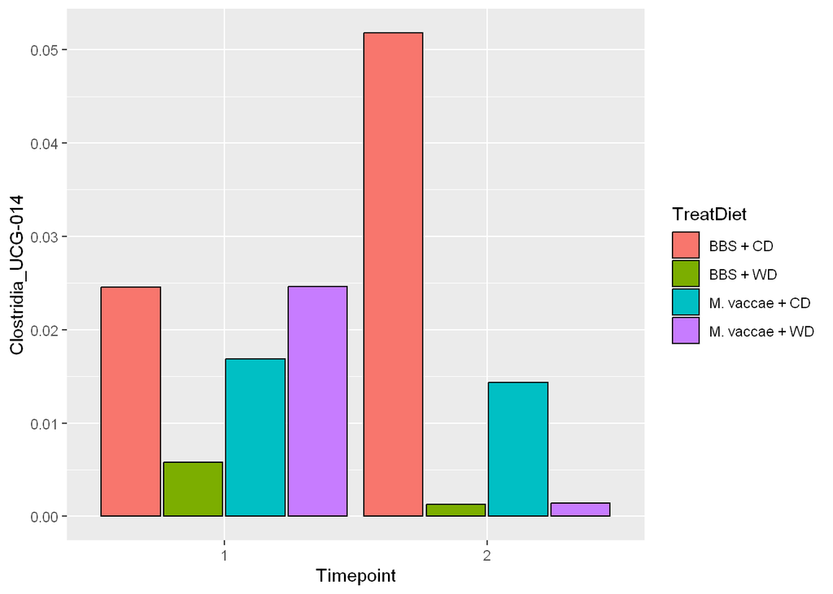

```r
top_g <- read_csv("data/biplot_table_Hfd_t1-4_lfc3_raw.csv")
top_g$taxon <- as.factor(top_g$taxon)
top_g$taxon <- fct_recode(top_g$taxon,
                           "Lachnospiraceae_GCA-900066575" = "GCA-900066575")

top_asvs <- read_csv("ancom/top_ANCOMgenera_seqs_lfc3.csv")
top_asvs$Genus <- as.factor(top_asvs$Genus)
top_asvs$Genus <- fct_recode(top_asvs$Genus,
                             "Lachnospiraceae_GCA-900066575" = "GCA-900066575")
meta <- read_q2metadata("data/hf_meta_weights.tsv")

# Timepoint 1vs2: Timepoint1 and Diettime1
m_12 <- filter(meta,
               Timepoint == "1" | Timepoint == "2")
rownames(m_12) <- m_12$SampleID

# convert rarefied table to percent abundance
rarefied_table <- read_qza("cd_new_results/rarefied_table.qza")$data
ra_avg_mat <- rarefied_table

for (row in 1:nrow(rarefied_table)){
  for (col in 1:ncol(rarefied_table)){
    total <- sum(rarefied_table[,col])
    ra_avg_mat[row, col] <- rarefied_table[row, col]/total * 100
  }
}

ra_mat <- t(ra_avg_mat)
rare_df <- as.data.frame(ra_mat)

# Remove columns that sum in 0
rare_df <- rare_df[colSums(abs(rare_df), na.rm = TRUE) > 0]

rare_df$SampleID <- rownames(rare_df)
rare_df$SampleID <- as.factor(rare_df$SampleID)
t12_rare <- filter(rare_df,
                   SampleID %in% m_12$SampleID)

rare_12 <- transpose(t12_rare)
rownames(rare_12) <- colnames(t12_rare)
colnames(rare_12) <- rownames(t12_rare)

asvs_12 <- rare_12[(row.names(rare_12) %in% top_asvs$Feature.ID),]
asvs_12$ASV <- rownames(asvs_12)


asvs <- rownames(asvs_12)
genera <- vector(length=length(asvs))
taxonomy <- read_qza("data/taxonomy-silva.qza")$data %>% parse_taxonomy()
taxonomy$Feature.ID <- rownames(taxonomy)

i <- 1
for (a in asvs){
    genera[i] <- taxonomy[taxonomy$Feature.ID==a,"Genus"]
    i <- i + 1
}

asvs_12$Genus <- genera
asvs_12$Genus <- as.factor(asvs_12$Genus)

top_g_12 <- filter(top_g,
                   significance_filter == "q_DietTime1" | significance_filter == "q_Timepoint1")

top_asvs_12 <- filter(asvs_12,
                      Genus %in% top_g_12$taxon)

# reset levels of Genus by changing it to character then factor again
top_asvs_12$Genus <- as.character(top_asvs_12$Genus)
top_asvs_12$Genus <- as.factor(top_asvs_12$Genus)
top_asvs_12$UniqueG <- NA

for (i in 1:nrow(top_asvs_12)){
  name <- as.character(top_asvs_12$Genus[i])
  top_asvs_12$UniqueG[i] <- paste(name, "__", as.character(i), sep="")
}


rownames(top_asvs_12) <- top_asvs_12$UniqueG
filter_12 <- select(top_asvs_12, -Genus, -ASV, -UniqueG)
top_12 <- transpose(filter_12)
rownames(top_12) <- colnames(filter_12)
colnames(top_12) <- rownames(filter_12)

# Remove columns that sum in 0
top_12 <- mutate_all(top_12, function(x) as.numeric(as.character(x)))
top_12 <- top_12[colSums(abs(top_12), na.rm = TRUE) > 0]



m_12_bac <- merge(top_12, m_12,
                  by = 'row.names', all = TRUE)

rownames(m_12_bac) <- m_12_bac$Row.names
m_12_bac <- select(m_12_bac, -Row.names)

# specific to this dataframe, where bacteria are 1:21
mbac_long <- pivot_longer(m_12_bac,
                          cols = 1:21,
                          names_to = c(".value","Number"),
                          names_sep = "__")
mbac_long <- select(mbac_long, -Number)
mbac_long$TreatDiet <- paste(mbac_long$Treatment, "+", mbac_long$Diet)

ggplot(mbac_long, aes(x=Timepoint, y=`Clostridia_UCG-014`, fill=TreatDiet)) +
  geom_bar(color = "black",
           stat="summary",
           fun = mean,
           position=position_dodge(.95))
```

[figure not shown]

```r
# all four timepoints
rownames(meta) <- meta$SampleID

# convert rarefied table to percent abundance
rarefied_table <- read_qza("cd_new_results/rarefied_table.qza")$data
ra_avg_mat <- rarefied_table

for (row in 1:nrow(rarefied_table)){
  for (col in 1:ncol(rarefied_table)){
    total <- sum(rarefied_table[,col])
    ra_avg_mat[row, col] <- rarefied_table[row, col]/total * 100
  }
}

ra_mat <- t(ra_avg_mat)
rare_df <- as.data.frame(ra_mat)

# Remove columns that sum in 0
rare_df <- rare_df[colSums(abs(rare_df), na.rm = TRUE) > 0]

rare_df$SampleID <- rownames(rare_df)
rare_df$SampleID <- as.factor(rare_df$SampleID)

rare <- transpose(rare_df)
rownames(rare) <- colnames(rare_df)
colnames(rare) <- rownames(rare_df)

asv_df <- rare[(row.names(rare) %in% top_asvs$Feature.ID),]
asv_df$ASV <- rownames(asv_df)


asvs <- rownames(asv_df)
genera <- vector(length=length(asvs))
taxonomy <- read_qza("data/taxonomy-silva.qza")$data %>% parse_taxonomy()
taxonomy$Feature.ID <- rownames(taxonomy)

i <- 1
for (a in asvs){
    genera[i] <- taxonomy[taxonomy$Feature.ID==a,"Genus"]
    i <- i + 1
}

asv_df$Genus <- genera
asv_df$Genus <- as.factor(asv_df$Genus)
asv_df$UniqueG <- NA

for (i in 1:nrow(asv_df)){
  name <- as.character(asv_df$Genus[i])
  asv_df$UniqueG[i] <- paste(name, "__", as.character(i), sep="")
}


rownames(asv_df) <- asv_df$UniqueG
filtered_adf <- select(asv_df, -Genus, -ASV, -UniqueG)
adf <- transpose(filtered_adf)
rownames(adf) <- colnames(filtered_adf)
colnames(adf) <- rownames(filtered_adf)

# Remove columns that sum in 0
adf <- mutate_all(adf, function(x) as.numeric(as.character(x)))
adf <- adf[colSums(abs(adf), na.rm = TRUE) > 0]
adf_cols <- as.numeric(ncol(adf))


mbac <- merge(adf, meta,
              by = 'row.names', all = TRUE)

rownames(mbac) <- mbac$Row.names
mbac <- select(mbac, -Row.names)


mb_long <- pivot_longer(mbac,
                        cols = 1:67,
                        names_to = c(".value","Number"),
                        names_sep = "__")
mb_long <- dplyr::select(mb_long, -Number, -Weight_group)

mb_ll <- pivot_longer(mb_long,
                      cols = 11:20,
                      names_to = "Genus",
                      values_to = "Relative_Abundance",
                      values_drop_na = TRUE)


mb_ll$TreatDiet <- paste(mb_ll$Treatment, "+", mb_ll$Diet)
mb_ll$Genus <- as.factor(mb_ll$Genus)
mb_ll$Genus <- fct_recode(mb_ll$Genus,
                          "Lachnospiraceae\nUCG-001" = "Lachnospiraceae_UCG-001",
                          "Lachnospiraceae\nGCA-900066575" = "GCA-900066575",
                          "[Eubacterium]\nxylanophilum_group" = "[Eubacterium]_xylanophilum_group",
                          "Clostridia_vadin\nBB60_group" = "Clostridia_vadinBB60_group")

ggplot(mb_ll, aes(x=Timepoint, y=Relative_Abundance, fill=TreatDiet)) +
  geom_bar(color = "black",
           stat="summary",
           fun = mean,
           position=position_dodge(.95))+
  scale_fill_manual(values = c('#ADD4ED', '#016796', '#FCB5AF', '#A73325'))+
  geom_errorbar(stat="summary",
                fun = mean,
                fun.min = function(X) mean(X),
                fun.max = function(X) mean(X) + std.error(X),
                position=position_dodge(.95)) +
   # set labs
  labs(title= "",
       y = "Percent Relative Abundance",
       x = "Timepoint") +
  # theme
  theme_foundation(base_size = 14, base_family = "arial") +
  theme(
    panel.grid.major = element_blank(),
    panel.grid.minor = element_blank(),
    panel.border = element_blank(),
    panel.background = element_blank(),
    plot.title = element_text(face = "bold",
                              size = 22, hjust = 0.5),
    axis.line = element_line(linewidth = 1),
    axis.ticks = element_line(linewidth = 1),
    axis.title = element_text(face = "bold", size = rel(1)),
    axis.title.y = element_text(angle = 90, vjust = 2, size=18),
    axis.title.x = element_text(vjust = -0.2, size=18),
    axis.text = element_text(size = 14),
    axis.text.x = element_text(size = 18),
    axis.text.y = element_text(size = 16),
    plot.background = element_blank(),
    legend.title=element_text(size=16),
    strip.background = element_blank(),
    strip.text = element_text(face="italic", size = 15),
    legend.text=element_text(size=16)) +
  guides(fill=guide_legend(title="Group")) +
  facet_wrap(~Genus, scales = "free", ncol = 5)
```

```r
#ggsave("figures/top_genera_ANCOM_panels.png", width = 16, height = 8, units = "in")
```

Figure Hex Codes M.v/CD = FCB5AF M.v/WD = A73325 BBS/CD = ADD4ED BBS/WD = 016796

### ANCOM Phylum level

```r
taxonomy <- read_qza("data/taxonomy-silva.qza")$data

p.dat <- qiime2R::qza_to_phyloseq(features = "cd_new_results/rarefied_table.qza",
                                  metadata = "data/hf_meta_weights.tsv",
                                  taxonomy = "data/taxonomy-silva.qza")


# Run ANCOM BC
if (file.exists("data/ancom_phylum.rds")) {
  ancom <- readRDS("data/ancom_phylum.rds")
} else {
  ancom <- ancombc2(data=p.dat,
                    fix_formula="Timepoint+Treatment+Diet+Weight_group",
                    tax_level="Phylum",
                    p_adj_method="fdr")
  saveRDS(ancom, "data/ancom_phylum.rds")
}


p.dat2 <- qiime2R::qza_to_phyloseq(features = "cd_new_results/rarefied_table.qza",
                                  metadata = "data/metadata_interactions.tsv",
                                  taxonomy = "data/taxonomy-silva.qza")

# Run ANCOM BC
if (file.exists("ancom/ancom_phylum_interactions.rds")) {
  ancomi <- readRDS("ancom/ancom_phylum_interactions.rds")
} else {
  ancomi <- ancombc2(data=p.dat2,
                     fix_formula="Treatment + Diet + Timepoint + TreatDiet + TreatTime + DietTime + TreatDietTime",
                     rand_formula="(1|Mouse)",
                     tax_level= "Phylum",
                     p_adj_method="fdr")
  saveRDS(ancomi, "ancom/ancom_phylum_interactions.rds")
}


# get results
res2 <- ancomi$res
# create a named list to access the actual taxonomy
tax.map <- taxonomy$Taxon
names(tax.map) <- taxonomy$Feature.ID

# add the taxonomy name
res2$name <- tax.map[res2$taxon]


# make table
res2[order(res2$`q_Timepoint1`),] %>%
    select(name,
           taxon,
           lfc_Timepoint1,
           q_Timepoint1,
           lfc_Diet1,
           q_Diet1,
           lfc_DietTime1,
           q_DietTime1,
           lfc_TreatDietTime1,
           q_TreatDietTime1) %>%
    DT::datatable()
```

|  | name | taxon | lfc_Timepoint1 | q_Timepoint1 | lfc_Diet1 | q_Diet1 | lfc_DietTime1 | q_DietTime1 | lfc_TreatDietTime1 | q_TreatDietTime1 |
| --- | --- | --- | --- | --- | --- | --- | --- | --- | --- | --- |
| 4 |  | Phylum:Verrucomicrobiota | -1.31507703693002 | 0.09861260944078373 | 0.6456093829491558 | 0.6928747863299082 | 1.301853903926453 | 0.261131715959221 | 2.368408914886304 | 0.2638842014283453 |
| 6 |  | Phylum:Actinobacteriota | 0.7683155618340912 | 0.09861260944078373 | 0.3318069543235116 | 0.6928747863299082 | 0.06942714110702357 | 0.8776519480835483 | -0.3305627151238545 | 0.7114477683545183 |
| 2 |  | Phylum:Bacteroidota | 0.1897373768562872 | 0.7682687323490043 | 0.1573514022114721 | 0.6928747863299082 | -0.9864000264763263 | 0.007800033714297536 | 0.2294009571741669 | 0.7114477683545183 |
| 3 |  | Phylum:Proteobacteria | -0.3627639045596495 | 0.7721366462962145 | 0.2827725582733367 | 0.6928747863299082 | -0.4155362680852519 | 0.6996543054759196 | -1.885566422552961 | 0.2638842014283453 |
| 1 |  | Phylum:Firmicutes | 0.05280216752551931 | 0.7736812610442474 | 0.02503840490383073 | 0.9159824750182395 | 0.4146094995672966 | 0.261131715959221 | -0.09820174743377938 | 0.7640321321088802 |
| 5 |  | Phylum:Deferribacterota | -0.2283843797428866 | 0.7736812610442474 | -0.5379076499396067 | 0.6928747863299082 | 0.9745345144011271 | 0.3240891770524331 | -1.50353994853196 | 0.3576513548879944 |

```r
res_top <- filter(res2,
                  q_DietTime3 < .05)

#write.csv(x = res2, file = "ancom/results_ancom_phyla.csv", row.names = F)
```

#### Phylum: Sleuthing

Run the code above. Get the ASVs per phylum to later calculate % abundance.

```r
# top genera
top <- read_csv("ancom/results_ancom_phyla_top3.csv")
top$taxon <- as.factor(top$taxon)

# get representative sequences
# sequences.fasta made in qiime from rep_seqs.qzv
seqs <- read.fasta(file = "data/sequences.fasta",
                   as.string=TRUE,
                   forceDNAtolower = FALSE)


s_df <- as.data.frame(seqs, col.names = F)
sdf <- t(s_df)
sdf <- as.data.frame(sdf)
names(sdf)[1] <- "Sequence"

grab_asvs <- t(seqs)
g_a <- t(grab_asvs)
sdf$ASV <- rownames(g_a)
```

#### Phylum: Plotting

```r
top_p <- read_csv("ancom/results_ancom_phyla_top2.csv")
```

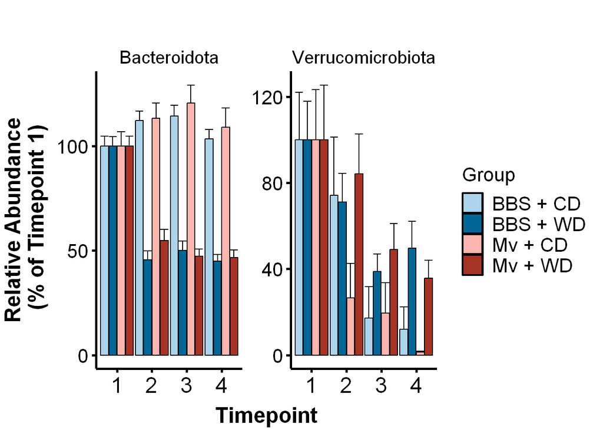

```r
top_p$taxon <- as.factor(top_p$taxon)

meta <- read_q2metadata("data/hf_meta_weights.tsv")
rownames(meta) <- meta$SampleID

# convert rarefied table to percent abundance
rarefied_table <- read_qza("cd_new_results/rarefied_table.qza")$data
ra_avg_mat <- rarefied_table

for (row in 1:nrow(rarefied_table)){
  for (col in 1:ncol(rarefied_table)){
    total <- sum(rarefied_table[,col])
    ra_avg_mat[row, col] <- rarefied_table[row, col]/total * 100
  }
}

ra_mat <- t(ra_avg_mat)
rare_df <- as.data.frame(ra_mat)

# # Remove columns that sum in 0
rare_df <- rare_df[colSums(abs(rare_df), na.rm = TRUE) > 0]

rare <- transpose(rare_df)
rownames(rare) <- colnames(rare_df)
colnames(rare) <- rownames(rare_df)


asvs <- rownames(rare)
phyla <- vector(length=length(asvs))
taxonomy <- read_qza("data/taxonomy-silva.qza")$data %>% parse_taxonomy()
taxonomy$Feature.ID <- rownames(taxonomy)

i <- 1
for (a in asvs){
    phyla[i] <- taxonomy[rownames(taxonomy)==a,"Phylum"]
    i <- i + 1
}

rare$Phylum <- phyla
rare$Phylum <- as.factor(rare$Phylum)

top_rare <- rare[rare$Phylum %in% top_p$taxon,]

# reset levels of Phylum by changing it to character then factor again
top_rare$Phylum <- as.character(top_rare$Phylum)
top_rare$Phylum <- as.factor(top_rare$Phylum)

# finally: sum the matching phyla together, then transpose
top_sums <- aggregate(.~Phylum, data=top_rare, FUN=sum)

t_sums <- dplyr::select(top_sums, -Phylum)
t_sums <- t(t_sums)
colnames(t_sums) <- top_sums$Phylum

# add metadata
mbac <- merge(t_sums, meta,
              by = 'row.names', all = TRUE)

rownames(mbac) <- mbac$Row.names
mbac <- select(mbac, -Row.names)


mb_long <- pivot_longer(mbac,
                        cols = 1:2,
                        names_to = "Phylum",
                        values_to = "Relative_Abundance")

mb_long$Phylum <- as.factor(mb_long$Phylum)

# express realtive abundance as percent of timepoint 1 (ctrl)
mb_long$PerAbundance <- NA

mb_long <- mb_long %>%
  group_by(TreatDiet, Phylum) %>%
  mutate(
    ra_t1 = ifelse(Timepoint == "1", Relative_Abundance, NA_real_),
    t1_avg = mean(ra_t1, na.rm = TRUE),
    PerAbundance = Relative_Abundance / t1_avg * 100)


ggplot(mb_long, aes(x=Timepoint, y=PerAbundance, fill=TreatDiet)) +
  geom_bar(color = "black",
           stat="summary",
           fun = mean,
           position=position_dodge(.95))+
  scale_fill_manual(values = c('#ADD4ED', '#016796', '#FCB5AF', '#A73325'))+
  geom_errorbar(stat="summary",
                fun = mean,
                fun.min = function(X) mean(X),
                fun.max = function(X) mean(X) + std.error(X),
                position=position_dodge(.95)) +
   # set labs
  labs(title= "",
       y = "Relative Abundance\n (% of Timepoint 1)",
       x = "Timepoint") +
  # theme
  theme_foundation(base_size = 14, base_family = "arial") +
  theme(
    panel.grid.major = element_blank(),
    panel.grid.minor = element_blank(),
    panel.border = element_blank(),
    panel.background = element_blank(),
    plot.title = element_text(face = "bold",
                              size = 22, hjust = 0.5),
    axis.line = element_line(linewidth = 1),
    axis.ticks = element_line(linewidth = 1),
    axis.title = element_text(face = "bold", size = rel(1)),
    axis.title.y = element_text(angle = 90, vjust = 2, size=18),
    axis.title.x = element_text(vjust = -0.2, size=18),
    axis.text = element_text(size = 14),
    axis.text.x = element_text(size = 18),
    axis.text.y = element_text(size = 16),
    plot.background = element_blank(),
    legend.title=element_text(size=16),
    strip.background = element_blank(),
    strip.text = element_text(size = 15),
    legend.text=element_text(size=16)) +
  guides(fill=guide_legend(title="Group")) +
  facet_wrap(~Phylum, scales = "free")
```

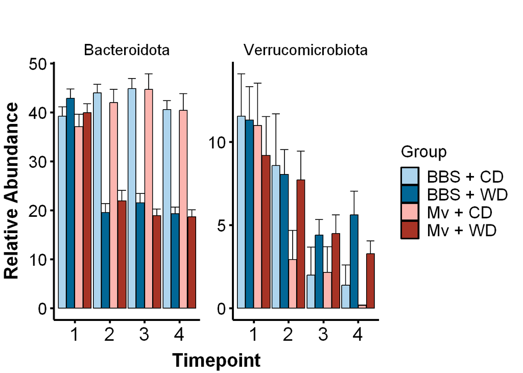

```r
#ggsave("figures/top_phylum_percentT1.png", width = 12, height = 8, units = "in")


ggplot(mb_long, aes(x=Timepoint, y=Relative_Abundance, fill=TreatDiet)) +
  geom_bar(color = "black",
           stat="summary",
           fun = mean,
           position=position_dodge(.95))+
  scale_fill_manual(values = c('#ADD4ED', '#016796', '#FCB5AF', '#A73325'))+
  geom_errorbar(stat="summary",
                fun = mean,
                fun.min = function(X) mean(X),
                fun.max = function(X) mean(X) + std.error(X),
                position=position_dodge(.95)) +
   # set labs
  labs(title= "",
       y = "Relative Abundance",
       x = "Timepoint") +
  # theme
  theme_foundation(base_size = 14, base_family = "arial") +
  theme(
    panel.grid.major = element_blank(),
    panel.grid.minor = element_blank(),
    panel.border = element_blank(),
    panel.background = element_blank(),
    plot.title = element_text(face = "bold",
                              size = 22, hjust = 0.5),
    axis.line = element_line(linewidth = 1),
    axis.ticks = element_line(linewidth = 1),
    axis.title = element_text(face = "bold", size = rel(1)),
    axis.title.y = element_text(angle = 90, vjust = 2, size=18),
    axis.title.x = element_text(vjust = -0.2, size=18),
    axis.text = element_text(size = 14),
    axis.text.x = element_text(size = 18),
    axis.text.y = element_text(size = 16),
    plot.background = element_blank(),
    legend.title=element_text(size=16),
    strip.background = element_blank(),
    strip.text = element_text(size = 15),
    legend.text=element_text(size=16)) +
  guides(fill=guide_legend(title="Group")) +
  facet_wrap(~Phylum, scales = "free")
```

```r
#ggsave("figures/top_phylum.png", width = 12, height = 8, units = "in")
```

### ANCOM SCNIC level

SCNIC code completed using Mac terminal on Lowry lab Macbook.

```r
taxonomy <- read_qza("data/taxonomy-silva.qza")$data
tax.map <- taxonomy$Taxon
names(tax.map) <- taxonomy$Feature.ID

metadata <- read_q2metadata("data/hf_meta_weights.tsv")
rownames(metadata) <- metadata$SampleID

all_mods <- read_q2biom("modules_output/collapsed.biom")
mods <- all_mods[369:422,] # only keep modules

p.mods <- phyloseq(otu_table(mods, taxa_are_rows=T),
                  sample_data(metadata))

# Run ANCOM BC
if (file.exists("ancom/ancom_mods.rds")) {
  ancom.mods <- readRDS("ancom/ancom_mods.rds")
} else {
  ancom.mods <- ancombc2(data=p.mods,
                              fix_formula="Timepoint+Treatment+Diet+Weight_group",
                              rand_formula="(1|Mouse)",
                              p_adj_method="fdr")
  saveRDS(ancom.mods, "ancom/ancom_mods.rds")
}


# get results
res <- ancom.mods$res
```

#### SCNIC: Interactions

```r
taxonomy <- read_qza("data/taxonomy-silva.qza")$data
tax.map <- taxonomy$Taxon
names(tax.map) <- taxonomy$Feature.ID

metadata <- read_q2metadata("data/metadata_interactions.tsv")
rownames(metadata) <- metadata$SampleID

all_mods <- read_q2biom("modules_output/collapsed.biom")
mods <- all_mods[369:422,] # only keep modules

p.mods <- phyloseq(otu_table(mods, taxa_are_rows=T),
                  sample_data(metadata))

# Run ANCOM BC
if (file.exists("ancom/ancom_mods_ix.rds")) {
  ancom.mods <- readRDS("ancom/ancom_mods_ix.rds")
} else {
  ancom.mods <- ancombc2(data=p.mods,
                              fix_formula="Treatment + Diet + Timepoint + TreatDiet + TreatTime + DietTime + TreatDietTime",
                              rand_formula="(1|Mouse)",
                              p_adj_method="fdr")
  saveRDS(ancom.mods, "ancom/ancom_mods_ix.rds")
}

# get results
res <- ancom.mods$res

# make table
res[order(res$`q_DietTime3`),] %>%
    select(taxon,
           lfc_Timepoint3,
           q_Timepoint3,
           lfc_Diet1,
           q_Diet1,
           lfc_DietTime3,
           q_DietTime3,
           lfc_TreatDietTime3,
           q_TreatDietTime3) %>%
    DT::datatable()
```

|  | taxon | lfc_Timepoint3 | q_Timepoint3 | lfc_Diet1 | q_Diet1 | lfc_DietTime3 | q_DietTime3 | lfc_TreatDietTime3 | q_TreatDietTime3 |
| --- | --- | --- | --- | --- | --- | --- | --- | --- | --- |
| 4 | module_3 | -0.04010665173705157 | 1 | 0.07808958706096324 | 1 | 3.257942077169591 | 3.946686961699529e-07 | 0.1284492975981902 | 1 |
| 5 | module_4 | 0.130579913979637 | 0.9743550320586299 | 0.5003188532339012 | 1 | 3.335133379490246 | 6.711802615909841e-05 | 0.02866331581729809 | 1 |
| 36 | module_36 | -0.6830592184131183 | 0.4528232155267676 | -0.7660738919873235 | 1 | 3.426646836553528 | 0.0001960283495692379 | -1.195752744342315 | 1 |
| 1 | module_0 | 0.5739597779201782 | 0.6986523411879748 | -0.4219292447765374 | 1 | -3.711953662723105 | 0.0006389744241150342 | -1.196219366663184 | 1 |
| 39 | module_39 | 0.2408091809880502 | 0.9400572451412301 | 0.4882915732020769 | 1 | 3.041356470035014 | 0.0009767750005829246 | 0.5531428058909326 | 1 |
| 49 | module_50 | -1.125926764890882 | 0.2659142037426808 | 2.550449533223949 | 0.3415814856850454 | -3.326897448435446 | 0.001578091979590037 | 0 | 1 |
| 7 | module_6 | -0.22077604239982 | 0.9473008104792079 | -0.812531773909859 | 1 | 3.612427653355854 | 0.001716327602285342 | -0.500142926384985 | 1 |
| 12 | module_11 | -1.5410313437014 | 0.008903818966964655 | -0.1563164289509891 | 1 | -3.431526763828748 | 0.002721167023132815 | 0 | 1 |
| 26 | module_26 | 0.002025231371616892 | 1 | -0.5019026368425388 | 1 | 2.089386922265381 | 0.007750863735639322 | -0.9352516370707928 | 1 |
| 3 | module_2 | -0.7291438752575167 | 0.303399290194087 | 0.5037757032522869 | 1 | -1.857499219232458 | 0.009214757741033197 | 0.7175271460547854 | 1 |

[output cut: 42 more lines]

```r
#write.csv(res, "ancom/scnic_ancom.csv", row.names=F)
# modules 3, 4, 36, 0, 39, 50, 6, and 11 were significant for DietTime3
# where LFC > |3| and q < .05
```

#### SCNIC: Sleuthing

Run code above first, probably

```r
# Code by Sundar Dorai-Raj: reading asymmetrical tables
## read in the file to determine the max number of columns
x <- scan("modules_output/modules.txt", what = "", sep = "\n")
x <- strsplit(x, "[ \t]+") # split string by white space
max.col <- max(sapply(x, length))

## option 1
## specify col.names as ?read.table suggests
cn <- paste("V", 1:max.col, sep = "")
mod_table <- read.table("modules_output/modules.txt",
                        fill = TRUE,
                        col.names = cn)

# barcodes to full name
for (row in 1:nrow(mod_table)){
  for (col in 1:ncol(mod_table)){
    barcode <- mod_table[row, col]
    ifelse(is.na(tax.map[barcode]) == FALSE,
           mod_table[row, col] <- tax.map[barcode],
           mod_table[row, col] <- mod_table[row, col])
  }
}

#write.csv(mod_table, "data/modules_silva.csv", row.names = F)

rownames(mod_table) <- mod_table$V1
mod_table <- select(mod_table, -V1)

# make list of names
name_list <- list()
for (row in 1:nrow(mod_table)){
  rname <- rownames(mod_table)[row]
  col.list <- mod_table[row,]
  emptycols <- colSums(col.list == "") == nrow(col.list)
  col.list<- col.list[!emptycols]
  col.list <- unlist(col.list, use.names = F)
  cl2 <- paste(col.list, collapse = "; ")
  name_list[row] <- cl2
}

name_df <- mod_table
name_df$names <- name_list
name_df <- select(name_df, names)

# add names to results df
rownames(res) <- res$taxon

name_list <- list()
for (row in 1:nrow(res)){
  rname <- rownames(res[row,])
  name_list[row] <- unlist(name_df[rname,])
}

res$names <- name_list
```

#### SCNIC: Plotting

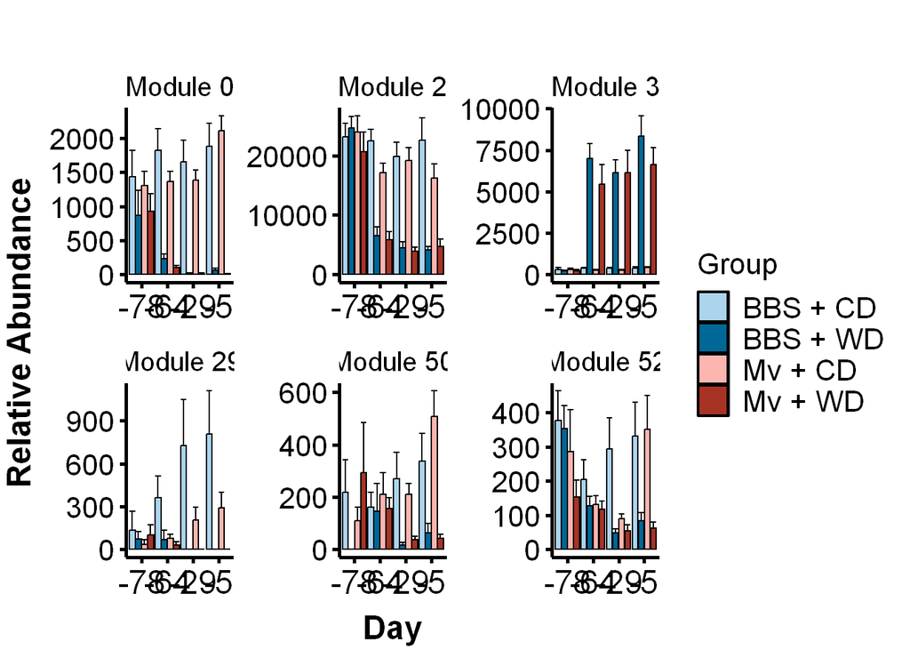

```r
# top hits based on DietTime1, DietTime2, DietTime3
metadata <- read_q2metadata("data/hf_meta_weights.tsv")
rownames(metadata) <- metadata$SampleID

res_top <- filter(res,
                  q_DietTime1 < .05,
                  q_DietTime2 < .05,
                  q_DietTime3 < .05)

res_top$taxon <- as.factor(res_top$taxon)
# res_top$taxon <- fct_recode(res_top$taxon,
#                             "0" = "module_0",
#                             "2" = "module_2",
#                             "3" = "module_3",
#                             "29" = "module_29",
#                             "50" = "module_50",
#                             "52" = "module_52")
#
# res_top$taxon <- fct_relevel(res_top$taxon,
#                              c("0", "2", "3",
#                                "29", "50", "52"))


mod_meta <- as.data.frame(t(mods))

mod_meta <- merge(metadata, mod_meta,
                  by = "row.names",
                  all = TRUE)

rownames(mod_meta) <- mod_meta$Row.names
mod_meta <- mod_meta[,-1]

mod_meta_l <- pivot_longer(mod_meta,
                           cols = c(12:65),
                           names_to = "Module",
                           values_to = "Abundance")

mod_meta_l$Module <- as.factor(mod_meta_l$Module)


mod_meta_l <- mod_meta_l[mod_meta_l$Module %in% res_top$taxon,]
mod_meta_l$Timepoint <- fct_recode(mod_meta_l$Timepoint,
                                   "-78" = "1",
                                   "-64" = "2",
                                   "-29" = "3",
                                   "-5" = "4")

mod_meta_l$Module <- fct_recode(mod_meta_l$Module,
                                "Module 0" = "module_0",
                                "Module 2" = "module_2",
                                "Module 3" = "module_3",
                                "Module 29" = "module_29",
                                "Module 50" = "module_50",
                                "Module 52" = "module_52")

mod_meta_l$Module <- fct_relevel(mod_meta_l$Module,
                               c("Module 0","Module 2",
                                "Module 3", "Module 29",
                                "Module 50", "Module 52"))

ggplot(mod_meta_l, aes(x=Timepoint, y=Abundance, fill=TreatDiet)) +
  geom_bar(color = "black",
           stat="summary",
           fun = mean,
           position=position_dodge(.95))+
  scale_fill_manual(values = c('#ADD4ED', '#016796', '#FCB5AF', '#A73325'))+
  geom_errorbar(stat="summary",
                fun = mean,
                fun.min = function(X) mean(X),
                fun.max = function(X) mean(X) + std.error(X),
                position=position_dodge(.95)) +
   # set labs
  labs(title= "",
       y = "Relative Abundance",
       x = "Day") +
  # theme
  theme_foundation(base_size = 14, base_family = "arial") +
  theme(
    panel.grid.major = element_blank(),
    panel.grid.minor = element_blank(),
    panel.border = element_blank(),
    panel.background = element_blank(),
    plot.title = element_text(face = "bold",
                              size = 22, hjust = 0.5),
    axis.line = element_line(linewidth = 1),
    axis.ticks = element_line(linewidth = 1),
    axis.title = element_text(face = "bold", size = rel(1)),
    axis.title.y = element_text(angle = 90, vjust = 2, size=18),
    axis.title.x = element_text(vjust = -0.2, size=18),
    axis.text = element_text(size = 14),
    axis.text.x = element_text(size = 18),
    axis.text.y = element_text(size = 16),
    plot.background = element_blank(),
    legend.title=element_text(size=16),
    strip.background = element_blank(),
    strip.text = element_text(size = 15),
    legend.text=element_text(size=16)) +
  guides(fill=guide_legend(title="Group")) +
  facet_wrap(~Module, scales = "free")
```

```r
#ggsave("figures/modules_diettime1-4.png", width = 10, height = 8, units = "in")
#
# top_mods_taxa <- mod_table[rownames(mod_table) %in% rownames(res_top),]
#
# #write.csv(top_mods_taxa, "data/module_bacteria.csv", row.names = TRUE)
```

## Volatility

```r
w_uni <- read_qza("cd_new_results/weighted_unifrac_distance_matrix.qza")$data
u_uni <- read_qza("cd_new_results/unweighted_unifrac_distance_matrix.qza")$data

metadata <- read_q2metadata("data/hf_meta_weights.tsv")
rownames(metadata) <- metadata$SampleID
metadata$TreatDiet <- paste(metadata$Treatment, metadata$Diet, sep = " - ")
metadata$TreatDiet <- as.factor(metadata$TreatDiet)

volatility <- matrix(ncol=6)

for (id in 1:length(levels(metadata$Mouse))){
    mouse <- levels(metadata$Mouse)[id]
    temp_df <- metadata[metadata$Mouse==mouse,]
    diet <- as.character(temp_df$Diet[[1]])
    treat <- as.character(temp_df$Treatment[[1]])
    # get distances
    t1 <- rownames(temp_df)[1]
    t2 <- rownames(temp_df)[2]
    t3 <- rownames(temp_df)[3]
    t4 <- rownames(temp_df)[4]
    dist.w12 <- dist_get(w_uni, t1, t2)
    dist.u12 <- dist_get(u_uni, t1, t2)

    dist.w13 <- dist_get(w_uni, t1, t3)
    dist.u13 <- dist_get(u_uni, t1, t3)

    dist.w14 <- dist_get(w_uni, t1, t4)
    dist.u14 <- dist_get(u_uni, t1, t4)

    volatility <- rbind(volatility,
                        c(mouse, "1v2", diet, treat, dist.w12, dist.u12))

    volatility <- rbind(volatility,
                        c(mouse, "1v3", diet, treat, dist.w13, dist.u13))

    volatility <- rbind(volatility,
                        c(mouse, "1v4", diet, treat, dist.w14, dist.u14))
}

# for (id in 1:length(levels(metadata$Mouse))){
#     mouse <- levels(metadata$Mouse)[id]
#     temp_df <- metadata[metadata$Mouse==mouse,]
#     diet <- as.character(temp_df$Diet[[1]])
#     treat <- as.character(temp_df$Treatment[[1]])
#     # get distances
#     t1 <- rownames(temp_df)[1]
#     t2 <- rownames(temp_df)[2]
#     t3 <- rownames(temp_df)[3]
#     t4 <- rownames(temp_df)[4]
#     dist.w12 <- dist_get(w_uni, t1, t2)
#     dist.u12 <- dist_get(u_uni, t1, t2)
#
#     dist.w23 <- dist_get(w_uni, t2, t3)
#     dist.u23 <- dist_get(u_uni, t2, t3)
#
#     dist.w34 <- dist_get(w_uni, t3, t4)
#     dist.u34 <- dist_get(u_uni, t3, t4)
#
#     volatility <- rbind(volatility,
#                         c(mouse, "1-2", diet, treat, dist.w12, dist.u12))
#
#     volatility <- rbind(volatility,
#                         c(mouse, "2-3", diet, treat, dist.w23, dist.u23))
#
#     volatility <- rbind(volatility,
#                         c(mouse, "3-4", diet, treat, dist.w34, dist.u34))
# }

volatility <- volatility[2:nrow(volatility),]
volatility <- as.data.frame(volatility)

colnames(volatility) <- c("Mouse",
                          "Time_Compare",
                          "Diet",
                          "Treatment",
                          "W_Uni_Dist",
                          "U_Uni_Dist")

volatility$W_Uni_Dist <- as.numeric(volatility$W_Uni_Dist)
volatility$U_Uni_Dist <- as.numeric(volatility$U_Uni_Dist)
volatility$Time_Compare <- as.factor(volatility$Time_Compare)

volatility$Diet <- as.factor(volatility$Diet)
volatility$Treatment <- as.factor(volatility$Treatment)
volatility$Mouse <- as.factor(volatility$Mouse)
volatility$TreatDiet <- paste(volatility$Treatment,
                              volatility$Diet, sep = " - ")
volatility$TreatDiet <- as.factor(volatility$TreatDiet)

# model volatility
mw <- lme(W_Uni_Dist ~ Time_Compare * Diet * Treatment,
         random = ~ Time_Compare | Mouse,
         data=volatility)

summary(mw)
```

```
## Linear mixed-effects model fit by REML
##   Data: volatility
##         AIC       BIC   logLik
##   -101.8723 -48.44077 69.93614
##
## Random effects:
##  Formula: ~Time_Compare | Mouse
##  Structure: General positive-definite, Log-Cholesky parametrization
##                 StdDev     Corr
## (Intercept)     0.12050640 (Intr) Tm_C13
## Time_Compare1v3 0.09373976 -0.413
## Time_Compare1v4 0.14128374 -0.475  0.495
## Residual        0.05313001
##
## Fixed effects:  W_Uni_Dist ~ Time_Compare * Diet * Treatment
##                                                Value  Std.Error DF   t-value
## (Intercept)                                0.4437671 0.03801819 82 11.672495
## Time_Compare1v3                            0.0656281 0.03468037 82  1.892370
## Time_Compare1v4                            0.0750404 0.04619406 82  1.624460
## DietWD                                     0.3336200 0.05376584 41  6.205055
## TreatmentM. vaccae                         0.0326793 0.05639009 41  0.579521
## Time_Compare1v3:DietWD                    -0.0248452 0.04904546 82 -0.506575
## Time_Compare1v4:DietWD                     0.0010989 0.06532826 82  0.016821
## Time_Compare1v3:TreatmentM. vaccae        -0.0482920 0.05143931 82 -0.938815
## Time_Compare1v4:TreatmentM. vaccae        -0.0214726 0.06851686 82 -0.313392
## DietWD:TreatmentM. vaccae                 -0.0680545 0.07875281 41 -0.864154
## Time_Compare1v3:DietWD:TreatmentM. vaccae  0.0629514 0.07183869 82  0.876288
## Time_Compare1v4:DietWD:TreatmentM. vaccae  0.0469665 0.09568872 82  0.490825
##                                           p-value
## (Intercept)                                0.0000
## Time_Compare1v3                            0.0620
## Time_Compare1v4                            0.1081
## DietWD                                     0.0000
## TreatmentM. vaccae                         0.5654
## Time_Compare1v3:DietWD                     0.6138
## Time_Compare1v4:DietWD                     0.9866
## Time_Compare1v3:TreatmentM. vaccae         0.3506
## Time_Compare1v4:TreatmentM. vaccae         0.7548
## DietWD:TreatmentM. vaccae                  0.3925
## Time_Compare1v3:DietWD:TreatmentM. vaccae  0.3834
```

[output cut: 30 more lines]

```
## TreatmentM. vaccae
## Time_Compare1v3:DietWD
## Time_Compare1v4:DietWD
## Time_Compare1v3:TreatmentM. vaccae
## Time_Compare1v4:TreatmentM. vaccae
## DietWD:TreatmentM. vaccae
## Time_Compare1v3:DietWD:TreatmentM. vaccae -0.473
## Time_Compare1v4:DietWD:TreatmentM. vaccae -0.518  0.488
##
## Standardized Within-Group Residuals:
##         Min          Q1         Med          Q3         Max
## -1.22127631 -0.29361514  0.01016164  0.31183110  1.25325716
##
## Number of Observations: 135
## Number of Groups: 45
```

```r
mu <- lme(U_Uni_Dist ~ Time_Compare * Diet * Treatment,
         random = ~ Time_Compare | Mouse,
         data=volatility)

summary(mu)
```

```
## Linear mixed-effects model fit by REML
##   Data: volatility
##         AIC       BIC   logLik
##   -325.2449 -271.8134 181.6224
##
## Random effects:
##  Formula: ~Time_Compare | Mouse
##  Structure: General positive-definite, Log-Cholesky parametrization
##                 StdDev     Corr
## (Intercept)     0.07125744 (Intr) Tm_C13
## Time_Compare1v3 0.04002377 -0.041
## Time_Compare1v4 0.04724373  0.146  0.887
## Residual        0.01918143
##
## Fixed effects:  U_Uni_Dist ~ Time_Compare * Diet * Treatment
##                                                Value  Std.Error DF   t-value
## (Intercept)                                0.3359871 0.02130248 82 15.772201
## Time_Compare1v3                            0.0372063 0.01395754 82  2.665676
## Time_Compare1v4                            0.0583247 0.01572637 82  3.708717
## DietWD                                     0.0920784 0.03012626 41  3.056415
## TreatmentM. vaccae                         0.0074152 0.03159669 41  0.234683
## Time_Compare1v3:DietWD                     0.0112678 0.01973895 82  0.570840
## Time_Compare1v4:DietWD                    -0.0135534 0.02224045 82 -0.609405
## Time_Compare1v3:TreatmentM. vaccae        -0.0083758 0.02070238 82 -0.404582
## Time_Compare1v4:TreatmentM. vaccae        -0.0333128 0.02332598 82 -1.428144
## DietWD:TreatmentM. vaccae                 -0.0425660 0.04412705 41 -0.964623
## Time_Compare1v3:DietWD:TreatmentM. vaccae  0.0000909 0.02891237 82  0.003143
## Time_Compare1v4:DietWD:TreatmentM. vaccae  0.0372847 0.03257640 82  1.144530
##                                           p-value
## (Intercept)                                0.0000
## Time_Compare1v3                            0.0093
## Time_Compare1v4                            0.0004
## DietWD                                     0.0039
## TreatmentM. vaccae                         0.8156
## Time_Compare1v3:DietWD                     0.5697
## Time_Compare1v4:DietWD                     0.5439
## Time_Compare1v3:TreatmentM. vaccae         0.6868
## Time_Compare1v4:TreatmentM. vaccae         0.1570
## DietWD:TreatmentM. vaccae                  0.3404
## Time_Compare1v3:DietWD:TreatmentM. vaccae  0.9975
```

[output cut: 30 more lines]

```
## TreatmentM. vaccae
## Time_Compare1v3:DietWD
## Time_Compare1v4:DietWD
## Time_Compare1v3:TreatmentM. vaccae
## Time_Compare1v4:TreatmentM. vaccae
## DietWD:TreatmentM. vaccae
## Time_Compare1v3:DietWD:TreatmentM. vaccae -0.136
## Time_Compare1v4:DietWD:TreatmentM. vaccae  0.030  0.776
##
## Standardized Within-Group Residuals:
##         Min          Q1         Med          Q3         Max
## -1.41190172 -0.32307879  0.01266414  0.34199521  1.34173580
##
## Number of Observations: 135
## Number of Groups: 45
```

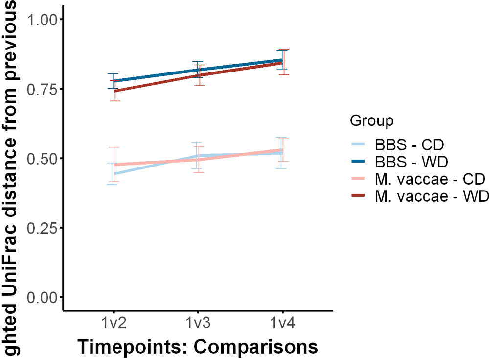

```r
# for error bars
v_stats <- aggregate(W_Uni_Dist ~ TreatDiet + Time_Compare, volatility, mean)
v_SEM <- aggregate(W_Uni_Dist ~ TreatDiet + Time_Compare, volatility, FUN = sem)
v_stats$SEM <- v_SEM$W_Uni_Dist

ggplot(data=v_stats,
       mapping=aes(x=Time_Compare, y=W_Uni_Dist,
                   group=TreatDiet, color = TreatDiet)) +
  geom_line(size = 1.5) +
  geom_errorbar(aes(ymin=W_Uni_Dist-SEM, ymax=W_Uni_Dist+SEM), width=.5,
                 position=position_dodge(0.05)) +

 # stat_smooth() +
  ylab("Weighted UniFrac distance from previous sample") +
  xlab("Timepoints: Comparisons") +
  ylim(0,1) +
  scale_color_manual(values = c('#ADD4ED', '#016796', '#FCB5AF', '#A73325')) +
 theme(
    panel.grid.major = element_blank(),
    panel.grid.minor = element_blank(),
    panel.border = element_blank(),
    panel.background = element_blank(),
    text = element_text(colour = "black"),
    plot.title = element_text(face = "bold",
                              size = 20, hjust = 0.5),
    axis.line = element_line(colour="black", size = 1),
    axis.ticks = element_line(colour="black", size = 1),
    axis.title = element_text(face = "bold", size = rel(1)),
    axis.title.y = element_text(angle = 90, vjust = 2, size=20),
    axis.title.x = element_text(vjust = -0.2, size = 20),
    axis.text = element_text(size = 16),
    axis.text.x = element_text(size = 16),
    axis.text.y = element_text(size = 16),
    plot.background = element_blank(),
    strip.background = element_blank(),
    strip.text.x = element_text(size=16),
    legend.title=element_text(size=16),
    legend.text=element_text(size=16),
    legend.key=element_blank()) +
  guides(color = guide_legend(title="Group"))
```

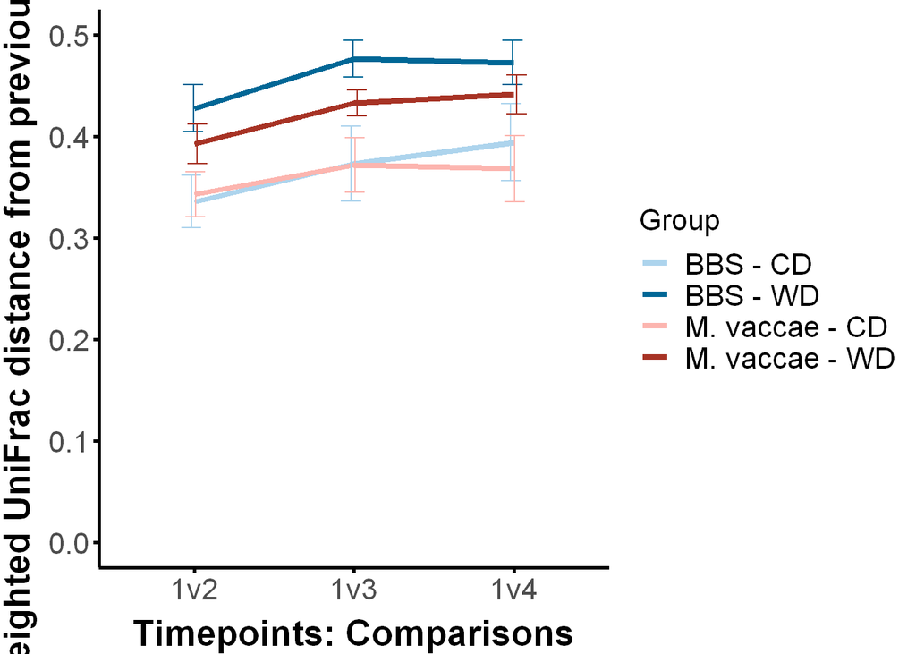

```r
#ggsave("figures/volatility_w_uni.png", width = 11, height = 8, units = "in")


vu_stats <- aggregate(U_Uni_Dist ~ TreatDiet + Time_Compare, volatility, mean)
vu_SEM <- aggregate(U_Uni_Dist ~ TreatDiet + Time_Compare, volatility, FUN = sem)
vu_stats$SEM <- vu_SEM$U_Uni_Dist

ggplot(data=vu_stats,
       mapping=aes(x=Time_Compare, y=U_Uni_Dist,
                   group=TreatDiet, color = TreatDiet)) +
  geom_line(size = 1.5) +
  geom_errorbar(aes(ymin=U_Uni_Dist-SEM, ymax=U_Uni_Dist+SEM), width=.5,
                 position=position_dodge(0.05)) +

 # stat_smooth() +
  ylab("Unweighted UniFrac distance from previous sample") +
  xlab("Timepoints: Comparisons") +
  ylim(0,.5) +
  scale_color_manual(values = c('#ADD4ED', '#016796', '#FCB5AF', '#A73325')) +
 theme(
    panel.grid.major = element_blank(),
    panel.grid.minor = element_blank(),
    panel.border = element_blank(),
    panel.background = element_blank(),
    text = element_text(colour = "black"),
    plot.title = element_text(face = "bold",
                              size = 20, hjust = 0.5),
    axis.line = element_line(colour="black", size = 1),
    axis.ticks = element_line(colour="black", size = 1),
    axis.title = element_text(face = "bold", size = rel(1)),
    axis.title.y = element_text(angle = 90, vjust = 2, size=20),
    axis.title.x = element_text(vjust = -0.2, size = 20),
    axis.text = element_text(size = 16),
    axis.text.x = element_text(size = 16),
    axis.text.y = element_text(size = 16),
    plot.background = element_blank(),
    strip.background = element_blank(),
    strip.text.x = element_text(size=16),
    legend.title=element_text(size=16),
    legend.text=element_text(size=16),
    legend.key=element_blank()) +
  guides(color = guide_legend(title="Group"))
```

```r
#ggsave("figures/volatility_un_uni.png", width = 11, height = 8, units = "in")

#write.csv(volatility, "data/volatility2.csv", row.names=FALSE)
```

# Taxa barplot by John Sterrett

## Load data

```r
# reorder metadata before it's read into philoseq
# since IDs were out of order
# RUN ONLY ONCE

# meta <- read_q2metadata("data/hf_meta_weights.tsv")
# m_csv <- read_csv("data/hf_meta_weights.csv")
#
# meta$Mouse <- as.numeric(as.character(meta$Mouse))
#
# meta2 <- meta[order(meta$Mouse),]
# meta2 <- rbind(m_csv[1,], meta2)
#
#write.table(meta2, file = "data/hf_meta_weights.tsv", row.names=FALSE, sep="\t", quote = F)
# write.csv(meta2, "data/hf_meta_weights.csv", row.names = FALSE)

# load pseq
pseq <- qiime2R::qza_to_phyloseq(feature="data/hf_table.qza",
                                 taxonomy="data/taxonomy-silva.qza",
                                 metadata="data/hf_meta_weights.tsv")



taxonomy.table <- pseq %>% tax_table() %>% as.data.frame()
```

## Microshades

```r
# customized for our metadata

my_plot_microshades <- function(mdf_group,
                                cdf,
                                group_label = "Phylum Genus",
                                x = "Sample",
                                y = "Abundance")
{
  if (class(mdf_group) != "data.frame")
  {
    stop("mdf_group argument must be a data frame")
  }

  if(any(is.na(cdf$hex) | is.na(cdf$group)))
  {
    stop("cdf does not contain complete color information - missing hex or group info")
  }

  plot <- mdf_group %>%

    # SPECIFIC TO HFD PROJECT
    mutate(Sample = fct_reorder(Sample, as.numeric(as.character(Mouse)))) %>%

    ggplot(aes_string(x = x, y = y), fill = group_label) +
    scale_fill_manual(name = group_label,
                      values = cdf$hex,
                      breaks = cdf$group) +
    scale_colour_manual(name = group_label,
                        values = cdf$hex,
                        breaks = cdf$group) +
    geom_bar(aes(color=group, fill=group), stat="identity", position="stack") +
    theme(axis.text.x = element_text(angle = 45, hjust = 1))

  plot
}


make_microshades_phylum <- function(pseq, subgroup){
    # prep the microshades colors
    mdf_prep <- prep_mdf(pseq, subgroup_level=subgroup)
    # sort the phylum names
    phylum_table <- tax_glom(pseq, taxrank="Phylum", ) %>% otu_table()
    phyla.otunames <- rownames(phylum_table)

    phylums <- taxonomy.table[phyla.otunames,"Phylum"]

    sorted_phylums <- phylums[order(rowSums(phylum_table), decreasing=T)]
    # create the colors object
    color_objs_GP <- create_color_dfs(mdf_prep,
                                      selected_groups=sorted_phylums[5:1],
                                      cvd = TRUE, subgroup_level=subgroup)
    # Extract
    mdf_GP <- color_objs_GP$mdf
    cdf_GP <- color_objs_GP$cdf

    # create a custom legend
    GP_legend <-custom_legend(mdf_GP, cdf_GP,
                              legend_key_size=unit(0.4, "cm"),
                              legend_text_size=10, subgroup_level=subgroup)

    # plot
    plot <- my_plot_microshades(mdf_GP, cdf_GP)
    plot_1 <- plot + scale_y_continuous(labels = scales::percent,
                                        expand = expansion(0)) +

      theme(legend.position = "none")  +
      #theme(axis.text.x = element_blank()) +
      facet_grid(~Timepoint + TreatDiet, scales="free_x", space="free_x"
                 )

    multi <- plot_grid(plot_1, GP_legend,  rel_widths = c(1, .25))
    multi
}
```

## Phylum -> Family

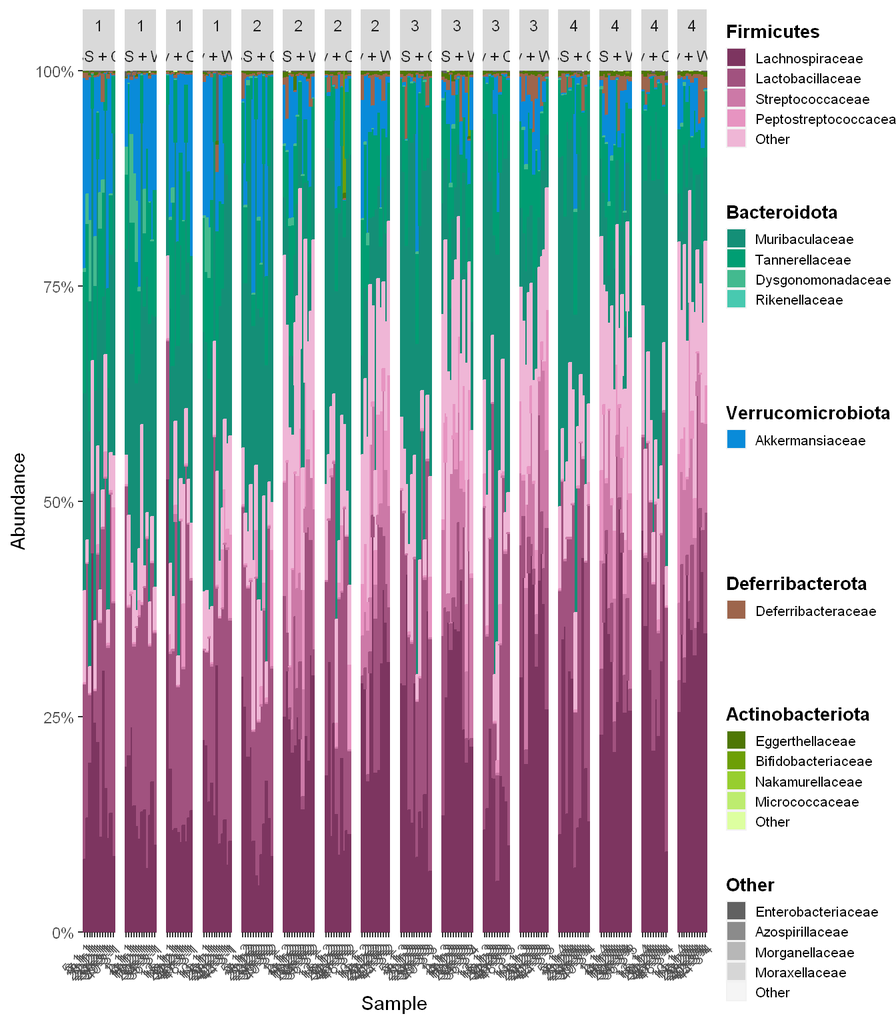

# PhILR

Package By Justin Silverman: https://bioconductor.org/packages/release/bioc/vignettes/philr/inst/doc/philr-intro.html PhILR is short for “Phylogenetic Isometric Log-Ratio Transform.” This determines the parts of a phylogenetic tree that relate to your outcome, AKA ”balance tree analysis.

Code help: John Sterrett https://github.com/sterrettJD/Phadtare-IBS/blob/main/PhILR.Rmd

```r
pseq <- qiime2R::qza_to_phyloseq(features="data/hf_weights_table.qza",
                         taxonomy="data/taxonomy-silva.qza",
                         tree="data/insertion-tree.qza",
                         metadata="data/metadata_interactions.tsv")
```

[output not shown]

[output not shown]

[output not shown]

[output not shown]

[output not shown]

[output not shown]

[output not shown]

[output not shown]

[output not shown]

[output not shown]

[output not shown]

[output not shown]

[output not shown]

[output not shown]

```r
# Filter low-abundance ASVs
orig.asvs <- nrow(otu_table(pseq))
# keep only the ASVs found in more than 10% of samples

pseq.filt <- filter_taxa(pseq,
                         function(x) sum(x>0) > (0.1*length(x)),
                         prune=T
                         )
```

```
## Found more than one class "phylo" in cache; using the first, from namespace 'phyloseq'
## Also defined by 'tidytree'
```

```r
presence.filt.remaining <- nrow(otu_table(pseq.filt))

# keep only the ASVs that we have at least 100 reads of
pseq.filt <- filter_taxa(pseq.filt,
                         function(x) sum(x) > 100,
                         prune=T
                         )
```

```
## Found more than one class "phylo" in cache; using the first, from namespace 'phyloseq'
## Also defined by 'tidytree'
```

```r
phylo.filt.final.remaining <- nrow(otu_table(pseq.filt))

# filter taxa that aren't very variable
pseq.filt <- filter_taxa(pseq.filt,
                         function(x) sd(x)/mean(x) > 3.0,
                         prune=T
                         )
```

```
## Found more than one class "phylo" in cache; using the first, from namespace 'phyloseq'
## Also defined by 'tidytree'
```

```r
phylo.filt.final.remaining.variable <- nrow(otu_table(pseq.filt))

cat(paste("Original features:", orig.asvs,
            "\nAfter first filtering step:", presence.filt.remaining,
            "\nAfter second filtering step:", phylo.filt.final.remaining,
            "\nAfter third (variability) filtering step:", phylo.filt.final.remaining.variable))
```

```
## Original features: 526
## After first filtering step: 226
## After second filtering step: 226
## After third (variability) filtering step: 47
```

```r
pseq.filt # check n features
```

```
## phyloseq-class experiment-level object
## otu_table()   OTU Table:          [ 47 taxa and 180 samples ]:
## sample_data() Sample Data:        [ 180 samples by 13 sample variables ]:
## tax_table()   Taxonomy Table:     [ 47 taxa by 7 taxonomic ranks ]:
## phy_tree()    Phylogenetic Tree:  [ 47 tips and 46 internal nodes ]:
## taxa are rows
```

```r
# add pseudocount
temp.tab <- otu_table(pseq.filt) %>% as.data.frame()
temp.tab[temp.tab==0] <- 1
otu_table(pseq.filt) <- otu_table(temp.tab, taxa_are_rows=T)
```

```
## Found more than one class "phylo" in cache; using the first, from namespace 'phyloseq'
## Also defined by 'tidytree'
```

[output not shown]

[output not shown]

[output not shown]

[output not shown]

[output not shown]

[output not shown]

```r
# check there are no zeros
head(otu_table(pseq.filt))
```

```
## OTU Table:          [ 6 taxa and 180 samples ]:
## Taxa are rows
##              `1-1-1` `1-1-2` `1-1-3` `1-1-4` `10-1-1` `10-1-2` `10-1-3` `10-1-4`
## 1 fdfa86ad7…       1       1       1       1        1        5       59       42
## 2 c4b292113…       1       1       1       1        1        1        1        1
## 3 937aa3d1b…     210    1121      21      24       13        1        1        1
## 4 b0dc6907e…      15      14       1       1       25        1        1        1
## 5 ebdd31c2d…     327      27       1       1        1        1        1        1
## 6 6eae09d9b…       1       1       1       1        1       77       79       59
```

```r
# Process tree
if(ape::is.rooted(phy_tree(pseq.filt)) == T){
    "Tree is rooted."
} else {
    "TREE IS NOT ROOTED"
}
```

```
## [1] "Tree is rooted."
```

```r
if(ape::is.binary(phy_tree(pseq.filt)) == T){
    "Tree is binary."
} else {
    "TREE IS NOT BINARY"
}
```

```
## [1] "Tree is binary."
```

```r
# rename nodes to be "n1, n2, ..."
tree <- ape::makeNodeLabel(phy_tree(pseq.filt), method="number", prefix='n')
phy_tree(pseq.filt) <- tree
```

```
## Found more than one class "phylo" in cache; using the first, from namespace 'phyloseq'
## Also defined by 'tidytree'
```

[output not shown]

[output not shown]

[output not shown]

[output not shown]

[output not shown]

[output not shown]

```r
# name a balance to check
name.balance(tree, tax_table(pseq.filt), 'n1')
```

```
## [1] "Phylum_Firmicutes/Genus_Escherichia-Shigella"
```

```r
# create philr object
philr.dat <- philr(otu_table(pseq.filt) %>% t(), # have to transpose the otu table
                  phy_tree(pseq.filt),
                  part.weights='enorm.x.gm.counts',
                  ilr.weights='blw.sqrt')
```

```
## Building Sequential Binary Partition from Tree...
```

```
## Building Contrast Matrix...
```

```
## Transforming the Data...
```

```
## Calculating ILR Weights...
```

## LASSO

Run code above first. Assess balances of PhILR results that associate with the outcome of interest. New packages: glmnet, ggtree

```r
metadata <- sample_data(pseq.filt) %>% as.data.frame()
metadata$Timepoint <- as.double(metadata$Timepoint)

glmmod <- glmnet(x=philr.dat,
                 y=metadata$Timepoint,
                 alpha=1)

# s would need to be switched to 3000 if y is large
# can adjust s until there are 3-10 top results
top.coords <- as.matrix(coef(glmmod, s=1/5))
top.coords <- top.coords[2:length(top.coords),]

top.coords <- top.coords[order(abs(top.coords), decreasing=T)]
top.coords <- top.coords[top.coords != 0]
top.coords.values <- top.coords
top.coords <- names(top.coords)


# get summary stats for selected features regression
m.formula <- paste(top.coords, collapse=" + ")
m.formula <- paste0("metadata$Timepoint ~ ", m.formula)
m <- lm(as.formula(m.formula),
        data=as.data.frame(philr.dat))
summary(m)
```

```
##
## Call:
## lm(formula = as.formula(m.formula), data = as.data.frame(philr.dat))
##
## Residuals:
##     Min      1Q  Median      3Q     Max
## -2.3341 -0.7235 -0.1116  0.6872  2.1338
##
## Coefficients:
##             Estimate Std. Error t value Pr(>|t|)
## (Intercept)  2.50188    0.07255  34.486  < 2e-16 ***
## n27          0.61302    0.11756   5.215 5.18e-07 ***
## n33         -0.32618    0.11729  -2.781  0.00602 **
## n10         -0.06482    0.10743  -0.603  0.54702
## n37         -0.19622    0.13846  -1.417  0.15823
## n3          -0.14096    0.07404  -1.904  0.05860 .
## ---
## Signif. codes:  0 '***' 0.001 '**' 0.01 '*' 0.05 '.' 0.1 ' ' 1
##
## Residual standard error: 0.9542 on 174 degrees of freedom
## Multiple R-squared:  0.2959, Adjusted R-squared:  0.2757
## F-statistic: 14.63 on 5 and 174 DF,  p-value: 5.788e-12
```

```r
# p <- summary(m)$coefficients[,4]
# nodes <- rownames(summary(m)$coefficients)
# np_df <- data.frame("nodes" = nodes,
#                     "p.value" = p)
# np_top <- filter(np_df, p < .05)

tc.names <- sapply(top.coords, function(x) name.balance(phy_tree(pseq.filt), tax_table(pseq.filt), x))
tc.names
```

```
##                                                   n27
##          "Family_Lachnospiraceae/Kingdom_d__Bacteria"
##                                                   n33
##       "Family_Lachnospiraceae/Family_Lachnospiraceae"
##                                                   n10
## "Family_Lachnospiraceae/Species_uncultured_bacterium"
##                                                   n37
##             "Family_Lachnospiraceae/Genus_uncultured"
##                                                    n3
##             "Class_Clostridia/Genus_Colidextribacter"
```

## Tree

```r
tc.nn <- name.to.nn(phy_tree(pseq.filt), top.coords)

tc.colors <- c('#fb9a99',  '#b2df8a', '#33a02c', '#1f78b4', '#a6cee3')


  # geom_cladelabel(node = as.numeric(gsub(".*?([0-9]+).*",
  #                                        "\\1",
  #                                        top.coords[1])) ,
  #                 label = top.coords[1],
  #                 color = "black",
  #                 offset = 0,
  #                 align = TRUE)


p <- ggtree(tree) +
    geom_balance(node=tc.nn[1], fill=tc.colors[1], alpha=0.6) +
    geom_balance(node=tc.nn[2], fill=tc.colors[2], alpha=0.6) +
    geom_balance(node=tc.nn[3], fill=tc.colors[3], alpha=0.6) +
    geom_balance(node=tc.nn[4], fill=tc.colors[4], alpha=0.6) +
    geom_balance(node=tc.nn[5], fill=tc.colors[5], alpha=0.6)
```

```
## Found more than one class "phylo" in cache; using the first, from namespace 'phyloseq'
```

```
## Also defined by 'tidytree'
```

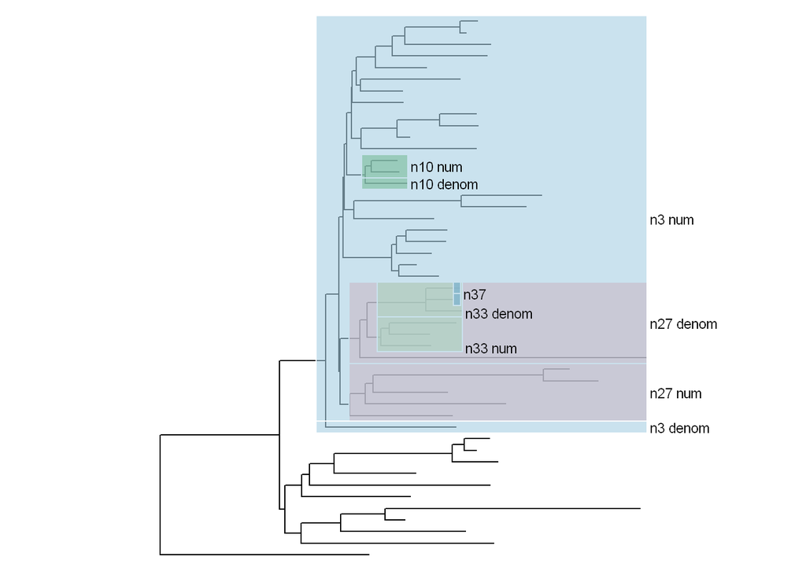

```r
p <- annotate_balance(tr=phy_tree(pseq.filt), coord=top.coords[1],
                 p=p,
                 labels=paste(rep(top.coords[1],2), c("num", "denom")),
                 offset.text=0.01,
                 bar=FALSE,
                 hjust=0,
                 size=3) +
  scale_x_continuous(expand = expansion(mult = 0.3))


p <- annotate_balance(tr=phy_tree(pseq.filt), coord=top.coords[2],
                 p=p,
                 labels=paste(rep(top.coords[2],2), c("num", "denom")),
                 offset.text=0.01, bar=FALSE,
                 hjust=0,
                 vjust=1.7,
                 size=3)


p <- annotate_balance(tr=phy_tree(pseq.filt), coord=top.coords[3],
                 p=p,
                 labels=paste(rep(top.coords[3],2), c("num", "denom")),
                 offset.text=.01, bar=FALSE,
                 hjust=0,
                 size=3)


p <- annotate_balance(tr=phy_tree(pseq.filt), coord=top.coords[4],
                 p=p,
                 #labels=paste(rep(top.coords[4],2), c("num", "denom")),
                 labels=c("","n37"),
                 offset.text=0.01, bar=FALSE,
                 hjust=0,
                 vjust=1,
                 size=3)


p <- annotate_balance(tr=phy_tree(pseq.filt), coord=top.coords[5],
                 p=p,
                 labels=paste(rep(top.coords[5],2), c("num", "denom")),
                 offset.text=.01, bar=FALSE,
                 hjust=0,
                 size=3)


p
```

## Violin plots

```r
philr.long <- convert_to_long(philr.dat,
                              labels=metadata$Timepoint) %>%
  filter(coord %in% top.coords)
```

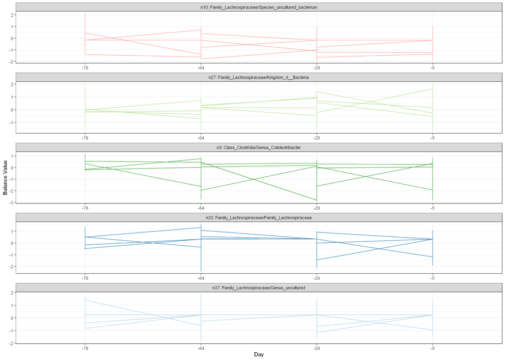

```r
philr.long$coord <- as.factor(philr.long$coord)
philr.long$labels <- as.factor(philr.long$labels)

philr.long$labels <- fct_recode(philr.long$labels,
                                   "-78" = "1",
                                   "-64" = "2",
                                   "-29" = "3",
                                   "-5" = "4")
philr.long$sample <- as.factor(philr.long$sample)

metadata$ID <- rownames(metadata)
philr.long$mouse <- metadata$Mouse[match(philr.long$sample, metadata$ID)]

meta2 <- read_q2metadata("data/hf_meta_weights.tsv")
philr.long$group <- meta2$TreatDiet[match(philr.long$mouse,
                                          metadata$Mouse)]

scatter.labels <- paste(names(tc.names), tc.names, sep=": ")
names(scatter.labels) <- names(tc.names)

p2 <- ggplot(philr.long, aes(x=labels, y=value, fill=coord)) +
  geom_violin(draw_quantiles = c(0.25, 0.5, 0.75)) +
  scale_fill_manual(guide="none", values = c('#fb9a99',  '#b2df8a', '#33a02c', '#1f78b4', '#a6cee3')) +
  facet_wrap(.~coord,
             scales='free', ncol=1,
             labeller=labeller(coord=scatter.labels)) +
  labs(x = 'Day', y = 'Balance Value') +
 # scale_x_continuous(labels = scales::comma) +
  theme_bw()


#philr.long$labels <- as.numeric(as.character(philr.long$labels))

# unsure how best to display data, practice graph below
ggplot(philr.long, aes(x=labels, y=value, color=coord, group=group)) +
  geom_line() +
  scale_color_manual(guide="none", values = c('#fb9a99',  '#b2df8a', '#33a02c', '#1f78b4', '#a6cee3')) +
  facet_wrap(.~coord,
             scales='free', ncol=1,
             labeller=labeller(coord=scatter.labels)) +
  labs(x = 'Day', y = 'Balance Value') +
 # scale_x_continuous(labels = scales::comma) +
  theme_bw()
```

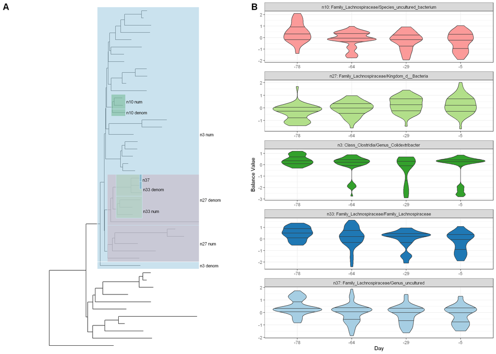

```r
ggarrange(p, p2,
          labels = c("A", "B"),
          font.label = list(size = 18),
          nrow = 1, ncol = 2)
```

```r
#ggsave("figures/timepoint_PhILR.svg", height=10, width=14)
```

## Separate Timepoints

#### PhILR

```r
pseq <- qiime2R::qza_to_phyloseq(features="data/hf_weights_table.qza",
                         taxonomy="data/taxonomy-silva.qza",
                         tree="data/insertion-tree.qza",
                         metadata="data/hf_meta_weights.tsv")
```

[output not shown]

[output not shown]

[output not shown]

[output not shown]

[output not shown]

[output not shown]

[output not shown]

[output not shown]

```r
ps1 <- subset_samples(pseq, Timepoint == "1")
```

```
## Found more than one class "phylo" in cache; using the first, from namespace 'phyloseq'
## Also defined by 'tidytree'
```

[output not shown]

[output not shown]

[output not shown]

[output not shown]

[output not shown]

[output not shown]

```r
ps2 <- subset_samples(pseq, Timepoint == "2")
```

```
## Found more than one class "phylo" in cache; using the first, from namespace 'phyloseq'
## Also defined by 'tidytree'
```

[output not shown]

[output not shown]

[output not shown]

[output not shown]

[output not shown]

[output not shown]

```r
ps3 <- subset_samples(pseq, Timepoint == "3")
```

```
## Found more than one class "phylo" in cache; using the first, from namespace 'phyloseq'
## Also defined by 'tidytree'
```

[output not shown]

[output not shown]

[output not shown]

[output not shown]

[output not shown]

[output not shown]

```r
ps4 <- subset_samples(pseq, Timepoint == "4")
```

```
## Found more than one class "phylo" in cache; using the first, from namespace 'phyloseq'
## Also defined by 'tidytree'
```

[output not shown]

[output not shown]

[output not shown]

[output not shown]

[output not shown]

[output not shown]

```r
# Filter low-abundance ASVs
orig.asvs1 <- nrow(otu_table(ps1))
orig.asvs2 <- nrow(otu_table(ps2))
orig.asvs3 <- nrow(otu_table(ps3))
orig.asvs4 <- nrow(otu_table(ps4))


# keep only the ASVs found in more than 10% of samples
pseq.filt1 <- filter_taxa(ps1,
                         function(x) sum(x>0) > (0.1*length(x)),
                         prune=T)
```

```
## Found more than one class "phylo" in cache; using the first, from namespace 'phyloseq'
## Also defined by 'tidytree'
```

```r
pseq.filt2 <- filter_taxa(ps2,
                         function(x) sum(x>0) > (0.1*length(x)),
                         prune=T)
```

```
## Found more than one class "phylo" in cache; using the first, from namespace 'phyloseq'
## Also defined by 'tidytree'
```

```r
pseq.filt3 <- filter_taxa(ps3,
                         function(x) sum(x>0) > (0.1*length(x)),
                         prune=T)
```

```
## Found more than one class "phylo" in cache; using the first, from namespace 'phyloseq'
## Also defined by 'tidytree'
```

```r
pseq.filt4 <- filter_taxa(ps4,
                         function(x) sum(x>0) > (0.1*length(x)),
                         prune=T)
```

```
## Found more than one class "phylo" in cache; using the first, from namespace 'phyloseq'
## Also defined by 'tidytree'
```

```r
# presence.filt.remaining
pfr1 <- nrow(otu_table(pseq.filt1))
pfr2 <- nrow(otu_table(pseq.filt2))
pfr3 <- nrow(otu_table(pseq.filt3))
pfr4 <- nrow(otu_table(pseq.filt4))

# keep only the ASVs that we have at least 100 reads of
pseq.filt1 <- filter_taxa(pseq.filt1,
                          function(x) sum(x) > 100,
                          prune=T)
```

```
## Found more than one class "phylo" in cache; using the first, from namespace 'phyloseq'
## Also defined by 'tidytree'
```

```r
pseq.filt2 <- filter_taxa(pseq.filt2,
                          function(x) sum(x) > 100,
                          prune=T)
```

```
## Found more than one class "phylo" in cache; using the first, from namespace 'phyloseq'
## Also defined by 'tidytree'
```

```r
pseq.filt3 <- filter_taxa(pseq.filt3,
                          function(x) sum(x) > 100,
                          prune=T)
```

```
## Found more than one class "phylo" in cache; using the first, from namespace 'phyloseq'
## Also defined by 'tidytree'
```

```r
pseq.filt4 <- filter_taxa(pseq.filt4,
                          function(x) sum(x) > 100,
                          prune=T)
```

```
## Found more than one class "phylo" in cache; using the first, from namespace 'phyloseq'
## Also defined by 'tidytree'
```

```r
# phylo.filt.final.remaining
pfinal1 <- nrow(otu_table(pseq.filt1))
pfinal2 <- nrow(otu_table(pseq.filt2))
pfinal3 <- nrow(otu_table(pseq.filt3))
pfinal4 <- nrow(otu_table(pseq.filt4))

# filter taxa that aren't very variable
pseq.filt1 <- filter_taxa(pseq.filt1,
                         function(x) sd(x)/mean(x) > 3.0,
                         prune=T)
```

```
## Found more than one class "phylo" in cache; using the first, from namespace 'phyloseq'
## Also defined by 'tidytree'
```

```r
pseq.filt2 <- filter_taxa(pseq.filt2,
                         function(x) sd(x)/mean(x) > 3.0,
                         prune=T)
```

```
## Found more than one class "phylo" in cache; using the first, from namespace 'phyloseq'
## Also defined by 'tidytree'
```

```r
pseq.filt3 <- filter_taxa(pseq.filt3,
                         function(x) sd(x)/mean(x) > 3.0,
                         prune=T)
```

```
## Found more than one class "phylo" in cache; using the first, from namespace 'phyloseq'
## Also defined by 'tidytree'
```

```r
pseq.filt4 <- filter_taxa(pseq.filt4,
                         function(x) sd(x)/mean(x) > 3.0,
                         prune=T)
```

```
## Found more than one class "phylo" in cache; using the first, from namespace 'phyloseq'
## Also defined by 'tidytree'
```

```r
# phylo.filt.final.remaining.variable
pvari1 <- nrow(otu_table(pseq.filt1))
pvari2 <- nrow(otu_table(pseq.filt2))
pvari3 <- nrow(otu_table(pseq.filt3))
pvari4 <- nrow(otu_table(pseq.filt4))

cat(paste("Original features:", orig.asvs1,
            "\nAfter first filtering step:", pfr1,
            "\nAfter second filtering step:", pfinal1,
            "\nAfter third (variability) filtering step:", pvari1))
```

```
## Original features: 526
## After first filtering step: 203
## After second filtering step: 197
## After third (variability) filtering step: 42
```

```r
cat(paste("Original features:", orig.asvs2,
            "\nAfter first filtering step:", pfr2,
            "\nAfter second filtering step:", pfinal2,
            "\nAfter third (variability) filtering step:", pvari2))
```

```
## Original features: 526
## After first filtering step: 225
## After second filtering step: 219
## After third (variability) filtering step: 30
```

```r
cat(paste("Original features:", orig.asvs3,
            "\nAfter first filtering step:", pfr3,
            "\nAfter second filtering step:", pfinal3,
            "\nAfter third (variability) filtering step:", pvari3))
```

```
## Original features: 526
## After first filtering step: 229
## After second filtering step: 222
## After third (variability) filtering step: 25
```

```r
cat(paste("Original features:", orig.asvs4,
            "\nAfter first filtering step:", pfr4,
            "\nAfter second filtering step:", pfinal4,
            "\nAfter third (variability) filtering step:", pvari4))
```

```
## Original features: 526
## After first filtering step: 247
## After second filtering step: 238
## After third (variability) filtering step: 25
```

```r
# check n features
pseq.filt1
```

```
## phyloseq-class experiment-level object
## otu_table()   OTU Table:          [ 42 taxa and 45 samples ]:
## sample_data() Sample Data:        [ 45 samples by 10 sample variables ]:
## tax_table()   Taxonomy Table:     [ 42 taxa by 7 taxonomic ranks ]:
## phy_tree()    Phylogenetic Tree:  [ 42 tips and 41 internal nodes ]:
## taxa are rows
```

```r
pseq.filt2
```

```
## phyloseq-class experiment-level object
## otu_table()   OTU Table:          [ 30 taxa and 45 samples ]:
## sample_data() Sample Data:        [ 45 samples by 10 sample variables ]:
## tax_table()   Taxonomy Table:     [ 30 taxa by 7 taxonomic ranks ]:
## phy_tree()    Phylogenetic Tree:  [ 30 tips and 29 internal nodes ]:
## taxa are rows
```

```r
pseq.filt3
```

```
## phyloseq-class experiment-level object
## otu_table()   OTU Table:          [ 25 taxa and 45 samples ]:
## sample_data() Sample Data:        [ 45 samples by 10 sample variables ]:
## tax_table()   Taxonomy Table:     [ 25 taxa by 7 taxonomic ranks ]:
## phy_tree()    Phylogenetic Tree:  [ 25 tips and 24 internal nodes ]:
## taxa are rows
```

```r
pseq.filt4
```

```
## phyloseq-class experiment-level object
## otu_table()   OTU Table:          [ 25 taxa and 45 samples ]:
## sample_data() Sample Data:        [ 45 samples by 10 sample variables ]:
## tax_table()   Taxonomy Table:     [ 25 taxa by 7 taxonomic ranks ]:
## phy_tree()    Phylogenetic Tree:  [ 25 tips and 24 internal nodes ]:
## taxa are rows
```

```r
# add pseudocount
temp.tab <- otu_table(pseq.filt1) %>% as.data.frame()
temp.tab[temp.tab==0] <- 1
otu_table(pseq.filt1) <- otu_table(temp.tab, taxa_are_rows=T)
```

[output not shown]

[output not shown]

[output not shown]

[output not shown]

[output not shown]

[output not shown]

[output not shown]

```r
temp.tab <- otu_table(pseq.filt2) %>% as.data.frame()
temp.tab[temp.tab==0] <- 1
otu_table(pseq.filt2) <- otu_table(temp.tab, taxa_are_rows=T)
```

[output not shown]

[output not shown]

[output not shown]

[output not shown]

[output not shown]

[output not shown]

[output not shown]

```r
temp.tab <- otu_table(pseq.filt3) %>% as.data.frame()
temp.tab[temp.tab==0] <- 1
otu_table(pseq.filt3) <- otu_table(temp.tab, taxa_are_rows=T)
```

[output not shown]

[output not shown]

[output not shown]

[output not shown]

[output not shown]

[output not shown]

[output not shown]

```r
temp.tab <- otu_table(pseq.filt4) %>% as.data.frame()
temp.tab[temp.tab==0] <- 1
otu_table(pseq.filt4) <- otu_table(temp.tab, taxa_are_rows=T)
```

[output not shown]

[output not shown]

[output not shown]

[output not shown]

[output not shown]

[output not shown]

[output not shown]

```r
# check there are no zeros
head(otu_table(pseq.filt1))
```

```
## OTU Table:          [ 6 taxa and 45 samples ]:
## Taxa are rows
##                    `1-1-1` `10-1-1` `11-1-1` `12-1-1` `13-1-1` `15-1-1` `16-1-1`
## 1 290ba80f02930a2…       1        1        1        1      229        1        1
## 2 fdfa86ad77b77ca…       1        1        1        1       46       17        1
## 3 c4b2921137c8430…       1        1        1        1       64        1        1
## 4 6206e3841cb68c6…       1        1        1        1       57        7        1
## 5 f9253e649acea99…       1        1        1        1       56        1        1
## 6 a5a514983b20921…       1        1        1        1        1        1        1
```

```r
head(otu_table(pseq.filt2))
```

```
## OTU Table:          [ 6 taxa and 45 samples ]:
## Taxa are rows
##                    `1-1-2` `10-1-2` `11-1-2` `12-1-2` `13-1-2` `15-1-2` `16-1-2`
## 1 937aa3d1b6bf848…    1121        1       41       40        1        1        1
## 2 ebdd31c2ddfb856…      27        1        1        1        1        1        1
## 3 40e88e4f490958e…       1        1        1        1        1        1        1
## 4 6eae09d9bfeca35…       1       77      934        1        1        1        1
## 5 f4257ddd8c71c02…       1        1        1        1        1        1        1
## 6 fe9e2b5e97b5f26…       1        1        1        1        1        1        1
```

```r
head(otu_table(pseq.filt3))
```

```
## OTU Table:          [ 6 taxa and 45 samples ]:
## Taxa are rows
##                    `1-1-3` `10-1-3` `11-1-3` `12-1-3` `13-1-3` `15-1-3` `16-1-3`
## 1 2d56244ad7b27f7…       1        1        1        1        1        1        1
## 2 ae918fd0e0375fc…       1        1        1        1        1        1        1
## 3 ebdd31c2ddfb856…       1        1        1        1        1        1        1
## 4 c4ea6a200189ffd…       1        1        1        1        1        1        1
## 5 4898c108ee05dae…      43        1        1       10        1        1       11
## 6 f4257ddd8c71c02…       1        1        1        1        1        1        6
```

```r
head(otu_table(pseq.filt4))
```

```
## OTU Table:          [ 6 taxa and 45 samples ]:
## Taxa are rows
##                    `1-1-4` `10-1-4` `11-1-4` `12-1-4` `13-1-4` `15-1-4` `16-1-4`
## 1 c4b2921137c8430…       1        1        1        1        4        1        5
## 2 2d56244ad7b27f7…       1        1        1        1        1        1        1
## 3 ebdd31c2ddfb856…       1        1       13        1        1        1        1
## 4 c4ea6a200189ffd…       1        1        1        1        1        1        1
## 5 c9b1c10a14cb335…       1        1        1        1        1        1        1
## 6 40e88e4f490958e…       1        1        1        1        1        1        1
```

```r
# Process tree (change for each)
if(ape::is.rooted(phy_tree(pseq.filt4)) == T){
    "Tree is rooted."
} else {
    "TREE IS NOT ROOTED"
}
```

```
## [1] "Tree is rooted."
```

```r
if(ape::is.binary(phy_tree(pseq.filt4)) == T){
    "Tree is binary."
} else {
    "TREE IS NOT BINARY"
}
```

```
## [1] "Tree is binary."
```

```r
# rename nodes to be "n1, n2, ..."
tree1 <- ape::makeNodeLabel(phy_tree(pseq.filt1), method="number", prefix='n')
phy_tree(pseq.filt1) <- tree1
```

[output not shown]

[output not shown]

[output not shown]

[output not shown]

[output not shown]

[output not shown]

[output not shown]

```r
tree2 <- ape::makeNodeLabel(phy_tree(pseq.filt2), method="number", prefix='n')
phy_tree(pseq.filt2) <- tree2
```

[output not shown]

[output not shown]

[output not shown]

[output not shown]

[output not shown]

[output not shown]

[output not shown]

```r
tree3 <- ape::makeNodeLabel(phy_tree(pseq.filt3), method="number", prefix='n')
phy_tree(pseq.filt3) <- tree3
```

[output not shown]

[output not shown]

[output not shown]

[output not shown]

[output not shown]

[output not shown]

[output not shown]

```r
tree4 <- ape::makeNodeLabel(phy_tree(pseq.filt4), method="number", prefix='n')
phy_tree(pseq.filt4) <- tree4
```

[output not shown]

[output not shown]

[output not shown]

[output not shown]

[output not shown]

[output not shown]

[output not shown]

```r
# name a balance to check
name.balance(tree1, tax_table(pseq.filt1), 'n1')
```

```
## [1] "Phylum_Firmicutes/Family_Enterobacteriaceae"
```

```r
name.balance(tree2, tax_table(pseq.filt2), 'n1')
```

```
## [1] "Class_Clostridia/Phylum_Firmicutes"
```

```r
name.balance(tree3, tax_table(pseq.filt3), 'n1')
```

```
## [1] "Family_Lachnospiraceae/Phylum_Firmicutes"
```

```r
name.balance(tree4, tax_table(pseq.filt4), 'n1')
```

```
## [1] "Class_Clostridia/Phylum_Firmicutes"
```

```r
# create philr object
philr.dat1 <- philr(otu_table(pseq.filt1) %>% t(), # have to transpose the otu table
                  phy_tree(pseq.filt1),
                  part.weights='enorm.x.gm.counts',
                  ilr.weights='blw.sqrt')
```

```
## Building Sequential Binary Partition from Tree...
```

```
## Building Contrast Matrix...
```

```
## Transforming the Data...
```

```
## Calculating ILR Weights...
```

```r
philr.dat2 <- philr(otu_table(pseq.filt2) %>% t(), # have to transpose the otu table
                  phy_tree(pseq.filt2),
                  part.weights='enorm.x.gm.counts',
                  ilr.weights='blw.sqrt')
```

```
## Building Sequential Binary Partition from Tree...
```

```
## Building Contrast Matrix...
```

```
## Transforming the Data...
```

```
## Calculating ILR Weights...
```

```r
philr.dat3 <- philr(otu_table(pseq.filt3) %>% t(), # have to transpose the otu table
                  phy_tree(pseq.filt3),
                  part.weights='enorm.x.gm.counts',
                  ilr.weights='blw.sqrt')
```

```
## Building Sequential Binary Partition from Tree...
```

```
## Building Contrast Matrix...
```

```
## Transforming the Data...
```

```
## Calculating ILR Weights...
```

```r
philr.dat4 <- philr(otu_table(pseq.filt4) %>% t(), # have to transpose the otu table
                  phy_tree(pseq.filt4),
                  part.weights='enorm.x.gm.counts',
                  ilr.weights='blw.sqrt')
```

```
## Building Sequential Binary Partition from Tree...
```

```
## Building Contrast Matrix...
```

```
## Transforming the Data...
```

```
## Calculating ILR Weights...
```

### LASSO

Run code above first. Assess balances of PhILR results that associate with the outcome of interest. New packages: glmnet, ggtree

```r
metadata <- sample_data(pseq.filt1) %>% as.data.frame()
metadata$Diet <- as.double(metadata$Diet)

glmmod1 <- glmnet(x=philr.dat1,
                 y=metadata$Diet,
                 alpha=1)

glmmod2 <- glmnet(x=philr.dat2,
                 y=metadata$Diet,
                 alpha=1)

glmmod3 <- glmnet(x=philr.dat3,
                 y=metadata$Diet,
                 alpha=1)

glmmod4 <- glmnet(x=philr.dat4,
                 y=metadata$Diet,
                 alpha=1)

# s would need to be switched to 3000 if y is large
# can adjust s until there are 3-10 top results
top.coords1 <- as.matrix(coef(glmmod1, s=1/6))
top.coords1 <- top.coords1[2:length(top.coords1),]
top.coords1 <- top.coords1[order(abs(top.coords1), decreasing=T)]
top.coords1 <- top.coords1[top.coords1 != 0]
top.coords.values1 <- top.coords1
top.coords1 <- names(top.coords1)

top.coords2 <- as.matrix(coef(glmmod2, s=1/6))
top.coords2 <- top.coords2[2:length(top.coords2),]
top.coords2 <- top.coords2[order(abs(top.coords2), decreasing=T)]
top.coords2 <- top.coords2[top.coords2 != 0]
top.coords.values2 <- top.coords2
top.coords2 <- names(top.coords2)

top.coords3 <- as.matrix(coef(glmmod3, s=1/6))
top.coords3 <- top.coords3[2:length(top.coords3),]
top.coords3 <- top.coords3[order(abs(top.coords3), decreasing=T)]
top.coords3 <- top.coords3[top.coords3 != 0]
top.coords.values3 <- top.coords3
top.coords3 <- names(top.coords3)

top.coords4 <- as.matrix(coef(glmmod4, s=1/6))
top.coords4 <- top.coords4[2:length(top.coords4),]
top.coords4 <- top.coords4[order(abs(top.coords4), decreasing=T)]
top.coords4 <- top.coords4[top.coords4 != 0]
top.coords.values4 <- top.coords4
top.coords4 <- names(top.coords4)

# get summary stats for selected features regression
# m.formula1 <- paste(top.coords1, collapse=" + ")
# m.formula1 <- paste0("metadata$Diet ~ ", m.formula1)
# m1 <- lm(as.formula(m.formula1),
#         data=as.data.frame(philr.dat1))
# summary(m1)

m.formula2 <- paste(top.coords2, collapse=" + ")
m.formula2 <- paste0("metadata$Diet ~ ", m.formula2)
m2 <- lm(as.formula(m.formula2),
        data=as.data.frame(philr.dat2))
summary(m2)
```

```
##
## Call:
## lm(formula = as.formula(m.formula2), data = as.data.frame(philr.dat2))
##
## Residuals:
##      Min       1Q   Median       3Q      Max
## -0.72139 -0.17139  0.07346  0.23561  0.50967
##
## Coefficients:
##             Estimate Std. Error t value Pr(>|t|)
## (Intercept)  1.50559    0.04872  30.904  < 2e-16 ***
## n10         -0.14208    0.05726  -2.481  0.01738 *
## n1           0.16468    0.05345   3.081  0.00373 **
## n22         -0.04918    0.01429  -3.443  0.00136 **
## n3           0.22482    0.11068   2.031  0.04892 *
## ---
## Signif. codes:  0 '***' 0.001 '**' 0.01 '*' 0.05 '.' 0.1 ' ' 1
##
## Residual standard error: 0.3234 on 40 degrees of freedom
## Multiple R-squared:  0.628,  Adjusted R-squared:  0.5908
## F-statistic: 16.88 on 4 and 40 DF,  p-value: 3.49e-08
```

```r
m.formula3 <- paste(top.coords3, collapse=" + ")
m.formula3 <- paste0("metadata$Diet ~ ", m.formula3)
m3 <- lm(as.formula(m.formula3),
        data=as.data.frame(philr.dat3))
summary(m3)
```

```
##
## Call:
## lm(formula = as.formula(m.formula3), data = as.data.frame(philr.dat3))
##
## Residuals:
##      Min       1Q   Median       3Q      Max
## -0.68442 -0.11885  0.00433  0.19886  0.48983
##
## Coefficients:
##             Estimate Std. Error t value Pr(>|t|)
## (Intercept)  1.51892    0.04010  37.881  < 2e-16 ***
## n19         -0.34407    0.07796  -4.414  7.5e-05 ***
## n8          -0.16983    0.04708  -3.607  0.00085 ***
## n5           0.27967    0.09982   2.802  0.00780 **
## n16          0.08916    0.04007   2.225  0.03176 *
## ---
## Signif. codes:  0 '***' 0.001 '**' 0.01 '*' 0.05 '.' 0.1 ' ' 1
##
## Residual standard error: 0.2653 on 40 degrees of freedom
## Multiple R-squared:  0.7495, Adjusted R-squared:  0.7245
## F-statistic: 29.93 on 4 and 40 DF,  p-value: 1.508e-11
```

```r
m.formula4 <- paste(top.coords4, collapse=" + ")
m.formula4 <- paste0("metadata$Diet ~ ", m.formula4)
m4 <- lm(as.formula(m.formula4),
        data=as.data.frame(philr.dat4))
summary(m4)
```

```
##
## Call:
## lm(formula = as.formula(m.formula4), data = as.data.frame(philr.dat4))
##
## Residuals:
##     Min      1Q  Median      3Q     Max
## -0.7975 -0.1115  0.1122  0.2122  0.5681
##
## Coefficients:
##             Estimate Std. Error t value Pr(>|t|)
## (Intercept)  1.51493    0.05169  29.310  < 2e-16 ***
## n3           0.56262    0.15196   3.703 0.000616 ***
## n20         -0.04119    0.03582  -1.150 0.256748
## ---
## Signif. codes:  0 '***' 0.001 '**' 0.01 '*' 0.05 '.' 0.1 ' ' 1
##
## Residual standard error: 0.3465 on 42 degrees of freedom
## Multiple R-squared:  0.5515, Adjusted R-squared:  0.5302
## F-statistic: 25.83 on 2 and 42 DF,  p-value: 4.856e-08
```

```r
# p <- summary(m)$coefficients[,4]
# nodes <- rownames(summary(m)$coefficients)
# np_df <- data.frame("nodes" = nodes,
#                     "p.value" = p)
# np_top <- filter(np_df, p < .05)

tc.names1 <- sapply(top.coords1, function(x) name.balance(phy_tree(pseq.filt1), tax_table(pseq.filt1), x))
tc.names1
```

```
## named list()
```

```r
tc.names2 <- sapply(top.coords2, function(x) name.balance(phy_tree(pseq.filt2), tax_table(pseq.filt2), x))
tc.names2
```

```
##                                                   n10
##              "Family_Lachnospiraceae/Genus_Roseburia"
##                                                    n1
##                  "Class_Clostridia/Phylum_Firmicutes"
##                                                   n22
## "Species_uncultured_bacterium/Family_Lachnospiraceae"
##                                                    n3
##       "Family_Lachnospiraceae/Family_Lachnospiraceae"
```

```r
tc.names3 <- sapply(top.coords3, function(x) name.balance(phy_tree(pseq.filt3), tax_table(pseq.filt3), x))
tc.names3
```

```
##                                                        n19
##      "Species_uncultured_bacterium/Family_Lachnospiraceae"
##                                                         n8
##            "Family_Lachnospiraceae/Family_Lachnospiraceae"
##                                                         n5
##            "Family_Lachnospiraceae/Family_Lachnospiraceae"
##                                                        n16
## "Species_Lachnospiraceae_bacterium/Family_Lachnospiraceae"
```

```r
tc.names4 <- sapply(top.coords4, function(x) name.balance(phy_tree(pseq.filt4), tax_table(pseq.filt4), x))
tc.names4
```

```
##                                        n3
## "Class_Clostridia/Family_Lachnospiraceae"
##                                       n20
##         "Genus_A2/Family_Lachnospiraceae"
```

#### Detailed names

There are nodes such as n3 in timepoint 2 where it is Family_Lachnospiraceae/Family_Lachnospiraceae, which is not detailed enough. This code will rename those nodes to have more detailed names.

```r
# Tree 2
# view the names of what will be used in the violin plots
tc.names2
```

```
##                                                   n10
##              "Family_Lachnospiraceae/Genus_Roseburia"
##                                                    n1
##                  "Class_Clostridia/Phylum_Firmicutes"
##                                                   n22
## "Species_uncultured_bacterium/Family_Lachnospiraceae"
##                                                    n3
##       "Family_Lachnospiraceae/Family_Lachnospiraceae"
```

```r
# Tree 2, n3
# get the numerator (up votes) and denominator (down votes) taxa
tree2_n3 <- name.balance(phy_tree(pseq.filt2),
                             tax_table(pseq.filt2),
                             'n3',
                             return.votes=c("up", "down"))
# the low resolution was family, so we'll look at genus next
level <- "Genus"
up_n <- tree2_n3[[c('up.votes', level)]]
num_n <- names(up_n[up_n == max(up_n)])
down_n <- tree2_n3[[c('down.votes', level)]]
denom_n <- names(down_n[down_n == max(down_n)])
# make a new name then replace old name by hand
newname_n3 <- paste(level, "_", num_n,
                    "/",
                    level, "_", denom_n,
                    sep="")
tc.names2["n3"] <- newname_n3

# Tree 2, n22
tree2_n22 <-  name.balance(phy_tree(pseq.filt2),
                             tax_table(pseq.filt2),
                             'n22',
                             return.votes=c("up", "down"))
up_n <- tree2_n22[[c('up.votes', 'Genus')]]
num_n <- names(up_n[up_n == max(up_n)])
down_n <- tree2_n22[[c('down.votes', 'Family')]]
denom_n <- names(down_n[down_n == max(down_n)])
newname_n22 <- paste("Genus", "_", num_n,
                    "/",
                    "Family", "_", denom_n,
                    sep="")
tc.names2["n22"] <- newname_n22

# Tree 3
tc.names3
```

```
##                                                        n19
##      "Species_uncultured_bacterium/Family_Lachnospiraceae"
##                                                         n8
##            "Family_Lachnospiraceae/Family_Lachnospiraceae"
##                                                         n5
##            "Family_Lachnospiraceae/Family_Lachnospiraceae"
##                                                        n16
## "Species_Lachnospiraceae_bacterium/Family_Lachnospiraceae"
```

```r
# Tree 3, n5
# family/family was low res
tree3_n5 <- name.balance(phy_tree(pseq.filt2),
                             tax_table(pseq.filt2),
                             'n5',
                             return.votes=c("up", "down"))
up_n <- tree3_n5[[c('up.votes', 'Genus')]]
up_n
```

```
## votes
## Hungatella
##          1
```

```r
num_n <- names(up_n[up_n == max(up_n)])
# for denom, genus had tied votes, so using family
down_n <- tree3_n5[[c('down.votes', 'Family')]]
down_n
```

```
## votes
## Lachnospiraceae
##              14
```

```r
denom_n <- names(down_n[down_n == max(down_n)])
newname_n5 <- paste("Genus", "_", num_n,
                    "/",
                    "Family", "_", denom_n,
                    sep="")
tc.names3["n5"] <- newname_n5

# Tree 3, n8
# family/family was low res
tree3_n8 <- name.balance(phy_tree(pseq.filt2),
                             tax_table(pseq.filt2),
                             'n8',
                             return.votes=c("up", "down"))
up_n <- tree3_n8[[c('up.votes', 'Species')]]
up_n
```

```
## votes
## Clostridium_sp.
##               1
```

```r
num_n <- names(up_n[up_n == max(up_n)])
down_n <- tree3_n8[[c('down.votes', 'Genus')]]
down_n
```

```
## votes
## Lachnospiraceae_UCG-006
##                       1
```

```r
denom_n <- names(down_n[down_n == max(down_n)])
newname_n8 <- paste("Species", "_", num_n,
                    "/",
                    "Genus", "_", denom_n,
                    sep="")
tc.names3["n8"] <- newname_n8


# Tree 3, n16
# species/family was low res
tree3_n16 <- name.balance(phy_tree(pseq.filt2),
                             tax_table(pseq.filt2),
                             'n16',
                             return.votes=c("up", "down"))
up_n <- tree3_n16[[c('up.votes', 'Family')]]
up_n
```

```
## votes
## Lachnospiraceae
##               1
```

```r
num_n <- names(up_n[up_n == max(up_n)])
down_n <- tree3_n16[[c('down.votes', 'Genus')]]
down_n
```

```
## votes
## Blautia
##       2
```

```r
denom_n <- names(down_n[down_n == max(down_n)])
newname_n16 <- paste("Family", "_", num_n,
                    "/",
                    "Genus", "_", denom_n,
                    sep="")
tc.names3["n16"] <- newname_n16

# Tree 3, n19
# species/family was low res
tree3_n19 <- name.balance(phy_tree(pseq.filt2),
                             tax_table(pseq.filt2),
                             'n19',
                             return.votes=c("up", "down"))
up_n <- tree3_n19[[c('up.votes', 'Genus')]]
up_n
```

```
## votes
## Lachnospiraceae_NK4A136_group
##                             2
```

```r
num_n <- names(up_n[up_n == max(up_n)])
down_n <- tree3_n19[[c('down.votes', 'Species')]]
down_n
```

```
## votes
## uncultured_Clostridiales
##                        1
```

```r
denom_n <- names(down_n[down_n == max(down_n)])
newname_n19 <- paste("Genus", "_", num_n,
                    "/",
                    "Species", "_", denom_n,
                    sep="")
tc.names3["n19"] <- newname_n19


# Tree 4
tc.names4
```

```
##                                        n3
## "Class_Clostridia/Family_Lachnospiraceae"
##                                       n20
##         "Genus_A2/Family_Lachnospiraceae"
```

```r
# Tree 3, n20
# numerator (genus) was low res
tree4_n20 <- name.balance(phy_tree(pseq.filt2),
                             tax_table(pseq.filt2),
                             'n20',
                             return.votes=c("up", "down"))
up_n <- tree4_n20[[c('up.votes', 'Genus')]]
up_n
```

```
## votes
## Lachnospiraceae_NK4A136_group
##                             2
```

```r
num_n <- names(up_n[up_n == max(up_n)])
down_n <- tree4_n20[[c('down.votes', 'Family')]]
down_n
```

```
## votes
## Lachnospiraceae
##               1
```

```r
denom_n <- names(down_n[down_n == max(down_n)])
newname_n20 <- paste("Genus", "_", num_n,
                    "/",
                    "Family", "_", denom_n,
                    sep="")
tc.names4["n20"] <- newname_n20
```

##### Tree 1 - No longer available when s = 1/6

##### Violin plots 1 - No longer available when s=1/6

##### Tree 2

```r
# override for reproducibility
pseq.filt <- pseq.filt2
top.coords <- top.coords2
tree <- tree2

tc.nn <- name.to.nn(phy_tree(pseq.filt), top.coords)

# tc.colors <- c('#fb9a99',
#                '#F31616',
#                '#b2df8a',
#                '#33a02c',
#                '#1f78b4',
#                '#a6cee3',
#                '#FFCC58')

tc.colors <- c('#fb9a99',
               '#b2df8a',
               '#1f78b4',
               '#a6cee3')


p <- ggtree(tree) +
    geom_balance(node=tc.nn[2], fill=tc.colors[2], alpha=0.6) +
    geom_balance(node=tc.nn[4], fill=tc.colors[4], alpha=0.6) +
    geom_balance(node=tc.nn[3], fill=tc.colors[3], alpha=0.6) +
    geom_balance(node=tc.nn[1], fill=tc.colors[1], alpha=0.6)
```

```
## Found more than one class "phylo" in cache; using the first, from namespace 'phyloseq'
```

```
## Also defined by 'tidytree'
```

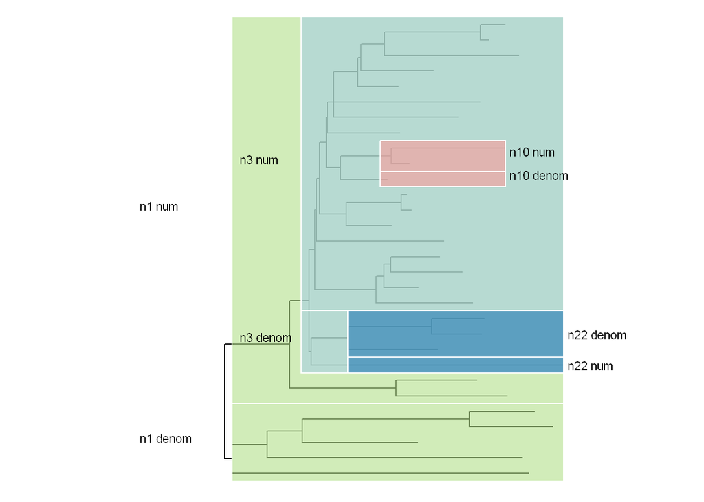

```r
p <- annotate_balance(tr=phy_tree(pseq.filt), coord=top.coords[1],
                 p=p,
                 labels=paste(rep(top.coords[1],2), c("num", "denom")),
                 offset.text=.01,
                 bar=FALSE,
                 hjust=0,
                 vjust=0,
                 size=3) +
  scale_x_continuous(expand = expansion(mult = 0.3))


p <- annotate_balance(tr=phy_tree(pseq.filt), coord=top.coords[2],
                 p=p,
                 labels=paste(rep(top.coords[2],2), c("num", "denom")),
                 offset.text=-1.1,
                 bar=FALSE,
                 hjust=0,
                 vjust=0,
                 size=3)


p <- annotate_balance(tr=phy_tree(pseq.filt), coord=top.coords[3],
                 p=p,
                 labels=paste(rep(top.coords[3],2), c("num", "denom")),
                 offset.text=.01,
                 bar=FALSE,
                 hjust=0,
                 size=3)


p <- annotate_balance(tr=phy_tree(pseq.filt), coord=top.coords[4],
                 p=p,
                 labels=paste(rep(top.coords[4],2), c("num", "denom")),
                 offset.text=-.84,
                 bar=FALSE,
                 hjust=0,
                 vjust=0,
                 size=3)

p
```

```r
#ggsave("figures/diet_t2_PhILR_tree.svg", height=8, width=6)
```

##### Violin plots 2

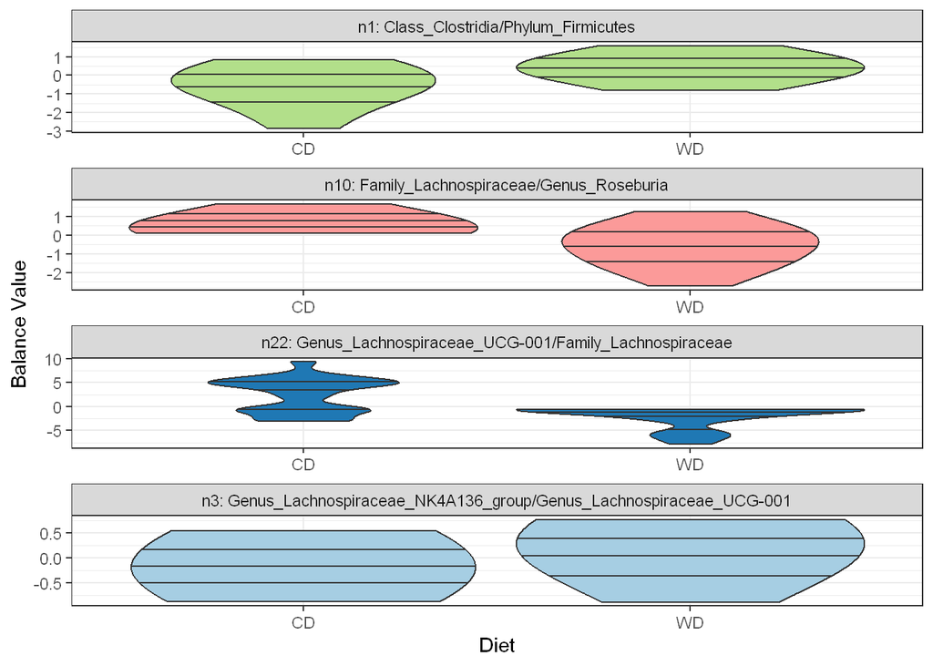

```r
# override for reproducibility
philr.dat <- philr.dat2
pseq.filt <- pseq.filt2
top.coords <- top.coords2
tree <- tree2
tc.names <- tc.names2

philr.long <- convert_to_long(philr.dat,
                              labels=metadata$Diet) %>%
  filter(coord %in% top.coords)

philr.long$coord <- as.factor(philr.long$coord)
philr.long$labels <- as.factor(philr.long$labels)

philr.long$labels <- fct_recode(philr.long$labels,
                                   "CD" = "1",
                                   "WD" = "2")
philr.long$sample <- as.factor(philr.long$sample)

metadata$ID <- rownames(metadata)
philr.long$mouse <- metadata$Mouse[match(philr.long$sample, metadata$ID)]
philr.long$mouse <- as.factor(as.character(philr.long$mouse))

scatter.labels <- paste(names(tc.names), tc.names, sep=": ")
names(scatter.labels) <- names(tc.names)

p2 <- ggplot(philr.long, aes(x=labels, y=value, fill=coord)) +
  geom_violin(draw_quantiles = c(0.25, 0.5, 0.75),
              bw=.9) +
  # geom_bar(color = "black",
  #          stat="summary",
  #          fun = mean,
  #          position=position_dodge(.95)) +
  #geom_jitter()+
  scale_fill_manual(guide="none", values = c('#b2df8a', '#fb9a99', '#1f78b4', '#a6cee3')) +
  facet_wrap(.~coord,
             scales='free', ncol=1,
             labeller=labeller(coord=scatter.labels)) +
  labs(x = 'Diet', y = 'Balance Value') +
 # scale_x_continuous(labels = scales::comma) +
  theme_bw()

p2
```

```r
ggsave("diet_t2_PhILR_violins.svg", height=8, width=6)


# ggarrange(p, p2,
#           labels = c("C", "D"),
#           font.label = list(size = 18),
#           nrow = 1, ncol = 2)


#ggsave("figures/diet_t2_PhILR.svg", height=10, width=14)
```

##### Tree 3

```r
# override for reproducibility
pseq.filt <- pseq.filt3
top.coords <- top.coords3
tree <- tree3

tc.nn <- name.to.nn(phy_tree(pseq.filt), top.coords)

tc.colors <- c('#fb9a99',  '#b2df8a', '#1f78b4', '#a6cee3')


p <- ggtree(tree) +
    geom_balance(node=tc.nn[1], fill=tc.colors[1], alpha=0.6) +
    geom_balance(node=tc.nn[3], fill=tc.colors[3], alpha=0.6) +
    geom_balance(node=tc.nn[2], fill=tc.colors[2], alpha=0.6) +
    geom_balance(node=tc.nn[4], fill=tc.colors[4], alpha=0.6)
```

```
## Found more than one class "phylo" in cache; using the first, from namespace 'phyloseq'
```

```
## Also defined by 'tidytree'
```

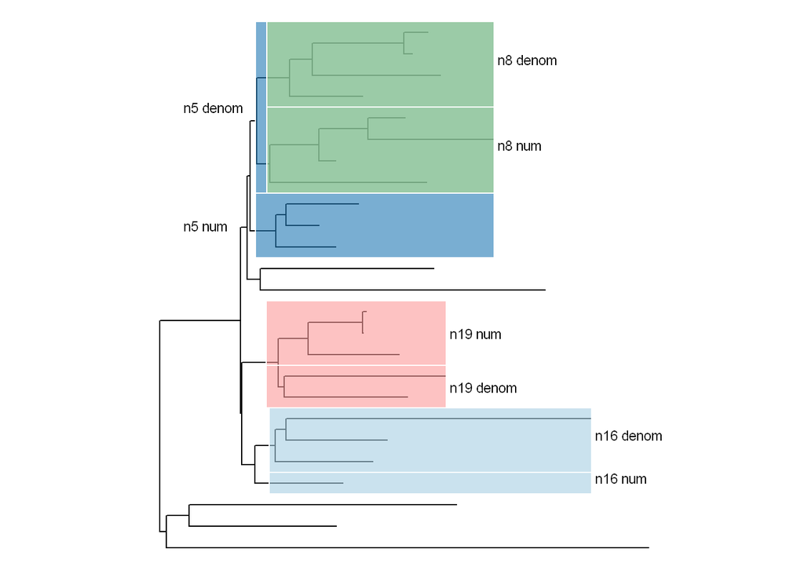

```r
p <- annotate_balance(tr=phy_tree(pseq.filt), coord=top.coords[1],
                 p=p,
                 labels=paste(rep(top.coords[1],2), c("num", "denom")),
                 offset.text=.01,
                 bar=FALSE,
                 hjust=0,
                 size=3) +
  scale_x_continuous(expand = expansion(mult = 0.3))

p <- annotate_balance(tr=phy_tree(pseq.filt), coord=top.coords[2],
                 p=p,
                 labels=paste(rep(top.coords[2],2), c("num", "denom")),
                 offset.text=.01,
                 bar=FALSE,
                 hjust=0,
                 vjust=0,
                 size=3)


p <- annotate_balance(tr=phy_tree(pseq.filt), coord=top.coords[3],
                 p=p,
                 labels=paste(rep(top.coords[3],2), c("num", "denom")),
                 offset.text=-.84,
                 bar=FALSE,
                 hjust=0,
                 size=3)


p <- annotate_balance(tr=phy_tree(pseq.filt), coord=top.coords[4],
                 p=p,
                 labels=paste(rep(top.coords[4],2), c("num", "denom")),
                 offset.text=.01,
                 bar=FALSE,
                 hjust=0,
                 vjust=0,
                 size=3)


p
```

```r
#ggsave("figures/diet_t3_PhILR_tree.svg", height=8, width=6)
```

##### Violin plots 3

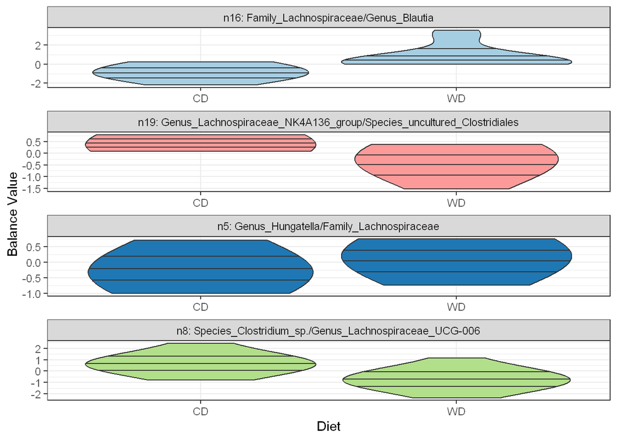

```r
# override for reproducibility
philr.dat <- philr.dat3
pseq.filt <- pseq.filt3
top.coords <- top.coords3
tree <- tree3
tc.names <- tc.names3

philr.long <- convert_to_long(philr.dat,
                              labels=metadata$Diet) %>%
  filter(coord %in% top.coords)

philr.long$coord <- as.factor(philr.long$coord)
philr.long$labels <- as.factor(philr.long$labels)

philr.long$labels <- fct_recode(philr.long$labels,
                                   "CD" = "1",
                                   "WD" = "2")
philr.long$sample <- as.factor(philr.long$sample)

metadata$ID <- rownames(metadata)
philr.long$mouse <- metadata$Mouse[match(philr.long$sample, metadata$ID)]
philr.long$mouse <- as.factor(as.character(philr.long$mouse))

scatter.labels <- paste(names(tc.names), tc.names, sep=": ")
names(scatter.labels) <- names(tc.names)

p2 <- ggplot(philr.long, aes(x=labels, y=value, fill=coord)) +
  geom_violin(draw_quantiles = c(0.25, 0.5, 0.75),
              bw=.9) +
  # geom_bar(color = "black",
  #          stat="summary",
  #          fun = mean,
  #          position=position_dodge(.95)) +
  #geom_jitter()+
  scale_fill_manual(guide="none", values = c('#a6cee3', '#fb9a99', '#1f78b4', '#b2df8a')) +
  facet_wrap(.~coord,
             scales='free', ncol=1,
             labeller=labeller(coord=scatter.labels)) +
  labs(x = 'Diet', y = 'Balance Value') +
 # scale_x_continuous(labels = scales::comma) +
  theme_bw()

p2
```

```r
#ggsave("figures/diet_t3_PhILR_violins.svg", height=8, width=6)


# ggarrange(p, p2,
#           labels = c("E", "F"),
#           font.label = list(size = 18),
#           nrow = 1, ncol = 2)


#ggsave("figures/diet_t3_PhILR.svg", height=10, width=14)
```

##### Tree 4

```r
# override for reproducibility
pseq.filt <- pseq.filt4
top.coords <- top.coords4
tree <- tree4

tc.nn <- name.to.nn(phy_tree(pseq.filt), top.coords)

tc.colors <- c('#fb9a99', '#1f78b4')


p <- ggtree(tree) +
    geom_balance(node=tc.nn[1], fill=tc.colors[1], alpha=0.6) +
    geom_balance(node=tc.nn[2], fill=tc.colors[2], alpha=0.6)
```

```
## Found more than one class "phylo" in cache; using the first, from namespace 'phyloseq'
```

```
## Also defined by 'tidytree'
```

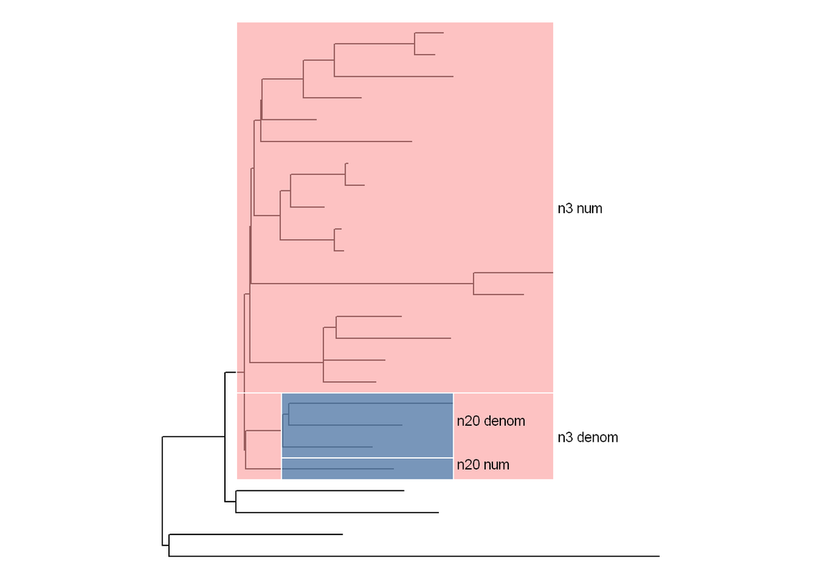

```r
p <- annotate_balance(tr=phy_tree(pseq.filt), coord=top.coords[1],
                 p=p,
                 labels=paste(rep(top.coords[1],2), c("num", "denom")),
                 offset.text=0.01,
                 bar=FALSE,
                 hjust=0,
                 size=3) +
  scale_x_continuous(expand = expansion(mult = 0.3))

p <- annotate_balance(tr=phy_tree(pseq.filt), coord=top.coords[2],
                 p=p,
                 labels=paste(rep(top.coords[2],2), c("num", "denom")),
                 offset.text=.01,
                 bar=FALSE,
                 hjust=0,
                 vjust=0,
                 size=3)

p
```

```r
#ggsave("figures/diet_t4_PhILR_tree.svg", height=8, width=6)
```

##### Violin plots 4

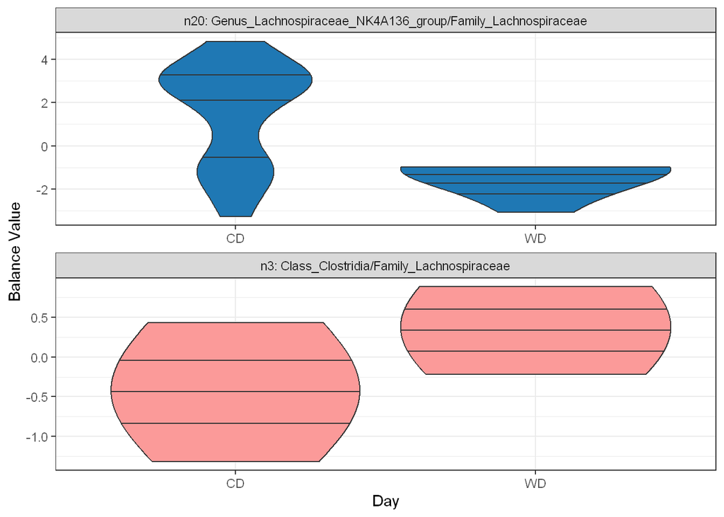

```r
# override for reproducibility
philr.dat <- philr.dat4
pseq.filt <- pseq.filt4
top.coords <- top.coords4
tree <- tree4
tc.names <- tc.names4

philr.long <- convert_to_long(philr.dat,
                              labels=metadata$Diet) %>%
  filter(coord %in% top.coords)

philr.long$coord <- as.factor(philr.long$coord)
philr.long$labels <- as.factor(philr.long$labels)

philr.long$labels <- fct_recode(philr.long$labels,
                                   "CD" = "1",
                                   "WD" = "2")
philr.long$sample <- as.factor(philr.long$sample)

metadata$ID <- rownames(metadata)
philr.long$mouse <- metadata$Mouse[match(philr.long$sample, metadata$ID)]
philr.long$mouse <- as.factor(as.character(philr.long$mouse))

scatter.labels <- paste(names(tc.names), tc.names, sep=": ")
names(scatter.labels) <- names(tc.names)

p2 <- ggplot(philr.long, aes(x=labels, y=value, fill=coord)) +
  geom_violin(draw_quantiles = c(0.25, 0.5, 0.75),
              bw=.9) +
  # geom_bar(color = "black",
  #          stat="summary",
  #          fun = mean,
  #          position=position_dodge(.95)) +
  #geom_jitter()+
  scale_fill_manual(guide="none", values = c('#1f78b4', '#fb9a99')) +
  facet_wrap(.~coord,
             scales='free', ncol=1,
             labeller=labeller(coord=scatter.labels)) +
  labs(x = 'Day', y = 'Balance Value') +
 # scale_x_continuous(labels = scales::comma) +
  theme_bw()

p2
```

```r
#ggsave("figures/diet_t4_PhILR_violins.svg", height=8, width=7)

# ggarrange(p, p2,
#           labels = c("G", "H"),
#           font.label = list(size = 18),
#           nrow = 1, ncol = 2)


#ggsave("figures/diet_t4_PhILR.svg", height=10, width=14)
```